# analisis-preliminar

Kevin Carrasco

26-01-2021

```r
pacman::p_load(stargazer, ggplot2, sjmisc, car, sjlabelled, haven, cowplot,
               sjPlot, summarytools, kableExtra, corrplot, coefplot, ltm, polycor,
               psych, lme4, ppcor, texreg, skimr, gtools, bda, lmerTest, Matrix, sessioninfo, dplyr)

##sessionInfo()
#R version 4.0.2 (2020-06-22)
#Platform: x86_64-w64-mingw32/x64 (64-bit)
#Running under: Windows 10 x64 (build 19042)

#Matrix products: default

#locale:
#[1] LC_COLLATE=Spanish_Chile.1252  LC_CTYPE=Spanish_Chile.1252    LC_MONETARY=Spanish_Chile.1252 LC_NUMERIC=C                   LC_TIME=Spanish_Chile.1252

#attached base packages:
#[1] stats     graphics  grDevices utils     datasets  methods   base

#other attached packages:
#[1] sessioninfo_1.1.1  dplyr_1.0.2        skimr_2.1.2        texreg_1.37.5      ppcor_1.1          lme4_1.1-26        Matrix_1.3-2       psych_2.0.12
#[9] ltm_1.1-1          polycor_0.7-10     msm_1.6.8          MASS_7.3-53        coefplot_1.2.7     corrplot_0.84      kableExtra_1.3.1   summarytools_0.9.8
#[17] sjPlot_2.8.7       cowplot_1.1.1      haven_2.3.1        sjlabelled_1.1.7   car_3.0-10         carData_3.0-4      sjmisc_2.8.6       ggplot2_3.3.3
#[25] stargazer_5.2.2
```

# 1 Cargar base

```r
load("../input/data-proc/data.rda")
```

# 2 Descriptivos

## 2.1 Igualdad de género estudiantes

```r
#Seleccionar variables
est_igualdad=data %>% dplyr::select(Igualdad1.est, Igualdad5.est, Igualdad7.est, Igualdad3.est, Igualdad4.est, Igualdad6.est, Igualdad2.est, Igualdad8.est, Igualdad9.est) %>% as.data.frame()
```

```r
# Cambiar etiquetas
est_igualdad$Igualdad1.est <- set_label(x = est_igualdad$Igualdad1.est, label = "Los hombres y las mujeres deberían tener las mismas oportunidades de participar en el gobierno")
est_igualdad$Igualdad2.est <- set_label(x = est_igualdad$Igualdad2.est, label = "La primera prioridad de las mujeres debería ser criar hijos")
est_igualdad$Igualdad3.est <- set_label(x = est_igualdad$Igualdad3.est, label = "Las mujeres deberían permanecer alejadas de la política")
est_igualdad$Igualdad4.est <- set_label(x = est_igualdad$Igualdad4.est, label = "Cuando no hay muchos trabajos disponibles, los hombres deberían tener más derecho a un trabajo que las mujeres")
est_igualdad$Igualdad5.est <- set_label(x = est_igualdad$Igualdad5.est, label = "Los hombres y las mujeres deberían recibir el mismo pago cuando hacen los mismos trabajos")
est_igualdad$Igualdad6.est <- set_label(x = est_igualdad$Igualdad6.est, label = "Los hombres están mejor preparados para ser líderes políticos que las mujeres")
est_igualdad$Igualdad7.est <- set_label(x = est_igualdad$Igualdad7.est, label = "Los hombres y las mujeres deberían tener los mismos derechos en todos los aspectos")
est_igualdad$Igualdad8.est <- set_label(x = est_igualdad$Igualdad8.est, label = "El rol más importante de una mujer es cuidar su hogar y cocinar para su familia")
est_igualdad$Igualdad9.est <- set_label(x = est_igualdad$Igualdad9.est, label = "Un hombre debe tener la última palabra sobre las decisiones del hogar")
#Crear gráfico

#graf_igualdad_est <- sjPlot::plot_likert(est_igualdad,
 # groups = NULL,
  #groups.titles = "auto",
  #title = "Existen diferentes visiones sobre el papel de las mujeres y los hombres en la sociedad. ¿Cuán de acuerdo o en desacuerdo estás con las siguientes afirmaciones?",
  #legend.title = NULL,
  #legend.labels = c("Muy en desacuerdo", "En desacuerdo", "De acuerdo", "Muy de acuerdo"),
  #axis.titles = NULL,
  #axis.labels = NULL,
  #catcount = 4,
  #cat.neutral = NULL,
  #sort.frq = NULL,
  #weight.by = data$pond_estudiante_reg_dep_tens,
  #title.wtd.suffix = NULL,
  #wrap.title = 55,
  #wrap.labels = 36,
  #geom.size = 0.8,
  #geom.colors ="Purples",
  #reverse.colors = FALSE,
  #values = "sum.outside",
  #show.n = F,
  #show.legend = TRUE,
  #show.prc.sign = T,
  #grid.range = 1.2,
  #grid.breaks = 0.5,
  #expand.grid = FALSE,
  #digits = 0,
  #reverse.scale = TRUE,
  #coord.flip = TRUE,
  #sort.groups = TRUE,
  #rel_heights = 1,
  #group.legend.options = list(nrow = NULL, byrow = TRUE),
  #cowplot.options = list(label_x = 0.01, hjust = 0.5, vjust=0.5, align = "v")) + theme_bw() + theme(plot.title = element_text(size=14, face = "bold", hjust=0.5),
  #                    axis.text.y = element_text(size=10, face = "bold"), legend.position = "bottom", legend.text = element_text(size=10, face="bold"))
#graf_igualdad_est

#Guardar gráfico
#ggsave(graf_igualdad_est, file = "../output/igualdad_de_genero_estudiantes.png",device = "png",width = 21,height = 16,dpi = "retina",units = "cm")
```

## 2.2 Igualdad de género apoderados

```r
#Seleccionar variables
apod_igualdad=data %>% dplyr::select(Igualdad1.pad, Igualdad5.pad, Igualdad7.pad, Igualdad3.pad, Igualdad4.pad, Igualdad6.pad, Igualdad2.pad, Igualdad8.pad, Igualdad9.pad) %>% as.data.frame()
```

```r
# Cambiar etiquetas
apod_igualdad$Igualdad1.pad <- set_label(x = apod_igualdad$Igualdad1.pad, label = "Los hombres y las mujeres deberían tener las mismas oportunidades de participar en el gobierno")
apod_igualdad$Igualdad2.pad <- set_label(x = apod_igualdad$Igualdad2.pad, label = "La primera prioridad de las mujeres debería ser criar hijos")
apod_igualdad$Igualdad3.pad <- set_label(x = apod_igualdad$Igualdad3.pad, label = "Las mujeres deberían permanecer alejadas de la política")
apod_igualdad$Igualdad4.pad <- set_label(x = apod_igualdad$Igualdad4.pad, label = "Cuando no hay muchos trabajos disponibles, los hombres deberían tener más derecho a un trabajo que las mujeres")
apod_igualdad$Igualdad5.pad <- set_label(x = apod_igualdad$Igualdad5.pad, label = "Los hombres y las mujeres deberían recibir el mismo pago cuando hacen los mismos trabajos")
apod_igualdad$Igualdad6.pad <- set_label(x = apod_igualdad$Igualdad6.pad, label = "Los hombres están mejor preparados para ser líderes políticos que las mujeres")
apod_igualdad$Igualdad7.pad <- set_label(x = apod_igualdad$Igualdad7.pad, label = "Los hombres y las mujeres deberían tener los mismos derechos en todos los aspectos")
apod_igualdad$Igualdad8.pad <- set_label(x = apod_igualdad$Igualdad8.pad, label = "El rol más importante de una mujer es cuidar su hogar y cocinar para su familia")
apod_igualdad$Igualdad9.pad <- set_label(x = apod_igualdad$Igualdad9.pad, label = "Un hombre debe tener la última palabra sobre las decisiones del hogar")

# Crear Gráfico
#graf_igualdad_apod <- plot_likert(apod_igualdad,
  #groups = NULL,
  #groups.titles = "auto",
  #title = "Existen diferentes visiones sobre el papel de las mujeres y los hombres en la sociedad. ¿Cuán de acuerdo o en desacuerdo estás con las siguientes afirmaciones?",
  #legend.title = NULL,
  #legend.labels = c("Muy en desacuerdo", "En desacuerdo", "De acuerdo", "Muy de acuerdo"),
  #axis.titles = NULL,
  #axis.labels = NULL,
  #catcount = 4,
  #cat.neutral = NULL,
  #sort.frq = NULL,
  #weight.by = data$pond_apoderado_reg_dep_tens,
  #title.wtd.suffix = NULL,
  #wrap.title = 55,
  #wrap.labels = 36,
  #geom.size = 0.8,
  #geom.colors ="Purples",
  #reverse.colors = FALSE,
  #values = "sum.outside",
  #show.n = F,
  #show.legend = TRUE,
  #show.prc.sign = T,
  #grid.range = 1.2,
  #grid.breaks = 0.5,
  #expand.grid = FALSE,
  #digits = 0,
  #reverse.scale = TRUE,
  #coord.flip = TRUE,
  #sort.groups = TRUE,
  #rel_heights = 1,
  #group.legend.options = list(nrow = NULL, byrow = TRUE),
  #cowplot.options = list(label_x = 0.01, hjust = 0.5, vjust=0.5, align = "v")) + theme_bw() + theme(plot.title = element_text(size=14, face = "bold", hjust=0.5),
  #                    axis.text.y = element_text(size=10, face = "bold"), legend.position = "bottom", legend.text = element_text(size=10, face="bold"))
#graf_igualdad_apod

#Guardar gráfico
#ggsave(graf_igualdad_apod, file = "../output/igualdad_de_genero_apoderados.png",device = "png",width = 21,height = 16,dpi = "retina",units = "cm")
```

## 2.3 Percepción de aula abierta a la discusión estudiantes

```r
#Seleccionar variables
est_apdis=data %>% dplyr::select(Ap_discusion1, Ap_discusion2, Ap_discusion3, Ap_discusion4, Ap_discusion5, Ap_discusion6, Ap_discusion7) %>% as.data.frame()
```

```r
# Cambiar etiquetas
est_apdis$Ap_discusion1 <- set_label(x = est_apdis$Ap_discusion1, label = "Los estudiantes pueden manifestar abiertamente su desacuerdo con sus profesores(as)")
est_apdis$Ap_discusion2 <- set_label(x = est_apdis$Ap_discusion2, label = "Los(as) profesores(as) estimulan a los estudiantes a expresar sus opiniones")
est_apdis$Ap_discusion3 <- set_label(x = est_apdis$Ap_discusion3, label = "Los estudiantes plantean hechos políticos de actualidad para ser discutidos en clases")
est_apdis$Ap_discusion4 <- set_label(x = est_apdis$Ap_discusion4, label = "Los estudiantes expresan sus opiniones en clases, aun cuando sean distintas a las de los demás")
est_apdis$Ap_discusion5 <- set_label(x = est_apdis$Ap_discusion5, label = "Los(as) profesores(as) estimulan a los estudiantes a conversar los temas con gente que opina distinto")
est_apdis$Ap_discusion6 <- set_label(x = est_apdis$Ap_discusion6, label = "Los(as) profesores(as) exponen los temas desde distintos puntos de vista al explicarlos en clases")
est_apdis$Ap_discusion7 <- set_label(x = est_apdis$Ap_discusion7, label = "Los(as) profesores(as) fomentan la reflexión y la crítica")

# Crear Gráfico
#graf_est_apdis <- plot_likert(est_apdis,
  #groups = NULL,
  #groups.titles = "auto",
  #title = "Cuando se discuten temas políticos y sociales durante las clases, ¿Con qué frecuencia suceden las siguientes situaciones?",
  #legend.labels = c("Nunca", "Casi nunca", "A veces", "Siempre"),
  #axis.titles = NULL,
  #axis.labels = NULL,
  #catcount = 4,
  #cat.neutral = NULL,
  #sort.frq = "neg.asc",
  #weight.by = data$pond_estudiante_reg_dep_tens,
  #title.wtd.suffix = NULL,
  #wrap.title = 55,
  #wrap.labels = 36,
  ##wrap.legend.title = 30,
  ##wrap.legend.labels = 13,
  #geom.size = 0.8,
  #geom.colors ="Purples",
  ##cat.neutral.color = "grey70",
  ##intercept.line.color = "grey50",
  #reverse.colors = FALSE,
  #values = "sum.outside",
  #show.n = F,
  #show.legend = TRUE,
  #show.prc.sign = T,
  #grid.range = 1.2,
  #grid.breaks = 0.5,
  #expand.grid = FALSE,
  #digits = 0,
  #reverse.scale = TRUE,
  #coord.flip = TRUE,
  #sort.groups = TRUE,
  #rel_heights = 1,
  #group.legend.options = list(nrow = NULL, byrow = TRUE),
  #cowplot.options = list(label_x = 0.01, hjust = 0.5, vjust=0.5, align = "v")) + theme_bw() + theme(plot.title = element_text(size=14, face = "bold", hjust=0.5),
  #                    axis.text.y = element_text(size=10, face = "bold"), legend.position = "bottom", legend.text = element_text(size=10, face="bold"))
#graf_est_apdis
#ggsave(graf_est_apdis, file = "../output/percepcion_apertura_a_la_discusion_estudiantes.png",device = "png",width = 21,height = 15,dpi = "retina",units = "cm")
```

## 2.4 Otros descriptivos

```r
#view(dfSummary(dplyr::select(data, Sexo, Ed_madre, Ed_padre, Ed_padres, Educacion, Libros_est, Libros_apod_rec), headings=FALSE))

#file="../output/descriptivos recursos de la familia.png"
```

# 3 Correlaciones

## 3.1 Igualdad de género estudiantes

```r
png("../output/cor_indicadores_ig_est.png",width=600,height=600)
corrplot.mixed(cor(dplyr::select(data,Igualdad1.est, Igualdad5.est, Igualdad7.est, Igualdad3.est, Igualdad4.est, Igualdad6.est, Igualdad2.est, Igualdad8.est, Igualdad9.est),
                   use = "na.or.complete", method="spearman"))
dev.off()
```

```r
#png("../output/cor_indicadores_ig_est.png",width=600,height=400)
windowsFonts(A = windowsFont("Times New Roman"))
cormat <- cor(dplyr::select(data,Igualdad1.est, Igualdad5.est, Igualdad7.est, Igualdad3.est, Igualdad4.est, Igualdad6.est, Igualdad2.est, Igualdad8.est, Igualdad9.est), use = "na.or.complete")
```

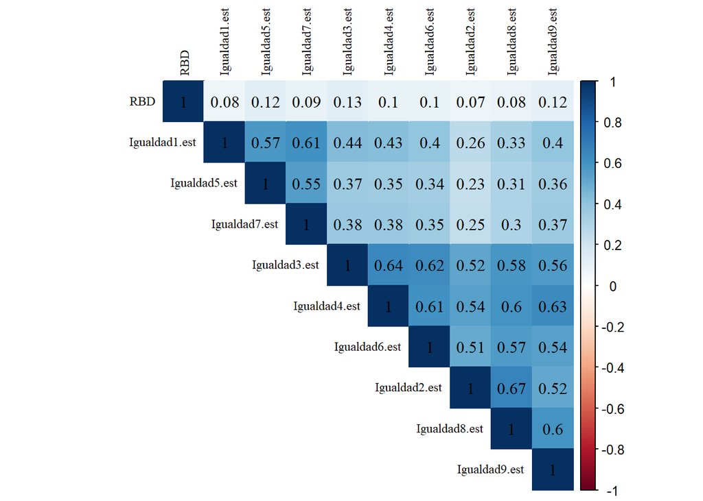

```r
#rownames(cormat) <-c(
 #   "A. Iguales oportunidades de participar en el gobierno",
  #  "B. Hombres y mujeres deberían recibir el mismo pago",
   # "C. Hombres y mujeres deberían tener los mismos derechos",
    #"D. Mujeres deberían permanecer alejadas de la política",
    #"E. Hombres deberían tener más derecho a un trabajo",
    #"F. Hombres están más preparados para ser líderes políticos",
    #"G. Primera prioridad de las mujeres es criar hijos",
    #"H. El rol de una mujer es cuidar su hogar y familia",
    #"I. Hombres deben tener la última palabra sobre el hogar")
#colnames(cormat) <-c("(A)", "(B)","(C)","(D)","(E)", "(F)","(G)","(H)","(I)")
corrplot(
cormat,
  method = "color",
  type = "upper",
  tl.col = "black",
  addCoef.col = "black",
  diag = TRUE,
  family = "A",
  number.font = 6,
  tl.cex =0.75,
  number.cex = 1)
```

## Correlaciones puntuaciones factoriales estudiantes

```r
png("../output/cor_punt_fact_ig_est.png",width=600,height=600)
corrplot.mixed(cor(dplyr::select(data, igualdad.est, esp_publico.est, esp_privado.est),
                   use = "na.or.complete"))
dev.off()
```

```r
windowsFonts(A = windowsFont("Times New Roman"))
cormat <- cor(dplyr::select(data, igualdad.est, esp_publico.est, esp_privado.est),
                   use = "na.or.complete")
```

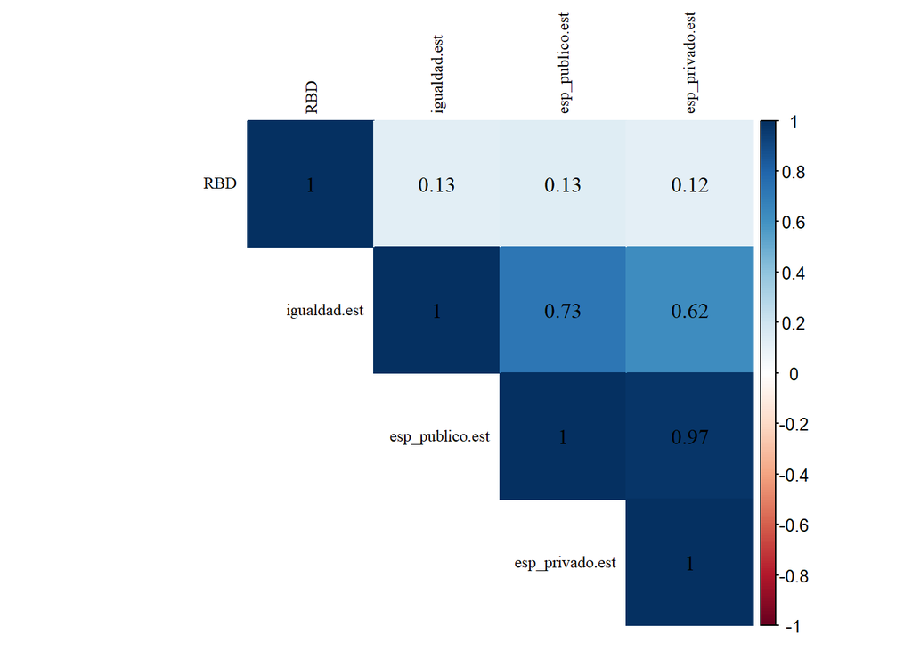

```r
#rownames(cormat) <-c(
 #   "A. Igualdad de derechos en general",
  #  "B. Supremacía masculina en el espacio publico",
   # "C. Supremacía masculina en el espacio privado")
#colnames(cormat) <-c("(A)", "(B)","(C)")
corrplot(
cormat,
  method = "color",
  type = "upper",
  tl.col = "black",
  addCoef.col = "black",
  diag = TRUE,
  family = "A",
  number.font = 6,
  tl.cex =0.75,
  number.cex = 1)
```

## Igualdad de género apoderados

```r
png("../output/cor_indicadores_ig_apod.png",width=600,height=600)
corrplot.mixed(cor(dplyr::select(data,Igualdad1.pad, Igualdad5.pad, Igualdad7.pad, Igualdad3.pad, Igualdad4.pad, Igualdad6.pad, Igualdad2.pad, Igualdad8.pad, Igualdad9.pad),
                   use = "na.or.complete", method="spearman"))
dev.off()
```

## 3.2 Correlaciones puntuaciones factoriales apoderados

```r
png("../output/cor_punt_fact_ig_apod.png",width=600,height=600)
corrplot.mixed(cor(dplyr::select(data, igualdad.pad, esp_publico.pad, esp_privado.pad),
                   use = "na.or.complete"))
dev.off()
```

## 3.3 Libros (estudiantes y apoderados)

```r
png("../output/cor_libros_est_apod.png",width=600,height=600)
corrplot.mixed(cor(dplyr::select(data, Libros_est, Libros_apod_rec, Libros),
                   use = "na.or.complete", method="spearman"))
dev.off()
```

## 3.4 Educación padres (estudiantes y apoderados) con corrplot spearman

```r
png("../output/cor_ed_pad.png",width=600,height=600)

corrplot.mixed(cor(dplyr::select(data, Ed_padre, Ed_padres, Educacion, Educ_padre),
                   use = "na.or.complete", method="spearman"))
dev.off()
```

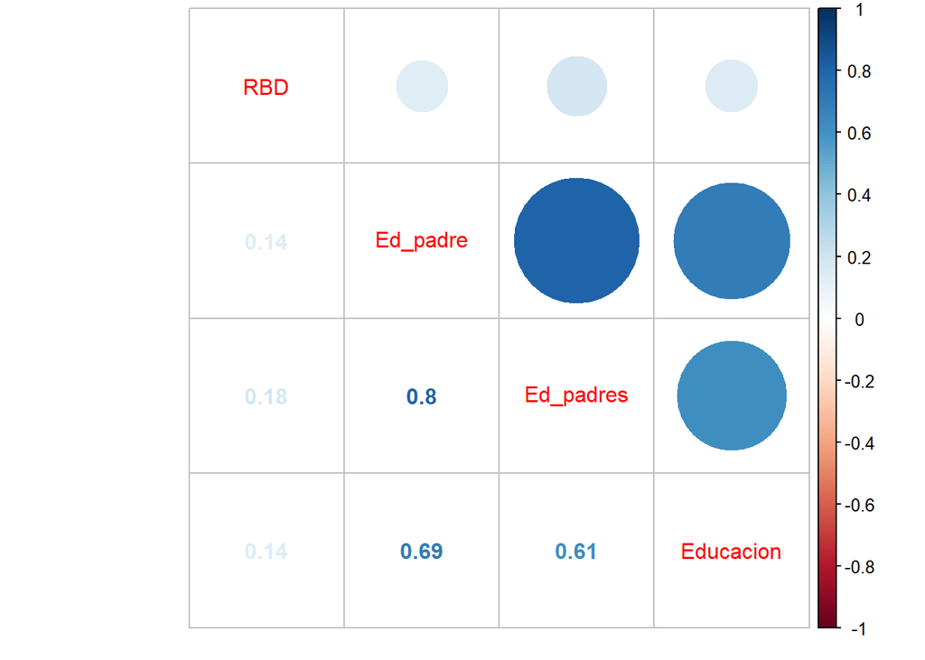

```r
cor1 <- corrplot.mixed(cor(dplyr::select(data, Ed_padre, Ed_padres, Educacion),
                   use = "na.or.complete", method="spearman"))
```

```r
png("../output/cor_ed_mad.png",width=600,height=600)

corrplot.mixed(cor(dplyr::select(data,Ed_madre, Ed_padres, Educacion, Educ_madre),
                   use = "na.or.complete", method="spearman"))
dev.off()
```

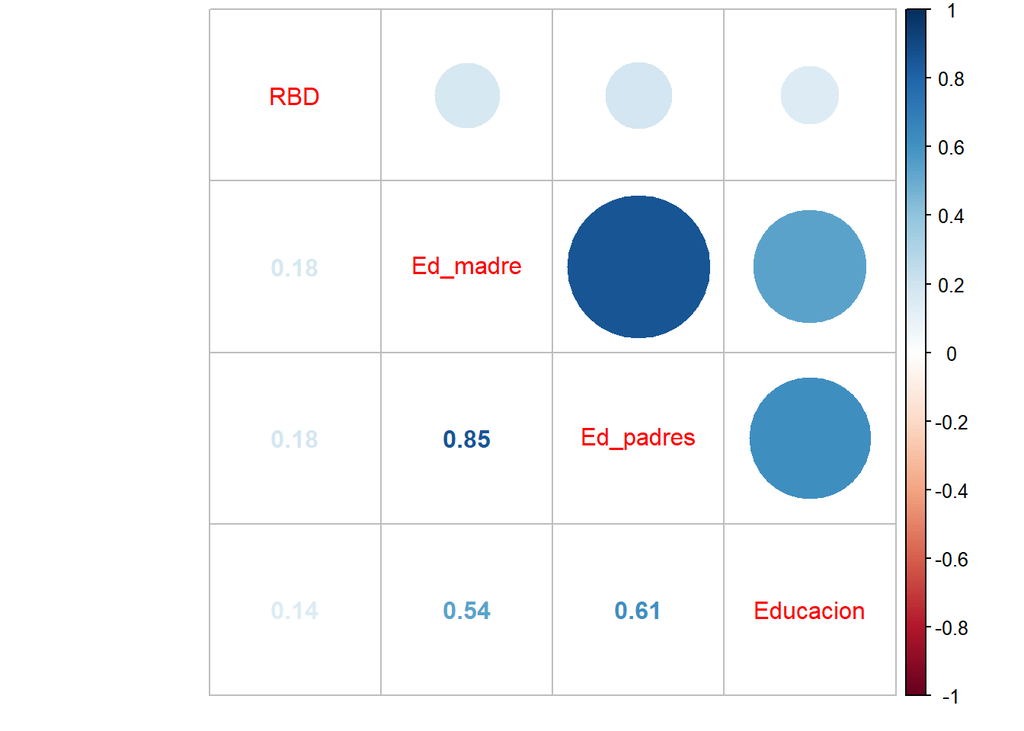

```r
cor2 <- corrplot.mixed(cor(dplyr::select(data,Ed_madre, Ed_padres, Educacion),
                   use = "na.or.complete", method="spearman"))
```

## 3.5 Educación padres (estudiantes y apoderados) con polychoric de psych

```r
educ=data %>% dplyr::select("Educ. madre"=Ed_madre, "Educ. padre"=Ed_padre, "Educ padres"=Ed_padres, "Educación padres"=Educacion) %>% as.data.frame()
#polychoric(educ,smooth=TRUE,global=TRUE,polycor=FALSE, ML = FALSE,
 #      std.err=FALSE,weight=NULL,progress=TRUE,na.rm=TRUE, delete=TRUE)
```

## 3.6 Igualdad de género y sexo

```r
# level = 2 es la categoría a utilizar, en este caso mujer (2)
biserial.cor(data$igualdad.est,data$Sexo, use = c("complete.obs"), level = 2)
```

```
## [1] 0.1641111
```

```r
biserial.cor(data$esp_publico.est,data$Sexo, use = c("complete.obs"), level = 2)
```

```
## [1] 0.2073043
```

```r
biserial.cor(data$esp_privado.est,data$Sexo, use = c("complete.obs"), level = 2)
```

```
## [1] 0.2097127
```

## 3.7 Tabla correlaciones biseriales igualdad de género y sexo

[output not shown]

## 3.8 Igualdad de género estudiantes y recursos de la familia

```r
png("../output/cor_ig_est_recursos.png",width=600,height=600)
corrplot.mixed(cor(dplyr::select(data, igualdad.est, esp_publico.est, esp_privado.est, Educ_padre, Educ_madre, Libros, ingresos_tramos),
                   use = "na.or.complete"))
dev.off()
```

## 3.9 Igualdad de género estudiantes y apoderados (puntuaciones factoriales)

```r
png("../output/cor_fact_ig_est_apod.png",width=600,height=600)
corrplot.mixed(cor(dplyr::select(data, igualdad.est, esp_publico.est, esp_privado.est, igualdad.pad, esp_publico.pad, esp_privado.pad),
                   use = "na.or.complete"))
dev.off()
```

## 3.10 Igualdad de género apoderados y recursos de la familia

```r
png("../output/cor_ig_apod_recursos.png",width=600,height=600)
corrplot.mixed(cor(dplyr::select(data, igualdad.pad, esp_publico.pad, esp_privado.pad, Educ_padre, Educ_madre, Libros, ingresos_tramos),
                   use = "na.or.complete"))
dev.off()
```

## 3.11 Correlación parcial entre igualdad de género estudiantes, apoderados y recursos de la familia

```r
#Primero correlación directa
cor(dplyr::select(data, igualdad.est, Educacion), use = "na.or.complete")
```

```
##                    RBD igualdad.est  Educacion
## RBD          1.0000000   0.18009347 0.12659141
## igualdad.est 0.1800935   1.00000000 0.09900507
## Educacion    0.1265914   0.09900507 1.00000000
```

```r
# después correlación parcializada
partial.r(data=data, x=c("igualdad.est","Educacion"), y="igualdad.pad")
```

```
## partial correlations
##              igualdad.est Educacion
## igualdad.est         1.00      0.07
## Educacion            0.07      1.00
```

## 3.12 Igualdad de género estudiantes, Apertura a la discusion en el aula Y proporción de niñas

```r
png("../output/cor_ig_est_escuela.png",width=600,height=600)
corrplot.mixed(cor(dplyr::select(data, igualdad.est, esp_publico.est, esp_privado.est, ap_discusion, mean_discusion, num_fem),
                   use = "na.or.complete"))
dev.off()
```

# 4 Modelos de regresión: Base de datos con todos los casos

```r
#data %>% group_by(Sexo) %>% skim(igualdad.est)
```

## 4.1 Modelo nulo

```r
data$RBD <- as.factor(data$RBD)

reg0_igualdad <- lme4::lmer(igualdad.est ~ 1 + (1 | RBD), data=data)
reg0_pub <- lme4::lmer(esp_publico.est ~ 1 + (1 | RBD), data=data)
reg0_priv <- lme4::lmer(esp_privado.est ~ 1 + (1 | RBD), data=data)

stargazer::stargazer(reg0_igualdad, reg0_pub, reg0_priv,
  column.labels=c("Igualdad","Espacio público", "Espacio privado"),
  type ='text')
```

```
##
## ================================================================
##                                 Dependent variable:
##                     --------------------------------------------
##                     igualdad.est esp_publico.est esp_privado.est
##                       Igualdad   Espacio público Espacio privado
##                         (1)            (2)             (3)
## ----------------------------------------------------------------
## Constant               -0.028        -0.030          -0.031
##                       (0.028)        (0.033)         (0.037)
##
## ----------------------------------------------------------------
## Observations           1,615          1,615           1,615
## Log Likelihood       -1,053.727    -1,183.792      -1,412.776
## Akaike Inf. Crit.    2,113.454      2,373.585       2,831.552
## Bayesian Inf. Crit.  2,129.615      2,389.746       2,847.714
## ================================================================
## Note:                                *p<0.1; **p<0.05; ***p<0.01
```

```r
screenreg(list(reg0_igualdad, reg0_pub, reg0_priv))
```

```
##
## =====================================================
##                       Model 1    Model 2    Model 3
## -----------------------------------------------------
## (Intercept)              -0.03      -0.03      -0.03
##                          (0.03)     (0.03)     (0.04)
## -----------------------------------------------------
## AIC                    2113.45    2373.58    2831.55
## BIC                    2129.62    2389.75    2847.71
## Log Likelihood        -1053.73   -1183.79   -1412.78
## Num. obs.              1615       1615       1615
## Num. groups: RBD         64         64         64
## Var: RBD (Intercept)      0.04       0.06       0.07
## Var: Residual             0.20       0.23       0.31
## =====================================================
## *** p < 0.001; ** p < 0.01; * p < 0.05
```

```r
htmlreg(list(reg0_igualdad,reg0_pub, reg0_priv), custom.model.names = c("Actitudes del estudiante hacia <br> la igualdad de derechos <br> y oportunidades", "Actitudes del estudiante hacia <br> la distribución igualitaria de<br> roles en la esfera pública", "Actitudes del estudiante hacia <br> la distribución igualitaria de<br> roles en la esfera privada"), custom.note = "$***p <$ 0.001, $**p <$ 0.01, $*p <$ 0.05",  custom.coef.names = c("Intercepto"))
```

Statistical models

|  | Actitudes del estudiante hacia la igualdad de derechos y oportunidades | Actitudes del estudiante hacia la distribución igualitaria de roles en la esfera pública | Actitudes del estudiante hacia la distribución igualitaria de roles en la esfera privada |
| --- | --- | --- | --- |
| Intercepto | -0.03 | -0.03 | -0.03 |
|  | (0.03) | (0.03) | (0.04) |
| AIC | 2113.45 | 2373.58 | 2831.55 |
| BIC | 2129.62 | 2389.75 | 2847.71 |
| Log Likelihood | -1053.73 | -1183.79 | -1412.78 |
| Num. obs. | 1615 | 1615 | 1615 |
| Num. groups: RBD | 64 | 64 | 64 |
| Var: RBD (Intercept) | 0.04 | 0.06 | 0.07 |
| Var: Residual | 0.20 | 0.23 | 0.31 |

$***p <$ 0.001, $**p <$ 0.01, $*p <$ 0.05

### 4.1.1 Correlación intra-clase

```r
reghelper::ICC(reg0_igualdad)
```

```
## [1] 0.1652323
```

```r
reghelper::ICC(reg0_pub)
```

```
## [1] 0.2013641
```

```r
reghelper::ICC(reg0_priv)
```

```
## [1] 0.1882528
```

## 4.2 Modelos de regresión

```r
reg_igualdad <- lmer(igualdad.est ~ 1 + Sexo + factor(Educacion) + factor(Libros_apod_rec) + factor(quintiles_ingresos_pc_factor) + igualdad.pad + ap_discusion + mean_discusion + num_fem + factor(dependencia) + factor(REGION) + c_civic + (1 | RBD), data=data)
reg_esp.pub <- lmer(esp_publico.est ~ 1 + Sexo + factor(Educacion) + factor(Libros_apod_rec) + factor(quintiles_ingresos_pc_factor) + esp_publico.pad + ap_discusion + mean_discusion + num_fem + factor(dependencia) + factor(REGION) + c_civic + (1 | RBD), data=data)
reg_esp.priv <- lmer(esp_privado.est ~ 1 + Sexo + factor(Educacion) + factor(Libros_apod_rec) + factor(quintiles_ingresos_pc_factor) + esp_privado.pad + ap_discusion + mean_discusion + num_fem + factor(dependencia) + factor(REGION) + c_civic + (1 | RBD), data=data)
screenreg(list(reg_igualdad,reg_esp.pub,reg_esp.priv))
```

```
##
## ====================================================================================
##                                                Model 1      Model 2      Model 3
## ------------------------------------------------------------------------------------
## (Intercept)                                      -0.41 ***    -0.74 ***    -0.80 ***
##                                                  (0.10)       (0.11)       (0.13)
## Sexo                                              0.08 *       0.15 ***     0.17 ***
##                                                  (0.03)       (0.04)       (0.04)
## factor(Educacion)2                               -0.01        -0.02        -0.03
##                                                  (0.05)       (0.06)       (0.07)
## factor(Educacion)3                               -0.00        -0.03        -0.04
##                                                  (0.05)       (0.07)       (0.07)
## factor(Educacion)4                                0.00         0.01         0.01
##                                                  (0.06)       (0.08)       (0.09)
## factor(Libros_apod_rec)2                          0.10 *       0.05         0.03
##                                                  (0.04)       (0.05)       (0.06)
## factor(Libros_apod_rec)3                          0.05         0.05         0.05
##                                                  (0.04)       (0.05)       (0.06)
## factor(Libros_apod_rec)4                          0.04         0.04         0.05
##                                                  (0.05)       (0.06)       (0.07)
## factor(quintiles_ingresos_pc_factor)Quintil 2     0.07         0.14 *       0.17 *
##                                                  (0.05)       (0.06)       (0.07)
## factor(quintiles_ingresos_pc_factor)Quintil 3     0.10 *       0.14 *       0.18 **
##                                                  (0.05)       (0.06)       (0.07)
## factor(quintiles_ingresos_pc_factor)Quintil 4     0.03         0.11         0.15 *
##                                                  (0.05)       (0.06)       (0.07)
## factor(quintiles_ingresos_pc_factor)Quintil 5     0.09         0.11         0.14
##                                                  (0.06)       (0.07)       (0.08)
## factor(quintiles_ingresos_pc_factor)Ns/Nr         0.09         0.13 *       0.13
##                                                  (0.05)       (0.06)       (0.07)
## igualdad.pad                                      0.09 *
##                                                  (0.04)
## ap_discusion                                      0.12 ***     0.07 *       0.06
##                                                  (0.03)       (0.03)       (0.03)
## mean_discusion                                    0.36 ***     0.36 ***     0.39 ***
##                                                  (0.08)       (0.09)       (0.10)
## num_fem                                           0.04        -0.04        -0.03
##                                                  (0.11)       (0.12)       (0.13)
## factor(dependencia)2                              0.09         0.08         0.04
##                                                  (0.05)       (0.05)       (0.06)
## factor(dependencia)3                             -0.02         0.02        -0.01
##                                                  (0.07)       (0.08)       (0.09)
## factor(REGION)7                                  -0.01         0.02         0.03
##                                                  (0.07)       (0.07)       (0.08)
## factor(REGION)13                                  0.02         0.08         0.09
##                                                  (0.06)       (0.06)       (0.07)
## c_civic                                           0.03 ***     0.07 ***     0.07 ***
##                                                  (0.01)       (0.01)       (0.01)
## esp_publico.pad                                                0.16 ***
##                                                               (0.04)
## esp_privado.pad                                                             0.25 ***
##                                                                            (0.05)
## ------------------------------------------------------------------------------------
## AIC                                             589.55       797.84       957.98
## BIC                                             696.14       904.43      1064.57
## Log Likelihood                                 -270.78      -374.92      -454.99
## Num. obs.                                       627          627          627
## Num. groups: RBD                                 60           60           60
## Var: RBD (Intercept)                              0.01         0.01         0.01
## Var: Residual                                     0.12         0.16         0.22
## ====================================================================================
## *** p < 0.001; ** p < 0.01; * p < 0.05
```

### 4.2.1 H1: Las niñas presentarán actitudes más positivas hacia la igualdad de género que los niños.

```r
htmlreg(list(reg_igualdad,reg_esp.pub,reg_esp.priv), custom.model.names = c("Actitudes del estudiante hacia <br> la igualdad de derechos <br> y oportunidades", "Actitudes del estudiante hacia <br> la distribución igualitaria de<br> roles en la esfera pública", "Actitudes del estudiante hacia <br> la distribución igualitaria de<br> roles en la esfera privada"), omit.coef = "(Educacion)|(Libros_apod_rec)|(quintiles_ingresos_pc_factor)|(igualdad.pad)|(esp_publico.pad)|(esp_privado.pad)|(ap_discusion)|(mean_discusion)|(num_fem)|(dependencia)|(REGION)|(c_civic)", custom.note = "$***p <$ 0.001, $**p <$ 0.01, $*p <$ 0.05 <br> Todos los modelos están controlados por el resto de las variables analizadas, la dependencia administrativa de la escuela, la región y el nivel de conocimiento cívico del estudiante.",  custom.coef.names = c("Intercepto", "Sexo <i>(Ref. Niño)</i>"))
```

Statistical models

|  | Actitudes del estudiante hacia la igualdad de derechos y oportunidades | Actitudes del estudiante hacia la distribución igualitaria de roles en la esfera pública | Actitudes del estudiante hacia la distribución igualitaria de roles en la esfera privada |
| --- | --- | --- | --- |
| Intercepto | -0.41*** | -0.74*** | -0.80*** |
|  | (0.10) | (0.11) | (0.13) |
| Sexo *(Ref. Niño)* | 0.08* | 0.15*** | 0.17*** |
|  | (0.03) | (0.04) | (0.04) |
| AIC | 589.55 | 797.84 | 957.98 |
| BIC | 696.14 | 904.43 | 1064.57 |
| Log Likelihood | -270.78 | -374.92 | -454.99 |
| Num. obs. | 627 | 627 | 627 |
| Num. groups: RBD | 60 | 60 | 60 |
| Var: RBD (Intercept) | 0.01 | 0.01 | 0.01 |
| Var: Residual | 0.12 | 0.16 | 0.22 |

$***p <$ 0.001, $**p <$ 0.01, $*p <$ 0.05 Todos los modelos están controlados por el resto de las variables analizadas, la dependencia administrativa de la escuela, la región y el nivel de conocimiento cívico del estudiante.

### 4.2.2 H2: Estudiantes que provienen de familias con mayores recursos socioeconómicos presentarán actitudes más positivas hacia la igualdad de género.

#### 4.2.2.1 Educación

```r
htmlreg(list(reg_igualdad,reg_esp.pub,reg_esp.priv), custom.model.names = c("Actitudes del estudiante hacia <br> la igualdad de derechos <br> y oportunidades", "Actitudes del estudiante hacia <br> la distribución igualitaria de<br> roles en la esfera pública", "Actitudes del estudiante hacia <br> la distribución igualitaria de<br> roles en la esfera privada"), omit.coef = "(Sexo)|(Libros_apod_rec)|(quintiles_ingresos_pc_factor)|(igualdad.pad)|(esp_publico.pad)|(esp_privado.pad)|(ap_discusion)|(mean_discusion)|(num_fem)|(dependencia)|(REGION)|(c_civic)", custom.note = "$***p <$ 0.001, $**p <$ 0.01, $*p <$ 0.05 <br> Todos los modelos están controlados por el resto de las variables analizadas, la dependencia administrativa de la escuela, la región y el nivel de conocimiento cívico del estudiante.",  custom.coef.names = c("Intercepto", "Educación Media <br> <i>(Ref. 8vo básico o menos)</i>", "Educación Técnica Superior (IP o CFT)", "Una carrera en la Universidad o <br> estudios de Posgrado"))
```

Statistical models

|  | Actitudes del estudiante hacia la igualdad de derechos y oportunidades | Actitudes del estudiante hacia la distribución igualitaria de roles en la esfera pública | Actitudes del estudiante hacia la distribución igualitaria de roles en la esfera privada |
| --- | --- | --- | --- |
| Intercepto | -0.41*** | -0.74*** | -0.80*** |
|  | (0.10) | (0.11) | (0.13) |
| Educación Media *(Ref. 8vo básico o menos)* | -0.01 | -0.02 | -0.03 |
|  | (0.05) | (0.06) | (0.07) |
| Educación Técnica Superior (IP o CFT) | -0.00 | -0.03 | -0.04 |
|  | (0.05) | (0.07) | (0.07) |
| Una carrera en la Universidad o estudios de Posgrado | 0.00 | 0.01 | 0.01 |
|  | (0.06) | (0.08) | (0.09) |
| AIC | 589.55 | 797.84 | 957.98 |
| BIC | 696.14 | 904.43 | 1064.57 |
| Log Likelihood | -270.78 | -374.92 | -454.99 |
| Num. obs. | 627 | 627 | 627 |
| Num. groups: RBD | 60 | 60 | 60 |
| Var: RBD (Intercept) | 0.01 | 0.01 | 0.01 |
| Var: Residual | 0.12 | 0.16 | 0.22 |

$***p <$ 0.001, $**p <$ 0.01, $*p <$ 0.05 Todos los modelos están controlados por el resto de las variables analizadas, la dependencia administrativa de la escuela, la región y el nivel de conocimiento cívico del estudiante.

#### 4.2.2.2 Cantidad de libros en el hogar

```r
htmlreg(list(reg_igualdad,reg_esp.pub,reg_esp.priv), custom.model.names = c("Actitudes del estudiante hacia <br> la igualdad de derechos <br> y oportunidades", "Actitudes del estudiante hacia <br> la distribución igualitaria de<br> roles en la esfera pública", "Actitudes del estudiante hacia <br> la distribución igualitaria de<br> roles en la esfera privada"), omit.coef = "(Sexo)|(Educacion)|(quintiles_ingresos_pc_factor)|(igualdad.pad)|(esp_publico.pad)|(esp_privado.pad)|(ap_discusion)|(mean_discusion)|(num_fem)|(dependencia)|(REGION)|(c_civic)", custom.note = "$***p <$ 0.001, $**p <$ 0.01, $*p <$ 0.05 <br> Todos los modelos están controlados por el resto de las variables analizadas, la dependencia administrativa de la escuela, la región y el nivel de conocimiento cívico del estudiante.",  custom.coef.names = c("Intercepto", "Entre 11 y 25 libros <br> <i>(Ref. Entre 0 y 10 libros)</i>", "Entre 26 y 100 libros", "Más de 100 libros"))
```

Statistical models

|  | Actitudes del estudiante hacia la igualdad de derechos y oportunidades | Actitudes del estudiante hacia la distribución igualitaria de roles en la esfera pública | Actitudes del estudiante hacia la distribución igualitaria de roles en la esfera privada |
| --- | --- | --- | --- |
| Intercepto | -0.41*** | -0.74*** | -0.80*** |
|  | (0.10) | (0.11) | (0.13) |
| Entre 11 y 25 libros *(Ref. Entre 0 y 10 libros)* | 0.10* | 0.05 | 0.03 |
|  | (0.04) | (0.05) | (0.06) |
| Entre 26 y 100 libros | 0.05 | 0.05 | 0.05 |
|  | (0.04) | (0.05) | (0.06) |
| Más de 100 libros | 0.04 | 0.04 | 0.05 |
|  | (0.05) | (0.06) | (0.07) |
| AIC | 589.55 | 797.84 | 957.98 |
| BIC | 696.14 | 904.43 | 1064.57 |
| Log Likelihood | -270.78 | -374.92 | -454.99 |
| Num. obs. | 627 | 627 | 627 |
| Num. groups: RBD | 60 | 60 | 60 |
| Var: RBD (Intercept) | 0.01 | 0.01 | 0.01 |
| Var: Residual | 0.12 | 0.16 | 0.22 |

$***p <$ 0.001, $**p <$ 0.01, $*p <$ 0.05 Todos los modelos están controlados por el resto de las variables analizadas, la dependencia administrativa de la escuela, la región y el nivel de conocimiento cívico del estudiante.

#### 4.2.2.3 Ingresos

```r
htmlreg(list(reg_igualdad,reg_esp.pub,reg_esp.priv), custom.model.names = c("Actitudes del estudiante hacia <br> la igualdad de derechos <br> y oportunidades", "Actitudes del estudiante hacia <br> la distribución igualitaria de<br> roles en la esfera pública", "Actitudes del estudiante hacia <br> la distribución igualitaria de<br> roles en la esfera privada"), omit.coef = "(Sexo)|(Educacion)|(Libros_apod_rec)|(igualdad.pad)|(esp_publico.pad)|(esp_privado.pad)|(ap_discusion)|(mean_discusion)|(num_fem)|(dependencia)|(REGION)|(c_civic)", custom.note = "$***p <$ 0.001, $**p <$ 0.01, $*p <$ 0.05 <br> Todos los modelos están controlados por el resto de las variables analizadas, la dependencia administrativa de la escuela, la región y el nivel de conocimiento cívico del estudiante.",  custom.coef.names = c("Intercepto", "Quintil 2 <br> <i>(Ref. Quintil 1)</i>", "Quintil 3", "Quintil 4", "Quintil 5", "No sabe / No responde"))
```

Statistical models

|  | Actitudes del estudiante hacia la igualdad de derechos y oportunidades | Actitudes del estudiante hacia la distribución igualitaria de roles en la esfera pública | Actitudes del estudiante hacia la distribución igualitaria de roles en la esfera privada |
| --- | --- | --- | --- |
| Intercepto | -0.41*** | -0.74*** | -0.80*** |
|  | (0.10) | (0.11) | (0.13) |
| Quintil 2 *(Ref. Quintil 1)* | 0.07 | 0.14* | 0.17* |
|  | (0.05) | (0.06) | (0.07) |
| Quintil 3 | 0.10* | 0.14* | 0.18** |
|  | (0.05) | (0.06) | (0.07) |
| Quintil 4 | 0.03 | 0.11 | 0.15* |
|  | (0.05) | (0.06) | (0.07) |
| Quintil 5 | 0.09 | 0.11 | 0.14 |
|  | (0.06) | (0.07) | (0.08) |
| No sabe / No responde | 0.09 | 0.13* | 0.13 |
|  | (0.05) | (0.06) | (0.07) |
| AIC | 589.55 | 797.84 | 957.98 |
| BIC | 696.14 | 904.43 | 1064.57 |
| Log Likelihood | -270.78 | -374.92 | -454.99 |
| Num. obs. | 627 | 627 | 627 |
| Num. groups: RBD | 60 | 60 | 60 |
| Var: RBD (Intercept) | 0.01 | 0.01 | 0.01 |
| Var: Residual | 0.12 | 0.16 | 0.22 |

$***p <$ 0.001, $**p <$ 0.01, $*p <$ 0.05 Todos los modelos están controlados por el resto de las variables analizadas, la dependencia administrativa de la escuela, la región y el nivel de conocimiento cívico del estudiante.

## 4.3 H3: Estudiantes con apoderados que poseen actitudes más positivas hacia la igualdad de género presentarán actitudes más positivas hacia la igualdad de género.

```r
htmlreg(list(reg_igualdad,reg_esp.pub,reg_esp.priv), custom.model.names = c("Actitudes del estudiante hacia <br> la igualdad de derechos <br> y oportunidades", "Actitudes del estudiante hacia <br> la distribución igualitaria de<br> roles en la esfera pública", "Actitudes del estudiante hacia <br> la distribución igualitaria de<br> roles en la esfera privada"), omit.coef = "(Sexo)|(Educacion)|(Libros_apod_rec)|(quintiles_ingresos_pc_factor)|(ap_discusion)|(mean_discusion)|(num_fem)|(dependencia)|(REGION)|(c_civic)", custom.note = "$***p <$ 0.001, $**p <$ 0.01, $*p <$ 0.05 <br> Todos los modelos están controlados por el resto de las variables analizadas, la dependencia administrativa de la escuela, la región y el nivel de conocimiento cívico del estudiante.",  custom.coef.names = c("Intercepto", "Actitudes del apoderado hacia <br> la igualdad de derechos <br> y oportunidades", "Actitudes del apoderado hacia <br> la distribución igualitaria de<br> roles en la esfera pública", "Actitudes del apoderado hacia <br> la distribución igualitaria de<br> roles en la esfera privada"))
```

Statistical models

|  | Actitudes del estudiante hacia la igualdad de derechos y oportunidades | Actitudes del estudiante hacia la distribución igualitaria de roles en la esfera pública | Actitudes del estudiante hacia la distribución igualitaria de roles en la esfera privada |
| --- | --- | --- | --- |
| Intercepto | -0.41*** | -0.74*** | -0.80*** |
|  | (0.10) | (0.11) | (0.13) |
| Actitudes del apoderado hacia la igualdad de derechos y oportunidades | 0.09* |  |  |
|  | (0.04) |  |  |
| Actitudes del apoderado hacia la distribución igualitaria de roles en la esfera pública |  | 0.16*** |  |
|  |  | (0.04) |  |
| Actitudes del apoderado hacia la distribución igualitaria de roles en la esfera privada |  |  | 0.25*** |
|  |  |  | (0.05) |
| AIC | 589.55 | 797.84 | 957.98 |
| BIC | 696.14 | 904.43 | 1064.57 |
| Log Likelihood | -270.78 | -374.92 | -454.99 |
| Num. obs. | 627 | 627 | 627 |
| Num. groups: RBD | 60 | 60 | 60 |
| Var: RBD (Intercept) | 0.01 | 0.01 | 0.01 |
| Var: Residual | 0.12 | 0.16 | 0.22 |

$***p <$ 0.001, $**p <$ 0.01, $*p <$ 0.05 Todos los modelos están controlados por el resto de las variables analizadas, la dependencia administrativa de la escuela, la región y el nivel de conocimiento cívico del estudiante.

## 4.4 H4: Apoderados con mayores recursos socioeconómicos presentarán actitudes más positivas hacia la igualdad de género.

```r
h4_igualdad.apod <- lmer(igualdad.pad ~ 1 + factor(Educacion) + factor(Libros_apod_rec) + factor(quintiles_ingresos_pc_factor) + factor(REGION) + (1 | RBD), data=data)
h4_esp_pub.apod <- lmer(esp_publico.pad ~ 1 + factor(Educacion) + factor(Libros_apod_rec) + factor(quintiles_ingresos_pc_factor) + factor(REGION) + (1 | RBD), data=data)
h4_esp_priv.apod <- lmer(esp_privado.pad ~ 1 + factor(Educacion) + factor(Libros_apod_rec) + factor(quintiles_ingresos_pc_factor) + factor(REGION) + (1 | RBD), data=data)
screenreg(list(h4_igualdad.apod,h4_esp_pub.apod,h4_esp_priv.apod))
```

```
##
## ====================================================================================
##                                                Model 1      Model 2      Model 3
## ------------------------------------------------------------------------------------
## (Intercept)                                      -0.25 ***    -0.30 ***    -0.36 ***
##                                                  (0.06)       (0.07)       (0.08)
## factor(Educacion)2                                0.13 **      0.13 *       0.13 *
##                                                  (0.04)       (0.05)       (0.06)
## factor(Educacion)3                                0.15 **      0.20 ***     0.21 ***
##                                                  (0.05)       (0.06)       (0.06)
## factor(Educacion)4                                0.16 **      0.24 ***     0.24 ***
##                                                  (0.06)       (0.07)       (0.07)
## factor(Libros_apod_rec)2                          0.08 *       0.10 *       0.10 *
##                                                  (0.04)       (0.05)       (0.05)
## factor(Libros_apod_rec)3                          0.13 ***     0.19 ***     0.21 ***
##                                                  (0.04)       (0.05)       (0.05)
## factor(Libros_apod_rec)4                          0.19 ***     0.23 ***     0.22 ***
##                                                  (0.05)       (0.06)       (0.06)
## factor(quintiles_ingresos_pc_factor)Quintil 2    -0.06        -0.07        -0.06
##                                                  (0.05)       (0.06)       (0.06)
## factor(quintiles_ingresos_pc_factor)Quintil 3    -0.05        -0.04        -0.03
##                                                  (0.05)       (0.06)       (0.06)
## factor(quintiles_ingresos_pc_factor)Quintil 4     0.04         0.01         0.00
##                                                  (0.05)       (0.06)       (0.06)
## factor(quintiles_ingresos_pc_factor)Quintil 5     0.00        -0.03        -0.01
##                                                  (0.05)       (0.06)       (0.07)
## factor(quintiles_ingresos_pc_factor)Ns/Nr         0.04        -0.03        -0.02
##                                                  (0.05)       (0.06)       (0.06)
## factor(REGION)7                                  -0.01        -0.03         0.03
##                                                  (0.05)       (0.06)       (0.06)
## factor(REGION)13                                  0.06         0.11 *       0.16 **
##                                                  (0.04)       (0.05)       (0.06)
## ------------------------------------------------------------------------------------
## AIC                                             518.46       779.40       823.02
## BIC                                             590.72       851.66       895.28
## Log Likelihood                                 -243.23      -373.70      -395.51
## Num. obs.                                       676          676          676
## Num. groups: RBD                                 60           60           60
## Var: RBD (Intercept)                              0.00         0.01         0.01
## Var: Residual                                     0.11         0.16         0.17
## ====================================================================================
## *** p < 0.001; ** p < 0.01; * p < 0.05
```

### 4.4.1 Educación

```r
htmlreg(list(h4_igualdad.apod,h4_esp_pub.apod,h4_esp_priv.apod), custom.model.names = c("Actitudes del apoderado hacia <br> la igualdad de derechos <br> y oportunidades", "Actitudes del apoderado hacia <br> la distribución igualitaria de<br> roles en la esfera pública", "Actitudes del apoderado hacia <br> la distribución igualitaria de<br> roles en la esfera privada"), omit.coef = "(Libros_apod_rec)|(quintiles_ingresos_pc_factor)|(REGION)", custom.note = "$***p <$ 0.001, $**p <$ 0.01, $*p <$ 0.05 <br> Los modelos están controlados por la cantidad de libros en el hogar, los ingresos mensuales de los miembros del hogar y la región en que residen.",  custom.coef.names = c("Intercepto", "Educación Media <br> <i>(Ref. 8vo básico o menos)</i>", "Educación Técnica Superior (IP o CFT)", "Una carrera en la Universidad o <br> estudios de Posgrado"))
```

Statistical models

|  | Actitudes del apoderado hacia la igualdad de derechos y oportunidades | Actitudes del apoderado hacia la distribución igualitaria de roles en la esfera pública | Actitudes del apoderado hacia la distribución igualitaria de roles en la esfera privada |
| --- | --- | --- | --- |
| Intercepto | -0.25*** | -0.30*** | -0.36*** |
|  | (0.06) | (0.07) | (0.08) |
| Educación Media *(Ref. 8vo básico o menos)* | 0.13** | 0.13* | 0.13* |
|  | (0.04) | (0.05) | (0.06) |
| Educación Técnica Superior (IP o CFT) | 0.15** | 0.20*** | 0.21*** |
|  | (0.05) | (0.06) | (0.06) |
| Una carrera en la Universidad o estudios de Posgrado | 0.16** | 0.24*** | 0.24*** |
|  | (0.06) | (0.07) | (0.07) |
| AIC | 518.46 | 779.40 | 823.02 |
| BIC | 590.72 | 851.66 | 895.28 |
| Log Likelihood | -243.23 | -373.70 | -395.51 |
| Num. obs. | 676 | 676 | 676 |
| Num. groups: RBD | 60 | 60 | 60 |
| Var: RBD (Intercept) | 0.00 | 0.01 | 0.01 |
| Var: Residual | 0.11 | 0.16 | 0.17 |

$***p <$ 0.001, $**p <$ 0.01, $*p <$ 0.05 Los modelos están controlados por la cantidad de libros en el hogar, los ingresos mensuales de los miembros del hogar y la región en que residen.

### 4.4.2 Cantidad de libros en el hogar

```r
htmlreg(list(h4_igualdad.apod,h4_esp_pub.apod,h4_esp_priv.apod), custom.model.names = c("Actitudes del apoderado hacia <br> la igualdad de derechos <br> y oportunidades", "Actitudes del apoderado hacia <br> la distribución igualitaria de<br> roles en la esfera pública", "Actitudes del apoderado hacia <br> la distribución igualitaria de<br> roles en la esfera privada"), omit.coef = "(Educacion)|(quintiles_ingresos_pc_factor)|(REGION)", custom.note = "$***p <$ 0.001, $**p <$ 0.01, $*p <$ 0.05 <br> Los modelos están controlados por el nivel educativo del apoderado, los ingresos mensuales de los miembros del hogar y la región en que residen.",  custom.coef.names = c("Intercepto", "Entre 11 y 25 libros <br> <i>(Ref. Entre 0 y 10 libros)</i>", "Entre 26 y 100 libros", "Más de 100 libros"))
```

Statistical models

|  | Actitudes del apoderado hacia la igualdad de derechos y oportunidades | Actitudes del apoderado hacia la distribución igualitaria de roles en la esfera pública | Actitudes del apoderado hacia la distribución igualitaria de roles en la esfera privada |
| --- | --- | --- | --- |
| Intercepto | -0.25*** | -0.30*** | -0.36*** |
|  | (0.06) | (0.07) | (0.08) |
| Entre 11 y 25 libros *(Ref. Entre 0 y 10 libros)* | 0.08* | 0.10* | 0.10* |
|  | (0.04) | (0.05) | (0.05) |
| Entre 26 y 100 libros | 0.13*** | 0.19*** | 0.21*** |
|  | (0.04) | (0.05) | (0.05) |
| Más de 100 libros | 0.19*** | 0.23*** | 0.22*** |
|  | (0.05) | (0.06) | (0.06) |
| AIC | 518.46 | 779.40 | 823.02 |
| BIC | 590.72 | 851.66 | 895.28 |
| Log Likelihood | -243.23 | -373.70 | -395.51 |
| Num. obs. | 676 | 676 | 676 |
| Num. groups: RBD | 60 | 60 | 60 |
| Var: RBD (Intercept) | 0.00 | 0.01 | 0.01 |
| Var: Residual | 0.11 | 0.16 | 0.17 |

$***p <$ 0.001, $**p <$ 0.01, $*p <$ 0.05 Los modelos están controlados por el nivel educativo del apoderado, los ingresos mensuales de los miembros del hogar y la región en que residen.

### 4.4.3 Ingresos

```r
htmlreg(list(h4_igualdad.apod,h4_esp_pub.apod,h4_esp_priv.apod), custom.model.names = c("Actitudes del apoderado hacia <br> la igualdad de derechos <br> y oportunidades", "Actitudes del apoderado hacia <br> la distribución igualitaria de<br> roles en la esfera pública", "Actitudes del apoderado hacia <br> la distribución igualitaria de<br> roles en la esfera privada"), omit.coef = "(Libros_apod_rec)|(Educacion)|(REGION)", custom.note = "$***p <$ 0.001, $**p <$ 0.01, $*p <$ 0.05 <br> Los modelos están controlados por el nivel educativo del apoderado, la cantidad de libros en el hogar y la región en que residen.",  custom.coef.names = c("Intercepto", "Quintil 2 <br> <i>(Ref. Quintil 1)</i>", "Quintil 3", "Quintil 4", "Quintil 5", "No sabe / No responde"))
```

Statistical models

|  | Actitudes del apoderado hacia la igualdad de derechos y oportunidades | Actitudes del apoderado hacia la distribución igualitaria de roles en la esfera pública | Actitudes del apoderado hacia la distribución igualitaria de roles en la esfera privada |
| --- | --- | --- | --- |
| Intercepto | -0.25*** | -0.30*** | -0.36*** |
|  | (0.06) | (0.07) | (0.08) |
| Quintil 2 *(Ref. Quintil 1)* | -0.06 | -0.07 | -0.06 |
|  | (0.05) | (0.06) | (0.06) |
| Quintil 3 | -0.05 | -0.04 | -0.03 |
|  | (0.05) | (0.06) | (0.06) |
| Quintil 4 | 0.04 | 0.01 | 0.00 |
|  | (0.05) | (0.06) | (0.06) |
| Quintil 5 | 0.00 | -0.03 | -0.01 |
|  | (0.05) | (0.06) | (0.07) |
| No sabe / No responde | 0.04 | -0.03 | -0.02 |
|  | (0.05) | (0.06) | (0.06) |
| AIC | 518.46 | 779.40 | 823.02 |
| BIC | 590.72 | 851.66 | 895.28 |
| Log Likelihood | -243.23 | -373.70 | -395.51 |
| Num. obs. | 676 | 676 | 676 |
| Num. groups: RBD | 60 | 60 | 60 |
| Var: RBD (Intercept) | 0.00 | 0.01 | 0.01 |
| Var: Residual | 0.11 | 0.16 | 0.17 |

$***p <$ 0.001, $**p <$ 0.01, $*p <$ 0.05 Los modelos están controlados por el nivel educativo del apoderado, la cantidad de libros en el hogar y la región en que residen.

### 4.4.4 Modelo H4 completo

```r
htmlreg(list(h4_igualdad.apod,h4_esp_pub.apod,h4_esp_priv.apod), custom.model.names = c("Actitudes del apoderado hacia <br> la igualdad de derechos <br> y oportunidades", "Actitudes del apoderado hacia <br> la distribución igualitaria de<br> roles en la esfera pública", "Actitudes del apoderado hacia <br> la distribución igualitaria de<br> roles en la esfera privada"), custom.note = "$***p <$ 0.001, $**p <$ 0.01, $*p <$ 0.05",  custom.coef.names = c("Intercepto", "Educación Media <br> <i>(Ref. 8vo básico o menos)</i>", "Educación Técnica Superior (IP o CFT)", "Una carrera en la Universidad o <br> estudios de Posgrado", "Entre 11 y 25 libros <br> <i>(Ref. Entre 0 y 10 libros)</i>", "Entre 26 y 100 libros", "Más de 100 libros", "Quintil 2 <br> <i>(Ref. Quintil 1)</i>", "Quintil 3", "Quintil 4", "Quintil 5", "No sabe / No responde", "Reg. del Maule <br> <i>(Ref. Reg. de Antofagasta)</i>", "Reg. Metropolitana"))
```

Statistical models

|  | Actitudes del apoderado hacia la igualdad de derechos y oportunidades | Actitudes del apoderado hacia la distribución igualitaria de roles en la esfera pública | Actitudes del apoderado hacia la distribución igualitaria de roles en la esfera privada |
| --- | --- | --- | --- |
| Intercepto | -0.25*** | -0.30*** | -0.36*** |
|  | (0.06) | (0.07) | (0.08) |
| Educación Media *(Ref. 8vo básico o menos)* | 0.13** | 0.13* | 0.13* |
|  | (0.04) | (0.05) | (0.06) |
| Educación Técnica Superior (IP o CFT) | 0.15** | 0.20*** | 0.21*** |
|  | (0.05) | (0.06) | (0.06) |
| Una carrera en la Universidad o estudios de Posgrado | 0.16** | 0.24*** | 0.24*** |
|  | (0.06) | (0.07) | (0.07) |
| Entre 11 y 25 libros *(Ref. Entre 0 y 10 libros)* | 0.08* | 0.10* | 0.10* |
|  | (0.04) | (0.05) | (0.05) |
| Entre 26 y 100 libros | 0.13*** | 0.19*** | 0.21*** |
|  | (0.04) | (0.05) | (0.05) |
| Más de 100 libros | 0.19*** | 0.23*** | 0.22*** |
|  | (0.05) | (0.06) | (0.06) |
| Quintil 2 *(Ref. Quintil 1)* | -0.06 | -0.07 | -0.06 |
|  | (0.05) | (0.06) | (0.06) |
| Quintil 3 | -0.05 | -0.04 | -0.03 |
|  | (0.05) | (0.06) | (0.06) |
| Quintil 4 | 0.04 | 0.01 | 0.00 |
|  | (0.05) | (0.06) | (0.06) |
| Quintil 5 | 0.00 | -0.03 | -0.01 |
|  | (0.05) | (0.06) | (0.07) |
| No sabe / No responde | 0.04 | -0.03 | -0.02 |
|  | (0.05) | (0.06) | (0.06) |
| Reg. del Maule *(Ref. Reg. de Antofagasta)* | -0.01 | -0.03 | 0.03 |
|  | (0.05) | (0.06) | (0.06) |
| Reg. Metropolitana | 0.06 | 0.11* | 0.16** |
|  | (0.04) | (0.05) | (0.06) |
| AIC | 518.46 | 779.40 | 823.02 |
| BIC | 590.72 | 851.66 | 895.28 |
| Log Likelihood | -243.23 | -373.70 | -395.51 |
| Num. obs. | 676 | 676 | 676 |
| Num. groups: RBD | 60 | 60 | 60 |
| Var: RBD (Intercept) | 0.00 | 0.01 | 0.01 |
| Var: Residual | 0.11 | 0.16 | 0.17 |

$***p <$ 0.001, $**p <$ 0.01, $*p <$ 0.05

## 4.5 H5: Las características de la escuela (proporción de niñas; apertura a la discusión en el aula) se asocian positivamente con las actitudes de los estudiantes hacia la igualdad de género.

### 4.5.1 Apertura a la discusión en el aula

```r
htmlreg(list(reg_igualdad,reg_esp.pub,reg_esp.priv), custom.model.names = c("Actitudes del estudiante hacia <br> la igualdad de derechos <br> y oportunidades", "Actitudes del estudiante hacia <br> la distribución igualitaria de<br> roles en la esfera pública", "Actitudes del estudiante hacia <br> la distribución igualitaria de<br> roles en la esfera privada"), omit.coef = "(Sexo)|(Educacion)|(Libros_apod_rec)|(quintiles_ingresos_pc_factor)|(igualdad.pad)|(esp_publico.pad)|(esp_privado.pad)|(num_fem)|(dependencia)|(REGION)|(c_civic)", custom.note = "$***p <$ 0.001, $**p <$ 0.01, $*p <$ 0.05 <br> Todos los modelos están controlados por el resto de las variables analizadas, la dependencia administrativa de la escuela, la región y el nivel de conocimiento cívico del estudiante.",  custom.coef.names = c("Intercepto", "Percepción individual sobre la apertura <br> a la discusión en el aula", "Percepción general sobre la apertura <br> a la discusión en el aula"))
```

Statistical models

|  | Actitudes del estudiante hacia la igualdad de derechos y oportunidades | Actitudes del estudiante hacia la distribución igualitaria de roles en la esfera pública | Actitudes del estudiante hacia la distribución igualitaria de roles en la esfera privada |
| --- | --- | --- | --- |
| Intercepto | -0.41*** | -0.74*** | -0.80*** |
|  | (0.10) | (0.11) | (0.13) |
| Percepción individual sobre la apertura a la discusión en el aula | 0.12*** | 0.07* | 0.06 |
|  | (0.03) | (0.03) | (0.03) |
| Percepción general sobre la apertura a la discusión en el aula | 0.36*** | 0.36*** | 0.39*** |
|  | (0.08) | (0.09) | (0.10) |
| AIC | 589.55 | 797.84 | 957.98 |
| BIC | 696.14 | 904.43 | 1064.57 |
| Log Likelihood | -270.78 | -374.92 | -454.99 |
| Num. obs. | 627 | 627 | 627 |
| Num. groups: RBD | 60 | 60 | 60 |
| Var: RBD (Intercept) | 0.01 | 0.01 | 0.01 |
| Var: Residual | 0.12 | 0.16 | 0.22 |

$***p <$ 0.001, $**p <$ 0.01, $*p <$ 0.05 Todos los modelos están controlados por el resto de las variables analizadas, la dependencia administrativa de la escuela, la región y el nivel de conocimiento cívico del estudiante.

### 4.5.2 Proporción de niñas

```r
htmlreg(list(reg_igualdad,reg_esp.pub,reg_esp.priv), custom.model.names = c("Actitudes del estudiante hacia <br> la igualdad de derechos <br> y oportunidades", "Actitudes del estudiante hacia <br> la distribución igualitaria de<br> roles en la esfera pública", "Actitudes del estudiante hacia <br> la distribución igualitaria de<br> roles en la esfera privada"), omit.coef = "(Sexo)|(Educacion)|(Libros_apod_rec)|(quintiles_ingresos_pc_factor)|(igualdad.pad)|(esp_publico.pad)|(esp_privado.pad)|(ap_discusion)|(mean_discusion)|(dependencia)|(REGION)|(c_civic)", custom.note = "$***p <$ 0.001, $**p <$ 0.01, $*p <$ 0.05 <br> Todos los modelos están controlados por el resto de las variables analizadas, la dependencia administrativa de la escuela, la región y el nivel de conocimiento cívico del estudiante.",  custom.coef.names = c("Intercepto", "Proporción de niñas en el aula"))
```

Statistical models

|  | Actitudes del estudiante hacia la igualdad de derechos y oportunidades | Actitudes del estudiante hacia la distribución igualitaria de roles en la esfera pública | Actitudes del estudiante hacia la distribución igualitaria de roles en la esfera privada |
| --- | --- | --- | --- |
| Intercepto | -0.41*** | -0.74*** | -0.80*** |
|  | (0.10) | (0.11) | (0.13) |
| Proporción de niñas en el aula | 0.04 | -0.04 | -0.03 |
|  | (0.11) | (0.12) | (0.13) |
| AIC | 589.55 | 797.84 | 957.98 |
| BIC | 696.14 | 904.43 | 1064.57 |
| Log Likelihood | -270.78 | -374.92 | -454.99 |
| Num. obs. | 627 | 627 | 627 |
| Num. groups: RBD | 60 | 60 | 60 |
| Var: RBD (Intercept) | 0.01 | 0.01 | 0.01 |
| Var: Residual | 0.12 | 0.16 | 0.22 |

$***p <$ 0.001, $**p <$ 0.01, $*p <$ 0.05 Todos los modelos están controlados por el resto de las variables analizadas, la dependencia administrativa de la escuela, la región y el nivel de conocimiento cívico del estudiante.

## 4.6 Pendientes fijas y aleatorias

### 4.6.1 Igualdad de género

```r
reg_igualdad_pf <- lmer(igualdad.est ~ 1 + Sexo + factor(Educacion) + factor(Libros_apod_rec) + factor(quintiles_ingresos_pc_factor) + igualdad.pad + ap_discusion + mean_discusion + num_fem + factor(dependencia) + factor(REGION) + c_civic + (1 | RBD), data=data)
# Educación
reg_igualdad_pa1 <- lmer(igualdad.est ~ 1 + Sexo + factor(Educacion) + factor(Libros_apod_rec) + factor(quintiles_ingresos_pc_factor) + igualdad.pad + ap_discusion + mean_discusion + num_fem + factor(dependencia) + factor(REGION) + c_civic + (1 + factor(Educacion) | RBD), data=data)
```

```
## boundary (singular) fit: see ?isSingular
```

```r
anova(reg_igualdad_pf,reg_igualdad_pa1) #no
```

```
## refitting model(s) with ML (instead of REML)
```

```
## Data: data
## Models:
## reg_igualdad_pf: igualdad.est ~ 1 + Sexo + factor(Educacion) + factor(Libros_apod_rec) +
## reg_igualdad_pf:     factor(quintiles_ingresos_pc_factor) + igualdad.pad + ap_discusion +
## reg_igualdad_pf:     mean_discusion + num_fem + factor(dependencia) + factor(REGION) +
## reg_igualdad_pf:     c_civic + (1 | RBD)
## reg_igualdad_pa1: igualdad.est ~ 1 + Sexo + factor(Educacion) + factor(Libros_apod_rec) +
## reg_igualdad_pa1:     factor(quintiles_ingresos_pc_factor) + igualdad.pad + ap_discusion +
## reg_igualdad_pa1:     mean_discusion + num_fem + factor(dependencia) + factor(REGION) +
## reg_igualdad_pa1:     c_civic + (1 + factor(Educacion) | RBD)
##                  npar    AIC    BIC  logLik deviance  Chisq Df Pr(>Chisq)
## reg_igualdad_pf    24 487.07 593.65 -219.53   439.07
## reg_igualdad_pa1   33 498.66 645.21 -216.33   432.66 6.4093  9     0.6984
```

```r
# Libros
reg_igualdad_pa2 <- lmer(igualdad.est ~ 1 + Sexo + factor(Educacion) + factor(Libros_apod_rec) + factor(quintiles_ingresos_pc_factor) + igualdad.pad + ap_discusion + mean_discusion + num_fem + factor(dependencia) + factor(REGION) + c_civic + (1 + factor(Libros_apod_rec) | RBD), data=data)
```

```
## boundary (singular) fit: see ?isSingular
```

```r
anova(reg_igualdad_pf,reg_igualdad_pa2) #no
```

```
## refitting model(s) with ML (instead of REML)
```

```
## Data: data
## Models:
## reg_igualdad_pf: igualdad.est ~ 1 + Sexo + factor(Educacion) + factor(Libros_apod_rec) +
## reg_igualdad_pf:     factor(quintiles_ingresos_pc_factor) + igualdad.pad + ap_discusion +
## reg_igualdad_pf:     mean_discusion + num_fem + factor(dependencia) + factor(REGION) +
## reg_igualdad_pf:     c_civic + (1 | RBD)
## reg_igualdad_pa2: igualdad.est ~ 1 + Sexo + factor(Educacion) + factor(Libros_apod_rec) +
## reg_igualdad_pa2:     factor(quintiles_ingresos_pc_factor) + igualdad.pad + ap_discusion +
## reg_igualdad_pa2:     mean_discusion + num_fem + factor(dependencia) + factor(REGION) +
## reg_igualdad_pa2:     c_civic + (1 + factor(Libros_apod_rec) | RBD)
##                  npar    AIC    BIC  logLik deviance  Chisq Df Pr(>Chisq)
## reg_igualdad_pf    24 487.07 593.65 -219.53   439.07
## reg_igualdad_pa2   33 498.28 644.83 -216.14   432.28 6.7908  9     0.6589
```

```r
# Ingresos
#reg_igualdad_pa3 <- lmer(igualdad.est ~ 1 + Sexo + factor(Educacion) + factor(Libros_apod_rec) + factor(quintiles_ingresos_pc_factor) + igualdad.pad + ap_discusion + mean_discusion + num_fem + factor(dependencia) + factor(REGION) + c_civic + (1 + factor(quintiles_ingresos_pc_factor) | RBD), data=data) ###no es posible estimar el modelo: "Error: number of observations (=627) <= number of random effects (=720) for term (1 + factor(ingresos_tramos) | RBD); the random-effects parameters and the residual variance (or scale parameter) are probably unidentifiable"
# Actitudes del apoderado
reg_igualdad_pa4 <- lmer(igualdad.est ~ 1 + Sexo + factor(Educacion) + factor(Libros_apod_rec) + factor(quintiles_ingresos_pc_factor) + igualdad.pad + ap_discusion + mean_discusion + num_fem + factor(dependencia) + factor(REGION) + c_civic + (1 + igualdad.pad | RBD), data=data)
```

```
## boundary (singular) fit: see ?isSingular
```

```r
anova(reg_igualdad_pf,reg_igualdad_pa4) #sí
```

```
## refitting model(s) with ML (instead of REML)
```

```
## Data: data
## Models:
## reg_igualdad_pf: igualdad.est ~ 1 + Sexo + factor(Educacion) + factor(Libros_apod_rec) +
## reg_igualdad_pf:     factor(quintiles_ingresos_pc_factor) + igualdad.pad + ap_discusion +
## reg_igualdad_pf:     mean_discusion + num_fem + factor(dependencia) + factor(REGION) +
## reg_igualdad_pf:     c_civic + (1 | RBD)
## reg_igualdad_pa4: igualdad.est ~ 1 + Sexo + factor(Educacion) + factor(Libros_apod_rec) +
## reg_igualdad_pa4:     factor(quintiles_ingresos_pc_factor) + igualdad.pad + ap_discusion +
## reg_igualdad_pa4:     mean_discusion + num_fem + factor(dependencia) + factor(REGION) +
## reg_igualdad_pa4:     c_civic + (1 + igualdad.pad | RBD)
##                  npar    AIC    BIC  logLik deviance  Chisq Df Pr(>Chisq)
## reg_igualdad_pf    24 487.07 593.65 -219.53   439.07
## reg_igualdad_pa4   26 481.27 596.73 -214.63   429.27 9.8003  2   0.007446 **
## ---
## Signif. codes:  0 '***' 0.001 '**' 0.01 '*' 0.05 '.' 0.1 ' ' 1
```

```r
# Sexo
reg_igualdad_pa5 <- lmer(igualdad.est ~ 1 + Sexo + factor(Educacion) + factor(Libros_apod_rec) + factor(quintiles_ingresos_pc_factor) + igualdad.pad + ap_discusion + mean_discusion + num_fem + factor(dependencia) + factor(REGION) + c_civic + (1 + Sexo | RBD), data=data)
anova(reg_igualdad_pf,reg_igualdad_pa5) #sí
```

```
## refitting model(s) with ML (instead of REML)
```

```
## Data: data
## Models:
## reg_igualdad_pf: igualdad.est ~ 1 + Sexo + factor(Educacion) + factor(Libros_apod_rec) +
## reg_igualdad_pf:     factor(quintiles_ingresos_pc_factor) + igualdad.pad + ap_discusion +
## reg_igualdad_pf:     mean_discusion + num_fem + factor(dependencia) + factor(REGION) +
## reg_igualdad_pf:     c_civic + (1 | RBD)
## reg_igualdad_pa5: igualdad.est ~ 1 + Sexo + factor(Educacion) + factor(Libros_apod_rec) +
## reg_igualdad_pa5:     factor(quintiles_ingresos_pc_factor) + igualdad.pad + ap_discusion +
## reg_igualdad_pa5:     mean_discusion + num_fem + factor(dependencia) + factor(REGION) +
## reg_igualdad_pa5:     c_civic + (1 + Sexo | RBD)
##                  npar    AIC    BIC  logLik deviance  Chisq Df Pr(>Chisq)
## reg_igualdad_pf    24 487.07 593.65 -219.53   439.07
## reg_igualdad_pa5   26 478.26 593.72 -213.13   426.26 12.809  2   0.001654 **
## ---
## Signif. codes:  0 '***' 0.001 '**' 0.01 '*' 0.05 '.' 0.1 ' ' 1
```

### 4.6.2 Espacio público

```r
reg_esp.pub_pf <- lmer(esp_publico.est ~ 1 + Sexo + factor(Educacion) + factor(Libros_apod_rec) + factor(quintiles_ingresos_pc_factor) + esp_publico.pad + ap_discusion + mean_discusion + num_fem + factor(dependencia) + factor(REGION) + c_civic + (1 | RBD), data=data)
# Educación
reg_esp.pub_pa1 <- lmer(esp_publico.est ~ 1 + Sexo + factor(Educacion) + factor(Libros_apod_rec) + factor(quintiles_ingresos_pc_factor) + esp_publico.pad + ap_discusion + mean_discusion + num_fem + factor(dependencia) + factor(REGION) + c_civic + (1 + factor(Educacion) | RBD), data=data)
```

```
## boundary (singular) fit: see ?isSingular
```

```r
anova(reg_esp.pub_pf,reg_esp.pub_pa1) #no
```

```
## refitting model(s) with ML (instead of REML)
```

```
## Data: data
## Models:
## reg_esp.pub_pf: esp_publico.est ~ 1 + Sexo + factor(Educacion) + factor(Libros_apod_rec) +
## reg_esp.pub_pf:     factor(quintiles_ingresos_pc_factor) + esp_publico.pad +
## reg_esp.pub_pf:     ap_discusion + mean_discusion + num_fem + factor(dependencia) +
## reg_esp.pub_pf:     factor(REGION) + c_civic + (1 | RBD)
## reg_esp.pub_pa1: esp_publico.est ~ 1 + Sexo + factor(Educacion) + factor(Libros_apod_rec) +
## reg_esp.pub_pa1:     factor(quintiles_ingresos_pc_factor) + esp_publico.pad +
## reg_esp.pub_pa1:     ap_discusion + mean_discusion + num_fem + factor(dependencia) +
## reg_esp.pub_pa1:     factor(REGION) + c_civic + (1 + factor(Educacion) | RBD)
##                 npar    AIC    BIC  logLik deviance  Chisq Df Pr(>Chisq)
## reg_esp.pub_pf    24 701.11 807.69 -326.56   653.11
## reg_esp.pub_pa1   33 711.16 857.71 -322.58   645.16 7.9537  9     0.5388
```

```r
# Libros
reg_esp.pub_pa2 <- lmer(esp_publico.est ~ 1 + Sexo + factor(Educacion) + factor(Libros_apod_rec) + factor(quintiles_ingresos_pc_factor) + esp_publico.pad + ap_discusion + mean_discusion + num_fem + factor(dependencia) + factor(REGION) + c_civic + (1 + factor(Libros_apod_rec) | RBD), data=data)
```

```
## boundary (singular) fit: see ?isSingular
```

```r
anova(reg_esp.pub_pf,reg_esp.pub_pa2) #no
```

```
## refitting model(s) with ML (instead of REML)
```

```
## Data: data
## Models:
## reg_esp.pub_pf: esp_publico.est ~ 1 + Sexo + factor(Educacion) + factor(Libros_apod_rec) +
## reg_esp.pub_pf:     factor(quintiles_ingresos_pc_factor) + esp_publico.pad +
## reg_esp.pub_pf:     ap_discusion + mean_discusion + num_fem + factor(dependencia) +
## reg_esp.pub_pf:     factor(REGION) + c_civic + (1 | RBD)
## reg_esp.pub_pa2: esp_publico.est ~ 1 + Sexo + factor(Educacion) + factor(Libros_apod_rec) +
## reg_esp.pub_pa2:     factor(quintiles_ingresos_pc_factor) + esp_publico.pad +
## reg_esp.pub_pa2:     ap_discusion + mean_discusion + num_fem + factor(dependencia) +
## reg_esp.pub_pa2:     factor(REGION) + c_civic + (1 + factor(Libros_apod_rec) |
## reg_esp.pub_pa2:     RBD)
##                 npar    AIC    BIC  logLik deviance  Chisq Df Pr(>Chisq)
## reg_esp.pub_pf    24 701.11 807.69 -326.56   653.11
## reg_esp.pub_pa2   33 710.96 857.52 -322.48   644.96 8.1463  9     0.5195
```

```r
# Ingresos
#reg_esp.pub_pa3 <- lmer(esp_publico.est ~ 1 + Sexo + factor(Educacion) + factor(Libros_apod_rec) + factor(quintiles_ingresos_pc_factor) + esp_publico.pad + ap_discusion + mean_discusion + num_fem + factor(dependencia) + factor(REGION) + c_civic + (1 + factor(quintiles_ingresos_pc_factor) | RBD), data=data) ###no es posible estimar el modelo: "Error: number of observations (=627) <= number of random effects (=720) for term (1 + factor(ingresos_tramos) | RBD); the random-effects parameters and the residual variance (or scale parameter) are probably unidentifiable"
# Actitudes del apoderado
reg_esp.pub_pa4 <- lmer(esp_publico.est ~ 1 + Sexo + factor(Educacion) + factor(Libros_apod_rec) + factor(quintiles_ingresos_pc_factor) + esp_publico.pad + ap_discusion + mean_discusion + num_fem + factor(dependencia) + factor(REGION) + c_civic + (1 + esp_publico.pad | RBD), data=data)
```

```
## boundary (singular) fit: see ?isSingular
```

```r
anova(reg_esp.pub_pf,reg_esp.pub_pa4) #sí
```

```
## refitting model(s) with ML (instead of REML)
```

```
## Data: data
## Models:
## reg_esp.pub_pf: esp_publico.est ~ 1 + Sexo + factor(Educacion) + factor(Libros_apod_rec) +
## reg_esp.pub_pf:     factor(quintiles_ingresos_pc_factor) + esp_publico.pad +
## reg_esp.pub_pf:     ap_discusion + mean_discusion + num_fem + factor(dependencia) +
## reg_esp.pub_pf:     factor(REGION) + c_civic + (1 | RBD)
## reg_esp.pub_pa4: esp_publico.est ~ 1 + Sexo + factor(Educacion) + factor(Libros_apod_rec) +
## reg_esp.pub_pa4:     factor(quintiles_ingresos_pc_factor) + esp_publico.pad +
## reg_esp.pub_pa4:     ap_discusion + mean_discusion + num_fem + factor(dependencia) +
## reg_esp.pub_pa4:     factor(REGION) + c_civic + (1 + esp_publico.pad | RBD)
##                 npar    AIC    BIC  logLik deviance  Chisq Df Pr(>Chisq)
## reg_esp.pub_pf    24 701.11 807.69 -326.56   653.11
## reg_esp.pub_pa4   26 690.76 806.22 -319.38   638.76 14.352  2  0.0007648 ***
## ---
## Signif. codes:  0 '***' 0.001 '**' 0.01 '*' 0.05 '.' 0.1 ' ' 1
```

```r
# Sexo
reg_esp.pub_pa5 <- lmer(esp_publico.est ~ 1 + Sexo + factor(Educacion) + factor(Libros_apod_rec) + factor(quintiles_ingresos_pc_factor) + esp_publico.pad + ap_discusion + mean_discusion + num_fem + factor(dependencia) + factor(REGION) + c_civic + (1 + Sexo | RBD), data=data)
anova(reg_esp.pub_pf,reg_esp.pub_pa5) #no
```

```
## refitting model(s) with ML (instead of REML)
```

```
## Data: data
## Models:
## reg_esp.pub_pf: esp_publico.est ~ 1 + Sexo + factor(Educacion) + factor(Libros_apod_rec) +
## reg_esp.pub_pf:     factor(quintiles_ingresos_pc_factor) + esp_publico.pad +
## reg_esp.pub_pf:     ap_discusion + mean_discusion + num_fem + factor(dependencia) +
## reg_esp.pub_pf:     factor(REGION) + c_civic + (1 | RBD)
## reg_esp.pub_pa5: esp_publico.est ~ 1 + Sexo + factor(Educacion) + factor(Libros_apod_rec) +
## reg_esp.pub_pa5:     factor(quintiles_ingresos_pc_factor) + esp_publico.pad +
## reg_esp.pub_pa5:     ap_discusion + mean_discusion + num_fem + factor(dependencia) +
## reg_esp.pub_pa5:     factor(REGION) + c_civic + (1 + Sexo | RBD)
##                 npar    AIC    BIC  logLik deviance  Chisq Df Pr(>Chisq)
## reg_esp.pub_pf    24 701.11 807.69 -326.56   653.11
## reg_esp.pub_pa5   26 701.70 817.17 -324.85   649.70 3.4093  2     0.1818
```

### 4.6.3 Espacio privado

```r
reg_esp.priv_pf <- lmer(esp_privado.est ~ 1 + Sexo + factor(Educacion) + factor(Libros_apod_rec) + factor(quintiles_ingresos_pc_factor) + esp_privado.pad + ap_discusion + mean_discusion + num_fem + factor(dependencia) + factor(REGION) + c_civic + (1 | RBD), data=data)
# Educación
reg_esp.priv_pa1 <- lmer(esp_privado.est ~ 1 + Sexo + factor(Educacion) + factor(Libros_apod_rec) + factor(quintiles_ingresos_pc_factor) + esp_privado.pad + ap_discusion + mean_discusion + num_fem + factor(dependencia) + factor(REGION) + c_civic + (1 + factor(Educacion) | RBD), data=data)
```

```
## boundary (singular) fit: see ?isSingular
```

```r
anova(reg_esp.priv_pf,reg_esp.priv_pa1) #no
```

```
## refitting model(s) with ML (instead of REML)
```

```
## Data: data
## Models:
## reg_esp.priv_pf: esp_privado.est ~ 1 + Sexo + factor(Educacion) + factor(Libros_apod_rec) +
## reg_esp.priv_pf:     factor(quintiles_ingresos_pc_factor) + esp_privado.pad +
## reg_esp.priv_pf:     ap_discusion + mean_discusion + num_fem + factor(dependencia) +
## reg_esp.priv_pf:     factor(REGION) + c_civic + (1 | RBD)
## reg_esp.priv_pa1: esp_privado.est ~ 1 + Sexo + factor(Educacion) + factor(Libros_apod_rec) +
## reg_esp.priv_pa1:     factor(quintiles_ingresos_pc_factor) + esp_privado.pad +
## reg_esp.priv_pa1:     ap_discusion + mean_discusion + num_fem + factor(dependencia) +
## reg_esp.priv_pa1:     factor(REGION) + c_civic + (1 + factor(Educacion) | RBD)
##                  npar    AIC     BIC  logLik deviance  Chisq Df Pr(>Chisq)
## reg_esp.priv_pf    24 866.88  973.46 -409.44   818.88
## reg_esp.priv_pa1   33 877.96 1024.51 -405.98   811.96 6.9214  9     0.6453
```

```r
# Libros
reg_esp.priv_pa2 <- lmer(esp_privado.est ~ 1 + Sexo + factor(Educacion) + factor(Libros_apod_rec) + factor(quintiles_ingresos_pc_factor) + esp_privado.pad + ap_discusion + mean_discusion + num_fem + factor(dependencia) + factor(REGION) + c_civic + (1 + factor(Libros_apod_rec) | RBD), data=data)
anova(reg_esp.priv_pf,reg_esp.priv_pa2) #no
```

```
## refitting model(s) with ML (instead of REML)
```

```
## Data: data
## Models:
## reg_esp.priv_pf: esp_privado.est ~ 1 + Sexo + factor(Educacion) + factor(Libros_apod_rec) +
## reg_esp.priv_pf:     factor(quintiles_ingresos_pc_factor) + esp_privado.pad +
## reg_esp.priv_pf:     ap_discusion + mean_discusion + num_fem + factor(dependencia) +
## reg_esp.priv_pf:     factor(REGION) + c_civic + (1 | RBD)
## reg_esp.priv_pa2: esp_privado.est ~ 1 + Sexo + factor(Educacion) + factor(Libros_apod_rec) +
## reg_esp.priv_pa2:     factor(quintiles_ingresos_pc_factor) + esp_privado.pad +
## reg_esp.priv_pa2:     ap_discusion + mean_discusion + num_fem + factor(dependencia) +
## reg_esp.priv_pa2:     factor(REGION) + c_civic + (1 + factor(Libros_apod_rec) |
## reg_esp.priv_pa2:     RBD)
##                  npar    AIC     BIC  logLik deviance  Chisq Df Pr(>Chisq)
## reg_esp.priv_pf    24 866.88  973.46 -409.44   818.88
## reg_esp.priv_pa2   33 877.05 1023.60 -405.52   811.05 7.8316  9     0.5512
```

```r
# Ingresos
#reg_esp.priv_pa3 <- lmer(esp_privado.est ~ 1 + Sexo + factor(Educacion) + factor(Libros_apod_rec) + factor(quintiles_ingresos_pc_factor) + esp_privado.pad + ap_discusion + mean_discusion + num_fem + factor(dependencia) + factor(REGION) + c_civic + (1 + factor(quintiles_ingresos_pc_factor) | RBD), data=data) ###no es posible estimar el modelo: "Error: number of observations (=627) <= number of random effects (=720) for term (1 + factor(ingresos_tramos) | RBD); the random-effects parameters and the residual variance (or scale parameter) are probably unidentifiable"
# Actitudes del apoderado
reg_esp.priv_pa4 <- lmer(esp_privado.est ~ 1 + Sexo + factor(Educacion) + factor(Libros_apod_rec) + factor(quintiles_ingresos_pc_factor) + esp_privado.pad + ap_discusion + mean_discusion + num_fem + factor(dependencia) + factor(REGION) + c_civic + (1 + esp_privado.pad | RBD), data=data)
anova(reg_esp.priv_pf,reg_esp.priv_pa4) #sí
```

```
## refitting model(s) with ML (instead of REML)
```

```
## Data: data
## Models:
## reg_esp.priv_pf: esp_privado.est ~ 1 + Sexo + factor(Educacion) + factor(Libros_apod_rec) +
## reg_esp.priv_pf:     factor(quintiles_ingresos_pc_factor) + esp_privado.pad +
## reg_esp.priv_pf:     ap_discusion + mean_discusion + num_fem + factor(dependencia) +
## reg_esp.priv_pf:     factor(REGION) + c_civic + (1 | RBD)
## reg_esp.priv_pa4: esp_privado.est ~ 1 + Sexo + factor(Educacion) + factor(Libros_apod_rec) +
## reg_esp.priv_pa4:     factor(quintiles_ingresos_pc_factor) + esp_privado.pad +
## reg_esp.priv_pa4:     ap_discusion + mean_discusion + num_fem + factor(dependencia) +
## reg_esp.priv_pa4:     factor(REGION) + c_civic + (1 + esp_privado.pad | RBD)
##                  npar    AIC    BIC  logLik deviance  Chisq Df Pr(>Chisq)
## reg_esp.priv_pf    24 866.88 973.46 -409.44   818.88
## reg_esp.priv_pa4   26 860.96 976.42 -404.48   808.96 9.9202  2   0.007012 **
## ---
## Signif. codes:  0 '***' 0.001 '**' 0.01 '*' 0.05 '.' 0.1 ' ' 1
```

```r
# Sexo
reg_esp.priv_pa5 <- lmer(esp_privado.est ~ 1 + Sexo + factor(Educacion) + factor(Libros_apod_rec) + factor(quintiles_ingresos_pc_factor) + esp_privado.pad + ap_discusion + mean_discusion + num_fem + factor(dependencia) + factor(REGION) + c_civic + (1 + Sexo | RBD), data=data)
anova(reg_esp.priv_pf,reg_esp.priv_pa5) #no
```

```
## refitting model(s) with ML (instead of REML)
```

```
## Data: data
## Models:
## reg_esp.priv_pf: esp_privado.est ~ 1 + Sexo + factor(Educacion) + factor(Libros_apod_rec) +
## reg_esp.priv_pf:     factor(quintiles_ingresos_pc_factor) + esp_privado.pad +
## reg_esp.priv_pf:     ap_discusion + mean_discusion + num_fem + factor(dependencia) +
## reg_esp.priv_pf:     factor(REGION) + c_civic + (1 | RBD)
## reg_esp.priv_pa5: esp_privado.est ~ 1 + Sexo + factor(Educacion) + factor(Libros_apod_rec) +
## reg_esp.priv_pa5:     factor(quintiles_ingresos_pc_factor) + esp_privado.pad +
## reg_esp.priv_pa5:     ap_discusion + mean_discusion + num_fem + factor(dependencia) +
## reg_esp.priv_pa5:     factor(REGION) + c_civic + (1 + Sexo | RBD)
##                  npar    AIC    BIC  logLik deviance  Chisq Df Pr(>Chisq)
## reg_esp.priv_pf    24 866.88 973.46 -409.44   818.88
## reg_esp.priv_pa5   26 868.53 983.99 -408.26   816.53 2.3506  2     0.3087
```

## 4.7 H6: Las características de la escuela (proporción de niñas; apertura a la discusión en el aula) mitigan la influencia de los recursos familiares y actitudes de los apoderados sobre las actitudes de los estudiantes hacia la igualdad de género.

### 4.7.1 Igualdad de género

```r
h6a_igualdad <- lmer(igualdad.est ~ 1 + Sexo + factor(Educacion) + factor(Libros_apod_rec) + factor(quintiles_ingresos_pc_factor) + igualdad.pad*mean_discusion + ap_discusion + num_fem + factor(dependencia) + factor(REGION) + c_civic + (1 + igualdad.pad | RBD), data=data)
```

```
## boundary (singular) fit: see ?isSingular
```

```r
h6b_igualdad <- lmer(igualdad.est ~ 1 + Sexo + factor(Educacion) + factor(Libros_apod_rec) + factor(quintiles_ingresos_pc_factor) + igualdad.pad*num_fem + ap_discusion + mean_discusion + factor(dependencia) + factor(REGION) + c_civic + (1 + igualdad.pad | RBD), data=data)
```

```
## boundary (singular) fit: see ?isSingular
```

```r
h6c_igualdad <- lmer(igualdad.est ~ 1 + Sexo*mean_discusion + factor(Educacion) + factor(Libros_apod_rec) + factor(quintiles_ingresos_pc_factor) + igualdad.pad + ap_discusion + num_fem + factor(dependencia) + factor(REGION) + c_civic + (1 + Sexo | RBD), data=data)
h6d_igualdad <- lmer(igualdad.est ~ 1 + Sexo*num_fem + factor(Educacion) + factor(Libros_apod_rec) + factor(quintiles_ingresos_pc_factor) + igualdad.pad + ap_discusion + mean_discusion + factor(dependencia) + factor(REGION) + c_civic + (1 + Sexo | RBD), data=data)
screenreg(list(reg_igualdad_pf,h6a_igualdad,h6b_igualdad,h6c_igualdad,h6d_igualdad))
```

```
##
## ==============================================================================================================
##                                                Model 1      Model 2      Model 3      Model 4      Model 5
## --------------------------------------------------------------------------------------------------------------
## (Intercept)                                      -0.41 ***    -0.42 ***    -0.42 ***    -0.48 ***    -0.56 **
##                                                  (0.10)       (0.09)       (0.10)       (0.11)       (0.22)
## Sexo                                              0.08 *       0.08 *       0.08 *       0.10 *       0.15
##                                                  (0.03)       (0.03)       (0.03)       (0.04)       (0.12)
## factor(Educacion)2                               -0.01        -0.01        -0.01         0.01         0.01
##                                                  (0.05)       (0.05)       (0.05)       (0.05)       (0.05)
## factor(Educacion)3                               -0.00        -0.01        -0.01         0.00        -0.00
##                                                  (0.05)       (0.05)       (0.05)       (0.05)       (0.05)
## factor(Educacion)4                                0.00         0.01         0.01         0.00         0.00
##                                                  (0.06)       (0.06)       (0.06)       (0.06)       (0.06)
## factor(Libros_apod_rec)2                          0.10 *       0.09 *       0.09 *       0.10 *       0.10 *
##                                                  (0.04)       (0.04)       (0.04)       (0.04)       (0.04)
## factor(Libros_apod_rec)3                          0.05         0.04         0.04         0.04         0.04
##                                                  (0.04)       (0.04)       (0.04)       (0.04)       (0.04)
## factor(Libros_apod_rec)4                          0.04         0.03         0.03         0.05         0.05
##                                                  (0.05)       (0.05)       (0.05)       (0.05)       (0.05)
## factor(quintiles_ingresos_pc_factor)Quintil 2     0.07         0.07         0.07         0.08         0.08
##                                                  (0.05)       (0.05)       (0.05)       (0.05)       (0.05)
## factor(quintiles_ingresos_pc_factor)Quintil 3     0.10 *       0.10 *       0.10 *       0.11 *       0.11 *
##                                                  (0.05)       (0.05)       (0.05)       (0.05)       (0.05)
## factor(quintiles_ingresos_pc_factor)Quintil 4     0.03         0.02         0.02         0.04         0.04
##                                                  (0.05)       (0.05)       (0.05)       (0.05)       (0.05)
## factor(quintiles_ingresos_pc_factor)Quintil 5     0.09         0.09         0.09         0.11         0.11
##                                                  (0.06)       (0.06)       (0.06)       (0.06)       (0.06)
## factor(quintiles_ingresos_pc_factor)Ns/Nr         0.09         0.09         0.09         0.09         0.09
##                                                  (0.05)       (0.05)       (0.05)       (0.05)       (0.05)
## igualdad.pad                                      0.09 *       0.12 *       0.13         0.07         0.07
##                                                  (0.04)       (0.05)       (0.11)       (0.04)       (0.04)
## ap_discusion                                      0.12 ***     0.12 ***     0.12 ***     0.12 ***     0.12 ***
##                                                  (0.03)       (0.03)       (0.03)       (0.02)       (0.02)
## mean_discusion                                    0.36 ***     0.36 ***     0.36 ***     0.51         0.35 ***
##                                                  (0.08)       (0.08)       (0.08)       (0.26)       (0.08)
## num_fem                                           0.04         0.06         0.06         0.09         0.28
##                                                  (0.11)       (0.10)       (0.11)       (0.12)       (0.41)
## factor(dependencia)2                              0.09         0.09 *       0.09 *       0.11 *       0.11 *
##                                                  (0.05)       (0.04)       (0.04)       (0.05)       (0.05)
```

[output cut: 15 more lines]

```
##                                                                                                      (0.23)
## --------------------------------------------------------------------------------------------------------------
## AIC                                             589.55       588.64       588.25       584.40       583.75
## BIC                                             696.14       708.55       708.16       704.31       703.66
## Log Likelihood                                 -270.78      -267.32      -267.13      -265.20      -264.88
## Num. obs.                                       627          627          627          627          627
## Num. groups: RBD                                 60           60           60           60           60
## Var: RBD (Intercept)                              0.01         0.01         0.01         0.15         0.15
## Var: Residual                                     0.12         0.11         0.11         0.11         0.11
## Var: RBD igualdad.pad                                          0.03         0.03
## Cov: RBD (Intercept) igualdad.pad                             -0.02        -0.02
## Var: RBD Sexo                                                                            0.05         0.05
## Cov: RBD (Intercept) Sexo                                                               -0.08        -0.08
## ==============================================================================================================
## *** p < 0.001; ** p < 0.01; * p < 0.05
```

### 4.7.2 Espacio publico

```r
h6a_esp.pub <- lmer(esp_publico.est ~ 1 + Sexo + factor(Educacion) + factor(Libros_apod_rec) + factor(quintiles_ingresos_pc_factor) + esp_publico.pad*mean_discusion + ap_discusion + num_fem + factor(dependencia) + factor(REGION) + c_civic + (1 + esp_publico.pad | RBD), data=data)
```

```
## boundary (singular) fit: see ?isSingular
```

```r
h6b_esp.pub <- lmer(esp_publico.est ~ 1 + Sexo + factor(Educacion) + factor(Libros_apod_rec) + factor(quintiles_ingresos_pc_factor) + esp_publico.pad*num_fem + ap_discusion + mean_discusion + factor(dependencia) + factor(REGION) + c_civic + (1 + esp_publico.pad | RBD), data=data)
```

```
## boundary (singular) fit: see ?isSingular
```

```r
screenreg(list(reg_esp.pub_pf,h6a_esp.pub,h6b_esp.pub))
```

```
##
## ====================================================================================
##                                                Model 1      Model 2      Model 3
## ------------------------------------------------------------------------------------
## (Intercept)                                      -0.74 ***    -0.72 ***    -0.72 ***
##                                                  (0.11)       (0.11)       (0.11)
## Sexo                                              0.15 ***     0.15 ***     0.15 ***
##                                                  (0.04)       (0.04)       (0.04)
## factor(Educacion)2                               -0.02        -0.02        -0.02
##                                                  (0.06)       (0.06)       (0.06)
## factor(Educacion)3                               -0.03        -0.02        -0.02
##                                                  (0.07)       (0.06)       (0.06)
## factor(Educacion)4                                0.01         0.04         0.04
##                                                  (0.08)       (0.07)       (0.07)
## factor(Libros_apod_rec)2                          0.05         0.04         0.04
##                                                  (0.05)       (0.05)       (0.05)
## factor(Libros_apod_rec)3                          0.05         0.05         0.04
##                                                  (0.05)       (0.05)       (0.05)
## factor(Libros_apod_rec)4                          0.04         0.03         0.03
##                                                  (0.06)       (0.06)       (0.06)
## factor(quintiles_ingresos_pc_factor)Quintil 2     0.14 *       0.14 *       0.14 *
##                                                  (0.06)       (0.06)       (0.06)
## factor(quintiles_ingresos_pc_factor)Quintil 3     0.14 *       0.12 *       0.12 *
##                                                  (0.06)       (0.06)       (0.06)
## factor(quintiles_ingresos_pc_factor)Quintil 4     0.11         0.10         0.10
##                                                  (0.06)       (0.06)       (0.06)
## factor(quintiles_ingresos_pc_factor)Quintil 5     0.11         0.10         0.10
##                                                  (0.07)       (0.07)       (0.07)
## factor(quintiles_ingresos_pc_factor)Ns/Nr         0.13 *       0.11         0.11
##                                                  (0.06)       (0.06)       (0.06)
## esp_publico.pad                                   0.16 ***     0.19 ***     0.16
##                                                  (0.04)       (0.05)       (0.12)
## ap_discusion                                      0.07 *       0.08 **      0.08 **
##                                                  (0.03)       (0.03)       (0.03)
## mean_discusion                                    0.36 ***     0.36 ***     0.33 ***
##                                                  (0.09)       (0.09)       (0.08)
## num_fem                                          -0.04        -0.00        -0.02
##                                                  (0.12)       (0.11)       (0.12)
## factor(dependencia)2                              0.08         0.04         0.04
##                                                  (0.05)       (0.05)       (0.05)
```

[output cut: 9 more lines]

```
##                                                               (0.20)
## esp_publico.pad:num_fem                                                     0.05
##                                                                            (0.24)
## ------------------------------------------------------------------------------------
## AIC                                             797.84       791.07       791.35
## BIC                                             904.43       910.97       911.25
## Log Likelihood                                 -374.92      -368.53      -368.67
## Num. obs.                                       627          627          627
## Num. groups: RBD                                 60           60           60
## Var: RBD (Intercept)                              0.01         0.01         0.01
## Var: Residual                                     0.16         0.16         0.16
## Var: RBD esp_publico.pad                                       0.05         0.05
## Cov: RBD (Intercept) esp_publico.pad                          -0.02        -0.02
## ====================================================================================
## *** p < 0.001; ** p < 0.01; * p < 0.05
```

### 4.7.3 Espacio privado

```r
h6a_esp.priv <- lmer(esp_privado.est ~ 1 + Sexo + factor(Educacion) + factor(Libros_apod_rec) + factor(quintiles_ingresos_pc_factor) + esp_privado.pad*mean_discusion + ap_discusion + num_fem + factor(dependencia) + factor(REGION) + c_civic + (1 + esp_privado.pad | RBD), data=data)
screenreg(list(reg_esp.priv_pf,h6a_esp.priv))
```

```
##
## =======================================================================
##                                                Model 1      Model 2
## -----------------------------------------------------------------------
## (Intercept)                                      -0.80 ***    -0.80 ***
##                                                  (0.13)       (0.12)
## Sexo                                              0.17 ***     0.17 ***
##                                                  (0.04)       (0.04)
## factor(Educacion)2                               -0.03        -0.03
##                                                  (0.07)       (0.07)
## factor(Educacion)3                               -0.04        -0.02
##                                                  (0.07)       (0.07)
## factor(Educacion)4                                0.01         0.04
##                                                  (0.09)       (0.09)
## factor(Libros_apod_rec)2                          0.03         0.02
##                                                  (0.06)       (0.06)
## factor(Libros_apod_rec)3                          0.05         0.05
##                                                  (0.06)       (0.06)
## factor(Libros_apod_rec)4                          0.05         0.03
##                                                  (0.07)       (0.07)
## factor(quintiles_ingresos_pc_factor)Quintil 2     0.17 *       0.18 **
##                                                  (0.07)       (0.07)
## factor(quintiles_ingresos_pc_factor)Quintil 3     0.18 **      0.18 **
##                                                  (0.07)       (0.07)
## factor(quintiles_ingresos_pc_factor)Quintil 4     0.15 *       0.15 *
##                                                  (0.07)       (0.07)
## factor(quintiles_ingresos_pc_factor)Quintil 5     0.14         0.13
##                                                  (0.08)       (0.08)
## factor(quintiles_ingresos_pc_factor)Ns/Nr         0.13         0.12
##                                                  (0.07)       (0.07)
## esp_privado.pad                                   0.25 ***     0.25 ***
##                                                  (0.05)       (0.06)
## ap_discusion                                      0.06         0.06
##                                                  (0.03)       (0.03)
## mean_discusion                                    0.39 ***     0.39 ***
##                                                  (0.10)       (0.10)
## num_fem                                          -0.03        -0.00
##                                                  (0.13)       (0.12)
## factor(dependencia)2                              0.04         0.02
##                                                  (0.06)       (0.05)
## factor(dependencia)3                             -0.01        -0.06
##                                                  (0.09)       (0.08)
## factor(REGION)7                                   0.03         0.07
##                                                  (0.08)       (0.08)
## factor(REGION)13                                  0.09         0.11
##                                                  (0.07)       (0.07)
## c_civic                                           0.07 ***     0.07 ***
##                                                  (0.01)       (0.01)
## esp_privado.pad:mean_discusion                                -0.33
##                                                               (0.21)
## -----------------------------------------------------------------------
## AIC                                             957.98       953.70
## BIC                                            1064.57      1073.60
## Log Likelihood                                 -454.99      -449.85
## Num. obs.                                       627          627
## Num. groups: RBD                                 60           60
## Var: RBD (Intercept)                              0.01         0.01
## Var: Residual                                     0.22         0.21
## Var: RBD esp_privado.pad                                       0.04
## Cov: RBD (Intercept) esp_privado.pad                          -0.02
## =======================================================================
## *** p < 0.001; ** p < 0.01; * p < 0.05
```

```r
h6b_esp.priv <- lmer(esp_privado.est ~ 1 + Sexo + factor(Educacion) + factor(Libros_apod_rec) + factor(quintiles_ingresos_pc_factor) + esp_privado.pad*num_fem + ap_discusion + mean_discusion + factor(dependencia) + factor(REGION) + c_civic + (1 + esp_privado.pad | RBD), data=data)
screenreg(list(reg_esp.priv_pf,h6a_esp.priv,h6b_esp.priv))
```

```
##
## ====================================================================================
##                                                Model 1      Model 2      Model 3
## ------------------------------------------------------------------------------------
## (Intercept)                                      -0.80 ***    -0.80 ***    -0.79 ***
##                                                  (0.13)       (0.12)       (0.13)
## Sexo                                              0.17 ***     0.17 ***     0.17 ***
##                                                  (0.04)       (0.04)       (0.04)
## factor(Educacion)2                               -0.03        -0.03        -0.03
##                                                  (0.07)       (0.07)       (0.07)
## factor(Educacion)3                               -0.04        -0.02        -0.02
##                                                  (0.07)       (0.07)       (0.07)
## factor(Educacion)4                                0.01         0.04         0.03
##                                                  (0.09)       (0.09)       (0.09)
## factor(Libros_apod_rec)2                          0.03         0.02         0.02
##                                                  (0.06)       (0.06)       (0.06)
## factor(Libros_apod_rec)3                          0.05         0.05         0.05
##                                                  (0.06)       (0.06)       (0.06)
## factor(Libros_apod_rec)4                          0.05         0.03         0.03
##                                                  (0.07)       (0.07)       (0.07)
## factor(quintiles_ingresos_pc_factor)Quintil 2     0.17 *       0.18 **      0.17 **
##                                                  (0.07)       (0.07)       (0.07)
## factor(quintiles_ingresos_pc_factor)Quintil 3     0.18 **      0.18 **      0.17 *
##                                                  (0.07)       (0.07)       (0.07)
## factor(quintiles_ingresos_pc_factor)Quintil 4     0.15 *       0.15 *       0.15 *
##                                                  (0.07)       (0.07)       (0.07)
## factor(quintiles_ingresos_pc_factor)Quintil 5     0.14         0.13         0.13
##                                                  (0.08)       (0.08)       (0.08)
## factor(quintiles_ingresos_pc_factor)Ns/Nr         0.13         0.12         0.12
##                                                  (0.07)       (0.07)       (0.07)
## esp_privado.pad                                   0.25 ***     0.25 ***     0.25
##                                                  (0.05)       (0.06)       (0.13)
## ap_discusion                                      0.06         0.06         0.07 *
##                                                  (0.03)       (0.03)       (0.03)
## mean_discusion                                    0.39 ***     0.39 ***     0.34 ***
##                                                  (0.10)       (0.10)       (0.10)
## num_fem                                          -0.03        -0.00        -0.01
##                                                  (0.13)       (0.12)       (0.13)
## factor(dependencia)2                              0.04         0.02         0.02
##                                                  (0.06)       (0.05)       (0.06)
```

[output cut: 9 more lines]

```
##                                                               (0.21)
## esp_privado.pad:num_fem                                                     0.01
##                                                                            (0.25)
## ------------------------------------------------------------------------------------
## AIC                                             957.98       953.70       955.90
## BIC                                            1064.57      1073.60      1075.80
## Log Likelihood                                 -454.99      -449.85      -450.95
## Num. obs.                                       627          627          627
## Num. groups: RBD                                 60           60           60
## Var: RBD (Intercept)                              0.01         0.01         0.01
## Var: Residual                                     0.22         0.21         0.21
## Var: RBD esp_privado.pad                                       0.04         0.05
## Cov: RBD (Intercept) esp_privado.pad                          -0.02        -0.02
## ====================================================================================
## *** p < 0.001; ** p < 0.01; * p < 0.05
```

## 4.8 H7: Los efectos planteados en la hipótesis 2, 3, 4, 4a, 5 y 6 estarán condicionados por el género del estudiante.

### 4.8.1 H2: igualdad de derechos

```r
h7_h2a_igualdad <- lmer(igualdad.est ~ 1 + factor(Educacion)*Sexo + factor(Libros_apod_rec) + factor(quintiles_ingresos_pc_factor) + igualdad.pad + ap_discusion + mean_discusion + num_fem + factor(dependencia) + factor(REGION) + c_civic + (1 + Sexo | RBD), data=data)
h7_h2b_igualdad <- lmer(igualdad.est ~ 1 + factor(Educacion) + factor(Libros_apod_rec)*Sexo + factor(quintiles_ingresos_pc_factor) + igualdad.pad + ap_discusion + mean_discusion + num_fem + factor(dependencia) + factor(REGION) + c_civic + (1 + Sexo | RBD), data=data)
h7_h2c_igualdad <- lmer(igualdad.est ~ 1 + factor(Educacion) + factor(Libros_apod_rec) + factor(quintiles_ingresos_pc_factor)*Sexo + igualdad.pad + ap_discusion + mean_discusion + num_fem + factor(dependencia) + factor(REGION) + c_civic + (1 + Sexo | RBD), data=data)
screenreg(list(h7_h2a_igualdad, h7_h2b_igualdad, h7_h2c_igualdad))
```

```
##
## =========================================================================================
##                                                     Model 1      Model 2      Model 3
## -----------------------------------------------------------------------------------------
## (Intercept)                                           -0.41 *      -0.45 **     -0.45 **
##                                                       (0.17)       (0.14)       (0.16)
## factor(Educacion)2                                    -0.00         0.01         0.01
##                                                       (0.15)       (0.05)       (0.05)
## factor(Educacion)3                                    -0.14         0.00        -0.00
##                                                       (0.16)       (0.05)       (0.05)
## factor(Educacion)4                                    -0.06         0.00         0.00
##                                                       (0.18)       (0.06)       (0.06)
## Sexo                                                   0.06         0.09         0.09
##                                                       (0.09)       (0.07)       (0.08)
## factor(Libros_apod_rec)2                               0.10 *       0.06         0.10 *
##                                                       (0.04)       (0.13)       (0.04)
## factor(Libros_apod_rec)3                               0.04         0.07         0.04
##                                                       (0.04)       (0.13)       (0.04)
## factor(Libros_apod_rec)4                               0.04        -0.03         0.04
##                                                       (0.05)       (0.15)       (0.05)
## factor(quintiles_ingresos_pc_factor)Quintil 2          0.08         0.08         0.06
##                                                       (0.05)       (0.05)       (0.15)
## factor(quintiles_ingresos_pc_factor)Quintil 3          0.10 *       0.10 *       0.20
##                                                       (0.05)       (0.05)       (0.15)
## factor(quintiles_ingresos_pc_factor)Quintil 4          0.03         0.04         0.01
##                                                       (0.05)       (0.05)       (0.16)
## factor(quintiles_ingresos_pc_factor)Quintil 5          0.10         0.11        -0.07
##                                                       (0.06)       (0.06)       (0.18)
## factor(quintiles_ingresos_pc_factor)Ns/Nr              0.09         0.09         0.13
##                                                       (0.05)       (0.05)       (0.16)
## igualdad.pad                                           0.07         0.08         0.08
##                                                       (0.04)       (0.04)       (0.04)
## ap_discusion                                           0.12 ***     0.12 ***     0.12 ***
##                                                       (0.02)       (0.02)       (0.02)
## mean_discusion                                         0.34 ***     0.35 ***     0.35 ***
##                                                       (0.08)       (0.08)       (0.08)
## num_fem                                                0.09         0.09         0.09
##                                                       (0.12)       (0.12)       (0.12)
## factor(dependencia)2                                   0.11 *       0.11 *       0.11 *
##                                                       (0.05)       (0.05)       (0.05)
```

[output cut: 27 more lines]

```
##                                                                                 (0.11)
## factor(quintiles_ingresos_pc_factor)Ns/Nr:Sexo                                  -0.03
##                                                                                 (0.10)
## -----------------------------------------------------------------------------------------
## AIC                                                  595.02       596.01       603.60
## BIC                                                  723.81       724.80       741.27
## Log Likelihood                                      -268.51      -269.00      -270.80
## Num. obs.                                            627          627          627
## Num. groups: RBD                                      60           60           60
## Var: RBD (Intercept)                                   0.15         0.15         0.14
## Var: RBD Sexo                                          0.04         0.05         0.04
## Cov: RBD (Intercept) Sexo                             -0.08        -0.08        -0.08
## Var: Residual                                          0.11         0.11         0.11
## =========================================================================================
## *** p < 0.001; ** p < 0.01; * p < 0.05
```

### 4.8.2 H2: espacio publico

```r
h7_h2a_esp.pub <- lmer(esp_publico.est ~ 1 + factor(Educacion)*Sexo + factor(Libros_apod_rec) + factor(quintiles_ingresos_pc_factor) + esp_publico.pad + ap_discusion + mean_discusion + num_fem + factor(dependencia) + factor(REGION) + c_civic + (1 | RBD), data=data)
h7_h2b_esp.pub <- lmer(esp_publico.est ~ 1 + factor(Educacion) + factor(Libros_apod_rec)*Sexo + factor(quintiles_ingresos_pc_factor) + esp_publico.pad + ap_discusion + mean_discusion + num_fem + factor(dependencia) + factor(REGION) + c_civic + (1 | RBD), data=data)
h7_h2c_esp.pub <- lmer(esp_publico.est ~ 1 + factor(Educacion) + factor(Libros_apod_rec) + factor(quintiles_ingresos_pc_factor)*Sexo + esp_publico.pad + ap_discusion + mean_discusion + num_fem + factor(dependencia) + factor(REGION) + c_civic + (1 | RBD), data=data)
screenreg(list(h7_h2a_esp.pub, h7_h2b_esp.pub, h7_h2c_esp.pub))
```

```
##
## =========================================================================================
##                                                     Model 1      Model 2      Model 3
## -----------------------------------------------------------------------------------------
## (Intercept)                                           -0.58 **     -0.72 ***    -0.74 ***
##                                                       (0.19)       (0.16)       (0.17)
## factor(Educacion)2                                    -0.18        -0.02        -0.02
##                                                       (0.18)       (0.06)       (0.06)
## factor(Educacion)3                                    -0.23        -0.03        -0.03
##                                                       (0.19)       (0.07)       (0.07)
## factor(Educacion)4                                    -0.12         0.02         0.02
##                                                       (0.21)       (0.08)       (0.08)
## Sexo                                                   0.05         0.13         0.16
##                                                       (0.10)       (0.08)       (0.09)
## factor(Libros_apod_rec)2                               0.05        -0.08         0.04
##                                                       (0.05)       (0.16)       (0.05)
## factor(Libros_apod_rec)3                               0.05         0.08         0.04
##                                                       (0.05)       (0.15)       (0.05)
## factor(Libros_apod_rec)4                               0.04         0.05         0.04
##                                                       (0.06)       (0.18)       (0.06)
## factor(quintiles_ingresos_pc_factor)Quintil 2          0.13 *       0.14 *       0.08
##                                                       (0.06)       (0.06)       (0.18)
## factor(quintiles_ingresos_pc_factor)Quintil 3          0.13 *       0.14 *       0.38 *
##                                                       (0.06)       (0.06)       (0.18)
## factor(quintiles_ingresos_pc_factor)Quintil 4          0.11         0.11         0.08
##                                                       (0.06)       (0.06)       (0.18)
## factor(quintiles_ingresos_pc_factor)Quintil 5          0.10         0.10        -0.08
##                                                       (0.07)       (0.07)       (0.20)
## factor(quintiles_ingresos_pc_factor)Ns/Nr              0.12 *       0.13 *       0.21
##                                                       (0.06)       (0.06)       (0.19)
## esp_publico.pad                                        0.16 ***     0.16 ***     0.16 ***
##                                                       (0.04)       (0.04)       (0.04)
## ap_discusion                                           0.07 *       0.07 *       0.07 *
##                                                       (0.03)       (0.03)       (0.03)
## mean_discusion                                         0.35 ***     0.36 ***     0.36 ***
##                                                       (0.09)       (0.09)       (0.09)
## num_fem                                               -0.04        -0.04        -0.03
##                                                       (0.12)       (0.12)       (0.12)
## factor(dependencia)2                                   0.08         0.08         0.08
##                                                       (0.05)       (0.05)       (0.05)
```

[output cut: 25 more lines]

```
##                                                                                 (0.12)
## factor(quintiles_ingresos_pc_factor)Quintil 5:Sexo                               0.11
##                                                                                 (0.12)
## factor(quintiles_ingresos_pc_factor)Ns/Nr:Sexo                                  -0.06
##                                                                                 (0.12)
## -----------------------------------------------------------------------------------------
## AIC                                                  811.31       811.13       815.06
## BIC                                                  931.21       931.03       943.85
## Log Likelihood                                      -378.65      -378.56      -378.53
## Num. obs.                                            627          627          627
## Num. groups: RBD                                      60           60           60
## Var: RBD (Intercept)                                   0.01         0.01         0.01
## Var: Residual                                          0.17         0.17         0.16
## =========================================================================================
## *** p < 0.001; ** p < 0.01; * p < 0.05
```

### 4.8.3 H2: espacio privado

```r
h7_h2a_esp.priv <- lmer(esp_privado.est ~ 1 + factor(Educacion)*Sexo + factor(Libros_apod_rec) + factor(quintiles_ingresos_pc_factor) + esp_privado.pad + ap_discusion + mean_discusion + num_fem + factor(dependencia) + factor(REGION) + c_civic + (1 | RBD), data=data)
h7_h2b_esp.priv <- lmer(esp_privado.est ~ 1 + factor(Educacion) + factor(Libros_apod_rec)*Sexo + factor(quintiles_ingresos_pc_factor) + esp_privado.pad + ap_discusion + mean_discusion + num_fem + factor(dependencia) + factor(REGION) + c_civic + (1 | RBD), data=data)
h7_h2c_esp.priv <- lmer(esp_privado.est ~ 1 + factor(Educacion) + factor(Libros_apod_rec) + factor(quintiles_ingresos_pc_factor)*Sexo + esp_privado.pad + ap_discusion + mean_discusion + num_fem + factor(dependencia) + factor(REGION) + c_civic + (1 | RBD), data=data)
screenreg(list(h7_h2a_esp.priv, h7_h2b_esp.priv, h7_h2c_esp.priv))
```

```
##
## =========================================================================================
##                                                     Model 1      Model 2      Model 3
## -----------------------------------------------------------------------------------------
## (Intercept)                                           -0.66 **     -0.78 ***    -0.83 ***
##                                                       (0.22)       (0.18)       (0.20)
## factor(Educacion)2                                    -0.17        -0.03        -0.03
##                                                       (0.20)       (0.07)       (0.07)
## factor(Educacion)3                                    -0.26        -0.03        -0.03
##                                                       (0.22)       (0.07)       (0.07)
## factor(Educacion)4                                    -0.06         0.01         0.01
##                                                       (0.24)       (0.09)       (0.09)
## Sexo                                                   0.08         0.15         0.19
##                                                       (0.12)       (0.09)       (0.10)
## factor(Libros_apod_rec)2                               0.03        -0.12         0.02
##                                                       (0.06)       (0.18)       (0.06)
## factor(Libros_apod_rec)3                               0.05         0.06         0.04
##                                                       (0.06)       (0.17)       (0.06)
## factor(Libros_apod_rec)4                               0.05         0.11         0.05
##                                                       (0.07)       (0.20)       (0.07)
## factor(quintiles_ingresos_pc_factor)Quintil 2          0.16 *       0.17 *       0.12
##                                                       (0.07)       (0.07)       (0.21)
## factor(quintiles_ingresos_pc_factor)Quintil 3          0.18 **      0.18 **      0.49 *
##                                                       (0.07)       (0.07)       (0.21)
## factor(quintiles_ingresos_pc_factor)Quintil 4          0.14 *       0.15 *       0.19
##                                                       (0.07)       (0.07)       (0.21)
## factor(quintiles_ingresos_pc_factor)Quintil 5          0.13         0.13        -0.01
##                                                       (0.08)       (0.08)       (0.23)
## factor(quintiles_ingresos_pc_factor)Ns/Nr              0.12         0.13         0.17
##                                                       (0.07)       (0.07)       (0.21)
## esp_privado.pad                                        0.25 ***     0.25 ***     0.24 ***
##                                                       (0.05)       (0.05)       (0.05)
## ap_discusion                                           0.06         0.06         0.06
##                                                       (0.03)       (0.03)       (0.03)
## mean_discusion                                         0.39 ***     0.39 ***     0.39 ***
##                                                       (0.10)       (0.10)       (0.10)
## num_fem                                               -0.03        -0.02        -0.02
##                                                       (0.14)       (0.13)       (0.14)
## factor(dependencia)2                                   0.04         0.04         0.05
##                                                       (0.06)       (0.06)       (0.06)
```

[output cut: 25 more lines]

```
##                                                                                 (0.13)
## factor(quintiles_ingresos_pc_factor)Quintil 5:Sexo                               0.09
##                                                                                 (0.14)
## factor(quintiles_ingresos_pc_factor)Ns/Nr:Sexo                                  -0.03
##                                                                                 (0.13)
## -----------------------------------------------------------------------------------------
## AIC                                                  970.51       970.37       974.97
## BIC                                                 1090.41      1090.27      1103.75
## Log Likelihood                                      -458.25      -458.18      -458.48
## Num. obs.                                            627          627          627
## Num. groups: RBD                                      60           60           60
## Var: RBD (Intercept)                                   0.01         0.01         0.01
## Var: Residual                                          0.22         0.22         0.21
## =========================================================================================
## *** p < 0.001; ** p < 0.01; * p < 0.05
```

### 4.8.4 H3

```r
h7_h3_igualdad <- lmer(igualdad.est ~ 1 + factor(Educacion) + factor(Libros_apod_rec) + factor(quintiles_ingresos_pc_factor) + igualdad.pad*Sexo + ap_discusion + mean_discusion + num_fem + factor(dependencia) + factor(REGION) + c_civic + (1 + igualdad.pad | RBD), data=data)
```

```
## boundary (singular) fit: see ?isSingular
```

```r
h7_h3_esp.pub <- lmer(esp_publico.est ~ 1 + factor(Educacion) + factor(Libros_apod_rec) + factor(quintiles_ingresos_pc_factor) + esp_publico.pad*Sexo + ap_discusion + mean_discusion + num_fem + factor(dependencia) + factor(REGION) + c_civic + (1 + esp_publico.pad | RBD), data=data)
```

```
## boundary (singular) fit: see ?isSingular
```

```r
h7_h3_esp.priv <- lmer(esp_privado.est ~ 1 + factor(Educacion) + factor(Libros_apod_rec) + factor(quintiles_ingresos_pc_factor) + esp_privado.pad*Sexo + ap_discusion + mean_discusion + num_fem + factor(dependencia) + factor(REGION) + c_civic + (1 + esp_privado.pad | RBD), data=data)
screenreg(list(h7_h3_igualdad, h7_h3_esp.pub, h7_h3_esp.priv))
```

```
##
## ====================================================================================
##                                                Model 1      Model 2      Model 3
## ------------------------------------------------------------------------------------
## (Intercept)                                      -0.42 ***    -0.71 ***    -0.78 ***
##                                                  (0.09)       (0.11)       (0.13)
## factor(Educacion)2                               -0.01        -0.02        -0.03
##                                                  (0.05)       (0.06)       (0.07)
## factor(Educacion)3                               -0.01        -0.02        -0.02
##                                                  (0.05)       (0.06)       (0.07)
## factor(Educacion)4                                0.01         0.04         0.04
##                                                  (0.06)       (0.07)       (0.09)
## factor(Libros_apod_rec)2                          0.09 *       0.05         0.02
##                                                  (0.04)       (0.05)       (0.06)
## factor(Libros_apod_rec)3                          0.03         0.04         0.04
##                                                  (0.04)       (0.05)       (0.06)
## factor(Libros_apod_rec)4                          0.02         0.03         0.03
##                                                  (0.05)       (0.06)       (0.07)
## factor(quintiles_ingresos_pc_factor)Quintil 2     0.07         0.14 *       0.17 **
##                                                  (0.05)       (0.06)       (0.07)
## factor(quintiles_ingresos_pc_factor)Quintil 3     0.10 *       0.12 *       0.17 *
##                                                  (0.05)       (0.06)       (0.07)
## factor(quintiles_ingresos_pc_factor)Quintil 4     0.02         0.10         0.15 *
##                                                  (0.05)       (0.06)       (0.07)
## factor(quintiles_ingresos_pc_factor)Quintil 5     0.09         0.10         0.13
##                                                  (0.06)       (0.07)       (0.08)
## factor(quintiles_ingresos_pc_factor)Ns/Nr         0.09         0.11         0.11
##                                                  (0.05)       (0.06)       (0.07)
## igualdad.pad                                      0.04
##                                                  (0.14)
## Sexo                                              0.08 *       0.15 ***     0.16 ***
##                                                  (0.03)       (0.04)       (0.04)
## ap_discusion                                      0.12 ***     0.08 **      0.07 *
##                                                  (0.03)       (0.03)       (0.03)
## mean_discusion                                    0.36 ***     0.33 ***     0.34 ***
##                                                  (0.08)       (0.08)       (0.10)
## num_fem                                           0.05        -0.02        -0.02
##                                                  (0.10)       (0.11)       (0.12)
## factor(dependencia)2                              0.09 *       0.04         0.02
##                                                  (0.04)       (0.05)       (0.06)
```

[output cut: 19 more lines]

```
## AIC                                             589.54       792.46       956.80
## BIC                                             709.45       912.36      1076.71
## Log Likelihood                                 -267.77      -369.23      -451.40
## Num. obs.                                       627          627          627
## Num. groups: RBD                                 60           60           60
## Var: RBD (Intercept)                              0.01         0.01         0.01
## Var: RBD igualdad.pad                             0.03
## Cov: RBD (Intercept) igualdad.pad                -0.02
## Var: Residual                                     0.11         0.16         0.21
## Var: RBD esp_publico.pad                                       0.05
## Cov: RBD (Intercept) esp_publico.pad                          -0.02
## Var: RBD esp_privado.pad                                                    0.04
## Cov: RBD (Intercept) esp_privado.pad                                       -0.02
## ====================================================================================
## *** p < 0.001; ** p < 0.01; * p < 0.05
```

### 4.8.5 H5: apertura a la discusión

```r
h7_h5a_igualdad <- lmer(igualdad.est ~ 1 + factor(Educacion) + factor(Libros_apod_rec) + factor(quintiles_ingresos_pc_factor) + igualdad.pad + ap_discusion + mean_discusion*Sexo + num_fem + factor(dependencia) + factor(REGION) + c_civic + (1 + Sexo | RBD), data=data)
h7_h5a_esp.pub <- lmer(esp_publico.est ~ 1 + Sexo + factor(Educacion) + factor(Libros_apod_rec) + factor(quintiles_ingresos_pc_factor) + esp_publico.pad + ap_discusion + mean_discusion*Sexo + num_fem + factor(dependencia) + factor(REGION) + c_civic + (1 | RBD), data=data)
h7_h5a_esp.priv <- lmer(esp_privado.est ~ 1 + Sexo + factor(Educacion) + factor(Libros_apod_rec) + factor(quintiles_ingresos_pc_factor) + esp_privado.pad + ap_discusion + mean_discusion*Sexo + num_fem + factor(dependencia) + factor(REGION) + c_civic + (1 | RBD), data=data)
screenreg(list(h7_h5a_igualdad, h7_h5a_esp.pub, h7_h5a_esp.priv))
```

```
##
## ====================================================================================
##                                                Model 1      Model 2      Model 3
## ------------------------------------------------------------------------------------
## (Intercept)                                      -0.48 ***    -0.77 ***    -0.84 ***
##                                                  (0.11)       (0.12)       (0.13)
## factor(Educacion)2                                0.01        -0.02        -0.03
##                                                  (0.05)       (0.06)       (0.07)
## factor(Educacion)3                                0.00        -0.02        -0.03
##                                                  (0.05)       (0.06)       (0.07)
## factor(Educacion)4                                0.00         0.02         0.01
##                                                  (0.06)       (0.08)       (0.09)
## factor(Libros_apod_rec)2                          0.10 *       0.06         0.03
##                                                  (0.04)       (0.05)       (0.06)
## factor(Libros_apod_rec)3                          0.04         0.06         0.06
##                                                  (0.04)       (0.05)       (0.06)
## factor(Libros_apod_rec)4                          0.05         0.04         0.05
##                                                  (0.05)       (0.06)       (0.07)
## factor(quintiles_ingresos_pc_factor)Quintil 2     0.08         0.14 *       0.17 *
##                                                  (0.05)       (0.06)       (0.07)
## factor(quintiles_ingresos_pc_factor)Quintil 3     0.11 *       0.14 *       0.19 **
##                                                  (0.05)       (0.06)       (0.07)
## factor(quintiles_ingresos_pc_factor)Quintil 4     0.04         0.11         0.15 *
##                                                  (0.05)       (0.06)       (0.07)
## factor(quintiles_ingresos_pc_factor)Quintil 5     0.11         0.11         0.14
##                                                  (0.06)       (0.07)       (0.08)
## factor(quintiles_ingresos_pc_factor)Ns/Nr         0.09         0.13 *       0.13
##                                                  (0.05)       (0.06)       (0.07)
## igualdad.pad                                      0.07
##                                                  (0.04)
## ap_discusion                                      0.12 ***     0.07 *       0.06
##                                                  (0.02)       (0.03)       (0.03)
## mean_discusion                                    0.51         0.72 **      0.82 ***
##                                                  (0.26)       (0.22)       (0.25)
## Sexo                                              0.10 *       0.17 ***     0.18 ***
##                                                  (0.04)       (0.04)       (0.04)
## num_fem                                           0.09        -0.04        -0.02
##                                                  (0.12)       (0.12)       (0.13)
## factor(dependencia)2                              0.11 *       0.08         0.04
##                                                  (0.05)       (0.05)       (0.06)
```

[output cut: 13 more lines]

```
##                                                               (0.13)       (0.15)
## esp_privado.pad                                                             0.24 ***
##                                                                            (0.05)
## ------------------------------------------------------------------------------------
## AIC                                             584.40       798.79       958.33
## BIC                                             704.31       909.81      1069.36
## Log Likelihood                                 -265.20      -374.39      -454.17
## Num. obs.                                       627          627          627
## Num. groups: RBD                                 60           60           60
## Var: RBD (Intercept)                              0.15         0.01         0.01
## Var: RBD Sexo                                     0.05
## Cov: RBD (Intercept) Sexo                        -0.08
## Var: Residual                                     0.11         0.16         0.21
## ====================================================================================
## *** p < 0.001; ** p < 0.01; * p < 0.05
```

### 4.8.6 H5: proporción de niñas

```r
h7_h5b_igualdad <- lmer(igualdad.est ~ 1 + factor(Educacion) + factor(Libros_apod_rec) + factor(quintiles_ingresos_pc_factor) + igualdad.pad + ap_discusion + mean_discusion + num_fem*Sexo + factor(dependencia) + factor(REGION) + c_civic + (1 + Sexo | RBD), data=data)
h7_h5b_esp.pub <- lmer(esp_publico.est ~ 1 + factor(Educacion) + factor(Libros_apod_rec) + factor(quintiles_ingresos_pc_factor) + esp_publico.pad + ap_discusion + mean_discusion + num_fem*Sexo + factor(dependencia) + factor(REGION) + c_civic + (1 | RBD), data=data)
h7_h5b_esp.priv <- lmer(esp_privado.est ~ 1 + factor(Educacion) + factor(Libros_apod_rec) + factor(quintiles_ingresos_pc_factor) + esp_privado.pad + ap_discusion + mean_discusion + num_fem*Sexo + factor(dependencia) + factor(REGION) + c_civic + (1 | RBD), data=data)
screenreg(list(h7_h5b_igualdad, h7_h5b_esp.pub, h7_h5b_esp.priv))
```

```
##
## ====================================================================================
##                                                Model 1      Model 2      Model 3
## ------------------------------------------------------------------------------------
## (Intercept)                                      -0.56 **     -0.68 ***    -0.76 ***
##                                                  (0.22)       (0.18)       (0.21)
## factor(Educacion)2                                0.01        -0.02        -0.03
##                                                  (0.05)       (0.06)       (0.07)
## factor(Educacion)3                               -0.00        -0.03        -0.04
##                                                  (0.05)       (0.07)       (0.07)
## factor(Educacion)4                                0.00         0.01         0.00
##                                                  (0.06)       (0.08)       (0.09)
## factor(Libros_apod_rec)2                          0.10 *       0.05         0.03
##                                                  (0.04)       (0.05)       (0.06)
## factor(Libros_apod_rec)3                          0.04         0.05         0.05
##                                                  (0.04)       (0.05)       (0.06)
## factor(Libros_apod_rec)4                          0.05         0.04         0.04
##                                                  (0.05)       (0.06)       (0.07)
## factor(quintiles_ingresos_pc_factor)Quintil 2     0.08         0.14 *       0.17 *
##                                                  (0.05)       (0.06)       (0.07)
## factor(quintiles_ingresos_pc_factor)Quintil 3     0.11 *       0.14 *       0.19 **
##                                                  (0.05)       (0.06)       (0.07)
## factor(quintiles_ingresos_pc_factor)Quintil 4     0.04         0.11         0.15 *
##                                                  (0.05)       (0.06)       (0.07)
## factor(quintiles_ingresos_pc_factor)Quintil 5     0.11         0.11         0.14
##                                                  (0.06)       (0.07)       (0.08)
## factor(quintiles_ingresos_pc_factor)Ns/Nr         0.09         0.13 *       0.13
##                                                  (0.05)       (0.06)       (0.07)
## igualdad.pad                                      0.07
##                                                  (0.04)
## ap_discusion                                      0.12 ***     0.07 *       0.06
##                                                  (0.02)       (0.03)       (0.03)
## mean_discusion                                    0.35 ***     0.36 ***     0.39 ***
##                                                  (0.08)       (0.09)       (0.10)
## num_fem                                           0.28        -0.17        -0.11
##                                                  (0.41)       (0.32)       (0.37)
## Sexo                                              0.15         0.11         0.14
##                                                  (0.12)       (0.10)       (0.12)
## factor(dependencia)2                              0.11 *       0.08         0.05
##                                                  (0.05)       (0.05)       (0.06)
```

[output cut: 11 more lines]

```
##                                                               (0.04)
## esp_privado.pad                                                             0.25 ***
##                                                                            (0.05)
## ------------------------------------------------------------------------------------
## AIC                                             583.75       801.04       961.04
## BIC                                             703.66       912.06      1072.06
## Log Likelihood                                 -264.88      -375.52      -455.52
## Num. obs.                                       627          627          627
## Num. groups: RBD                                 60           60           60
## Var: RBD (Intercept)                              0.15         0.01         0.01
## Var: RBD Sexo                                     0.05
## Cov: RBD (Intercept) Sexo                        -0.08
## Var: Residual                                     0.11         0.17         0.22
## ====================================================================================
## *** p < 0.001; ** p < 0.01; * p < 0.05
```

### 4.8.7 H6: apertura a la discusión

```r
h7_h6a_igualdad <- lmer(igualdad.est ~ 1 + factor(Educacion) + factor(Libros_apod_rec) + factor(quintiles_ingresos_pc_factor) + igualdad.pad*mean_discusion*Sexo + ap_discusion + num_fem + factor(dependencia) + factor(REGION) + c_civic + (1 + igualdad.pad | RBD), data=data)
```

```
## boundary (singular) fit: see ?isSingular
```

```r
screenreg(list(reg_igualdad_pf,h7_h6a_igualdad))
```

```
##
## =======================================================================
##                                                Model 1      Model 2
## -----------------------------------------------------------------------
## (Intercept)                                      -0.41 ***    -0.41 ***
##                                                  (0.10)       (0.09)
## Sexo                                              0.08 *       0.08 *
##                                                  (0.03)       (0.03)
## factor(Educacion)2                               -0.01        -0.01
##                                                  (0.05)       (0.05)
## factor(Educacion)3                               -0.00        -0.00
##                                                  (0.05)       (0.05)
## factor(Educacion)4                                0.00         0.01
##                                                  (0.06)       (0.06)
## factor(Libros_apod_rec)2                          0.10 *       0.09 *
##                                                  (0.04)       (0.04)
## factor(Libros_apod_rec)3                          0.05         0.03
##                                                  (0.04)       (0.04)
## factor(Libros_apod_rec)4                          0.04         0.03
##                                                  (0.05)       (0.05)
## factor(quintiles_ingresos_pc_factor)Quintil 2     0.07         0.06
##                                                  (0.05)       (0.05)
## factor(quintiles_ingresos_pc_factor)Quintil 3     0.10 *       0.10 *
##                                                  (0.05)       (0.05)
## factor(quintiles_ingresos_pc_factor)Quintil 4     0.03         0.03
##                                                  (0.05)       (0.05)
## factor(quintiles_ingresos_pc_factor)Quintil 5     0.09         0.09
##                                                  (0.06)       (0.06)
## factor(quintiles_ingresos_pc_factor)Ns/Nr         0.09         0.09
##                                                  (0.05)       (0.05)
## igualdad.pad                                      0.09 *       0.00
##                                                  (0.04)       (0.14)
## ap_discusion                                      0.12 ***     0.12 ***
##                                                  (0.03)       (0.03)
## mean_discusion                                    0.36 ***     0.47 *
##                                                  (0.08)       (0.19)
## num_fem                                           0.04         0.03
##                                                  (0.11)       (0.10)
## factor(dependencia)2                              0.09         0.09 *
##                                                  (0.05)       (0.04)
```

[output cut: 13 more lines]

```
##                                                               (0.11)
## igualdad.pad:mean_discusion:Sexo                               0.61
##                                                               (0.32)
## -----------------------------------------------------------------------
## AIC                                             589.55       596.24
## BIC                                             696.14       729.46
## Log Likelihood                                 -270.78      -268.12
## Num. obs.                                       627          627
## Num. groups: RBD                                 60           60
## Var: RBD (Intercept)                              0.01         0.01
## Var: Residual                                     0.12         0.11
## Var: RBD igualdad.pad                                          0.03
## Cov: RBD (Intercept) igualdad.pad                             -0.02
## =======================================================================
## *** p < 0.001; ** p < 0.01; * p < 0.05
```

### 4.8.8 H6: apertura a la discusión

```r
h7_h6a_esp.pub <- lmer(esp_publico.est ~ 1 + factor(Educacion) + factor(Libros_apod_rec) + factor(quintiles_ingresos_pc_factor) + esp_publico.pad*mean_discusion*Sexo + ap_discusion + num_fem + factor(dependencia) + factor(REGION) + c_civic + (1 + esp_publico.pad | RBD), data=data)
```

```
## boundary (singular) fit: see ?isSingular
```

```r
screenreg(list(reg_esp.pub_pf,h7_h6a_esp.pub))
```

```
##
## =======================================================================
##                                                Model 1      Model 2
## -----------------------------------------------------------------------
## (Intercept)                                      -0.74 ***    -0.76 ***
##                                                  (0.11)       (0.11)
## Sexo                                              0.15 ***     0.16 ***
##                                                  (0.04)       (0.04)
## factor(Educacion)2                               -0.02        -0.02
##                                                  (0.06)       (0.06)
## factor(Educacion)3                               -0.03        -0.01
##                                                  (0.07)       (0.06)
## factor(Educacion)4                                0.01         0.05
##                                                  (0.08)       (0.07)
## factor(Libros_apod_rec)2                          0.05         0.05
##                                                  (0.05)       (0.05)
## factor(Libros_apod_rec)3                          0.05         0.05
##                                                  (0.05)       (0.05)
## factor(Libros_apod_rec)4                          0.04         0.02
##                                                  (0.06)       (0.06)
## factor(quintiles_ingresos_pc_factor)Quintil 2     0.14 *       0.14 *
##                                                  (0.06)       (0.06)
## factor(quintiles_ingresos_pc_factor)Quintil 3     0.14 *       0.12 *
##                                                  (0.06)       (0.06)
## factor(quintiles_ingresos_pc_factor)Quintil 4     0.11         0.10
##                                                  (0.06)       (0.06)
## factor(quintiles_ingresos_pc_factor)Quintil 5     0.11         0.10
##                                                  (0.07)       (0.07)
## factor(quintiles_ingresos_pc_factor)Ns/Nr         0.13 *       0.10
##                                                  (0.06)       (0.06)
## esp_publico.pad                                   0.16 ***    -0.01
##                                                  (0.04)       (0.14)
## ap_discusion                                      0.07 *       0.08 **
##                                                  (0.03)       (0.03)
## mean_discusion                                    0.36 ***     0.71 **
##                                                  (0.09)       (0.22)
## num_fem                                          -0.04        -0.00
##                                                  (0.12)       (0.11)
## factor(dependencia)2                              0.08         0.04
##                                                  (0.05)       (0.05)
```

[output cut: 13 more lines]

```
##                                                               (0.13)
## esp_publico.pad:mean_discusion:Sexo                           -0.44
##                                                               (0.32)
## -----------------------------------------------------------------------
## AIC                                             797.84       796.09
## BIC                                             904.43       929.32
## Log Likelihood                                 -374.92      -368.04
## Num. obs.                                       627          627
## Num. groups: RBD                                 60           60
## Var: RBD (Intercept)                              0.01         0.01
## Var: Residual                                     0.16         0.16
## Var: RBD esp_publico.pad                                       0.04
## Cov: RBD (Intercept) esp_publico.pad                          -0.02
## =======================================================================
## *** p < 0.001; ** p < 0.01; * p < 0.05
```

### 4.8.9 H6: apertura a la discusión

```r
h7_h6a_esp.priv <- lmer(esp_privado.est ~ 1 + factor(Educacion) + factor(Libros_apod_rec) + factor(quintiles_ingresos_pc_factor) + esp_privado.pad*mean_discusion*Sexo + ap_discusion + num_fem + factor(dependencia) + factor(REGION) + c_civic + (1 + esp_privado.pad | RBD), data=data)
screenreg(list(reg_esp.priv_pf,h7_h6a_esp.priv))
```

```
##
## =======================================================================
##                                                Model 1      Model 2
## -----------------------------------------------------------------------
## (Intercept)                                      -0.80 ***    -0.84 ***
##                                                  (0.13)       (0.13)
## Sexo                                              0.17 ***     0.18 ***
##                                                  (0.04)       (0.04)
## factor(Educacion)2                               -0.03        -0.03
##                                                  (0.07)       (0.07)
## factor(Educacion)3                               -0.04        -0.02
##                                                  (0.07)       (0.07)
## factor(Educacion)4                                0.01         0.04
##                                                  (0.09)       (0.09)
## factor(Libros_apod_rec)2                          0.03         0.02
##                                                  (0.06)       (0.06)
## factor(Libros_apod_rec)3                          0.05         0.04
##                                                  (0.06)       (0.06)
## factor(Libros_apod_rec)4                          0.05         0.03
##                                                  (0.07)       (0.07)
## factor(quintiles_ingresos_pc_factor)Quintil 2     0.17 *       0.17 **
##                                                  (0.07)       (0.07)
## factor(quintiles_ingresos_pc_factor)Quintil 3     0.18 **      0.18 **
##                                                  (0.07)       (0.07)
## factor(quintiles_ingresos_pc_factor)Quintil 4     0.15 *       0.15 *
##                                                  (0.07)       (0.07)
## factor(quintiles_ingresos_pc_factor)Quintil 5     0.14         0.13
##                                                  (0.08)       (0.08)
## factor(quintiles_ingresos_pc_factor)Ns/Nr         0.13         0.11
##                                                  (0.07)       (0.07)
## esp_privado.pad                                   0.25 ***     0.02
##                                                  (0.05)       (0.15)
## ap_discusion                                      0.06         0.06
##                                                  (0.03)       (0.03)
## mean_discusion                                    0.39 ***     0.80 **
##                                                  (0.10)       (0.25)
## num_fem                                          -0.03         0.00
##                                                  (0.13)       (0.12)
## factor(dependencia)2                              0.04         0.02
##                                                  (0.06)       (0.05)
```

[output cut: 13 more lines]

```
##                                                               (0.15)
## esp_privado.pad:mean_discusion:Sexo                           -0.50
##                                                               (0.36)
## -----------------------------------------------------------------------
## AIC                                             957.98       957.06
## BIC                                            1064.57      1090.29
## Log Likelihood                                 -454.99      -448.53
## Num. obs.                                       627          627
## Num. groups: RBD                                 60           60
## Var: RBD (Intercept)                              0.01         0.01
## Var: Residual                                     0.22         0.21
## Var: RBD esp_privado.pad                                       0.04
## Cov: RBD (Intercept) esp_privado.pad                          -0.02
## =======================================================================
## *** p < 0.001; ** p < 0.01; * p < 0.05
```

### 4.8.10 H6: proporción de niñas

```r
h7_h6b_igualdad <- lmer(igualdad.est ~ 1 + factor(Educacion) + factor(Libros_apod_rec) + factor(quintiles_ingresos_pc_factor) + igualdad.pad*num_fem*Sexo + ap_discusion + mean_discusion + factor(dependencia) + factor(REGION) + c_civic + (1 + igualdad.pad | RBD), data=data)
```

```
## boundary (singular) fit: see ?isSingular
```

```r
screenreg(list(reg_igualdad_pf,h7_h6b_igualdad))
```

```
##
## =======================================================================
##                                                Model 1      Model 2
## -----------------------------------------------------------------------
## (Intercept)                                      -0.41 ***    -0.50 **
##                                                  (0.10)       (0.16)
## Sexo                                              0.08 *       0.13
##                                                  (0.03)       (0.09)
## factor(Educacion)2                               -0.01        -0.01
##                                                  (0.05)       (0.05)
## factor(Educacion)3                               -0.00        -0.01
##                                                  (0.05)       (0.05)
## factor(Educacion)4                                0.00         0.01
##                                                  (0.06)       (0.06)
## factor(Libros_apod_rec)2                          0.10 *       0.09 *
##                                                  (0.04)       (0.04)
## factor(Libros_apod_rec)3                          0.05         0.03
##                                                  (0.04)       (0.04)
## factor(Libros_apod_rec)4                          0.04         0.02
##                                                  (0.05)       (0.05)
## factor(quintiles_ingresos_pc_factor)Quintil 2     0.07         0.06
##                                                  (0.05)       (0.05)
## factor(quintiles_ingresos_pc_factor)Quintil 3     0.10 *       0.10 *
##                                                  (0.05)       (0.05)
## factor(quintiles_ingresos_pc_factor)Quintil 4     0.03         0.02
##                                                  (0.05)       (0.05)
## factor(quintiles_ingresos_pc_factor)Quintil 5     0.09         0.08
##                                                  (0.06)       (0.06)
## factor(quintiles_ingresos_pc_factor)Ns/Nr         0.09         0.08
##                                                  (0.05)       (0.05)
## igualdad.pad                                      0.09 *       0.04
##                                                  (0.04)       (0.31)
## ap_discusion                                      0.12 ***     0.12 ***
##                                                  (0.03)       (0.03)
## mean_discusion                                    0.36 ***     0.36 ***
##                                                  (0.08)       (0.08)
## num_fem                                           0.04         0.24
##                                                  (0.11)       (0.28)
## factor(dependencia)2                              0.09         0.08
##                                                  (0.05)       (0.05)
```

[output cut: 13 more lines]

```
##                                                               (0.17)
## igualdad.pad:num_fem:Sexo                                     -0.03
##                                                               (0.44)
## -----------------------------------------------------------------------
## AIC                                             589.55       597.53
## BIC                                             696.14       730.76
## Log Likelihood                                 -270.78      -268.76
## Num. obs.                                       627          627
## Num. groups: RBD                                 60           60
## Var: RBD (Intercept)                              0.01         0.01
## Var: Residual                                     0.12         0.11
## Var: RBD igualdad.pad                                          0.03
## Cov: RBD (Intercept) igualdad.pad                             -0.02
## =======================================================================
## *** p < 0.001; ** p < 0.01; * p < 0.05
```

### 4.8.11 H6: proporción de niñas

```r
h7_h6b_esp.pub <- lmer(esp_publico.est ~ 1 + factor(Educacion) + factor(Libros_apod_rec) + factor(quintiles_ingresos_pc_factor) + esp_publico.pad*num_fem*Sexo + ap_discusion + mean_discusion + factor(dependencia) + factor(REGION) + c_civic + (1 + esp_publico.pad | RBD), data=data)
```

```
## boundary (singular) fit: see ?isSingular
```

```r
screenreg(list(reg_esp.pub_pf,h7_h6b_esp.pub))
```

```
##
## =======================================================================
##                                                Model 1      Model 2
## -----------------------------------------------------------------------
## (Intercept)                                      -0.74 ***    -0.68 ***
##                                                  (0.11)       (0.18)
## Sexo                                              0.15 ***     0.12
##                                                  (0.04)       (0.10)
## factor(Educacion)2                               -0.02        -0.02
##                                                  (0.06)       (0.06)
## factor(Educacion)3                               -0.03        -0.02
##                                                  (0.07)       (0.06)
## factor(Educacion)4                                0.01         0.04
##                                                  (0.08)       (0.07)
## factor(Libros_apod_rec)2                          0.05         0.04
##                                                  (0.05)       (0.05)
## factor(Libros_apod_rec)3                          0.05         0.04
##                                                  (0.05)       (0.05)
## factor(Libros_apod_rec)4                          0.04         0.02
##                                                  (0.06)       (0.06)
## factor(quintiles_ingresos_pc_factor)Quintil 2     0.14 *       0.14 *
##                                                  (0.06)       (0.06)
## factor(quintiles_ingresos_pc_factor)Quintil 3     0.14 *       0.12 *
##                                                  (0.06)       (0.06)
## factor(quintiles_ingresos_pc_factor)Quintil 4     0.11         0.10
##                                                  (0.06)       (0.06)
## factor(quintiles_ingresos_pc_factor)Quintil 5     0.11         0.10
##                                                  (0.07)       (0.07)
## factor(quintiles_ingresos_pc_factor)Ns/Nr         0.13 *       0.11
##                                                  (0.06)       (0.06)
## esp_publico.pad                                   0.16 ***    -0.11
##                                                  (0.04)       (0.32)
## ap_discusion                                      0.07 *       0.08 **
##                                                  (0.03)       (0.03)
## mean_discusion                                    0.36 ***     0.33 ***
##                                                  (0.09)       (0.08)
## num_fem                                          -0.04        -0.09
##                                                  (0.12)       (0.32)
## factor(dependencia)2                              0.08         0.04
##                                                  (0.05)       (0.05)
```

[output cut: 13 more lines]

```
##                                                               (0.20)
## esp_publico.pad:num_fem:Sexo                                  -0.30
##                                                               (0.45)
## -----------------------------------------------------------------------
## AIC                                             797.84       800.14
## BIC                                             904.43       933.37
## Log Likelihood                                 -374.92      -370.07
## Num. obs.                                       627          627
## Num. groups: RBD                                 60           60
## Var: RBD (Intercept)                              0.01         0.01
## Var: Residual                                     0.16         0.16
## Var: RBD esp_publico.pad                                       0.05
## Cov: RBD (Intercept) esp_publico.pad                          -0.02
## =======================================================================
## *** p < 0.001; ** p < 0.01; * p < 0.05
```

### 4.8.12 H6: proporción de niñas

```r
h7_h6b_esp.priv <- lmer(esp_privado.est ~ 1 + factor(Educacion) + factor(Libros_apod_rec) + factor(quintiles_ingresos_pc_factor) + esp_privado.pad*num_fem*Sexo + ap_discusion + mean_discusion + factor(dependencia) + factor(REGION) + c_civic + (1 + esp_privado.pad | RBD), data=data)
screenreg(list(reg_esp.priv_pf,h7_h6b_esp.priv))
```

```
##
## =======================================================================
##                                                Model 1      Model 2
## -----------------------------------------------------------------------
## (Intercept)                                      -0.80 ***    -0.76 ***
##                                                  (0.13)       (0.20)
## Sexo                                              0.17 ***     0.14
##                                                  (0.04)       (0.11)
## factor(Educacion)2                               -0.03        -0.04
##                                                  (0.07)       (0.07)
## factor(Educacion)3                               -0.04        -0.03
##                                                  (0.07)       (0.07)
## factor(Educacion)4                                0.01         0.03
##                                                  (0.09)       (0.09)
## factor(Libros_apod_rec)2                          0.03         0.02
##                                                  (0.06)       (0.06)
## factor(Libros_apod_rec)3                          0.05         0.04
##                                                  (0.06)       (0.06)
## factor(Libros_apod_rec)4                          0.05         0.03
##                                                  (0.07)       (0.07)
## factor(quintiles_ingresos_pc_factor)Quintil 2     0.17 *       0.17 **
##                                                  (0.07)       (0.07)
## factor(quintiles_ingresos_pc_factor)Quintil 3     0.18 **      0.17 *
##                                                  (0.07)       (0.07)
## factor(quintiles_ingresos_pc_factor)Quintil 4     0.15 *       0.15 *
##                                                  (0.07)       (0.07)
## factor(quintiles_ingresos_pc_factor)Quintil 5     0.14         0.13
##                                                  (0.08)       (0.08)
## factor(quintiles_ingresos_pc_factor)Ns/Nr         0.13         0.11
##                                                  (0.07)       (0.07)
## esp_privado.pad                                   0.25 ***    -0.04
##                                                  (0.05)       (0.36)
## ap_discusion                                      0.06         0.07 *
##                                                  (0.03)       (0.03)
## mean_discusion                                    0.39 ***     0.34 ***
##                                                  (0.10)       (0.10)
## num_fem                                          -0.03        -0.07
##                                                  (0.13)       (0.36)
## factor(dependencia)2                              0.04         0.01
##                                                  (0.06)       (0.06)
```

[output cut: 13 more lines]

```
##                                                               (0.22)
## esp_privado.pad:num_fem:Sexo                                  -0.29
##                                                               (0.50)
## -----------------------------------------------------------------------
## AIC                                             957.98       963.89
## BIC                                            1064.57      1097.12
## Log Likelihood                                 -454.99      -451.95
## Num. obs.                                       627          627
## Num. groups: RBD                                 60           60
## Var: RBD (Intercept)                              0.01         0.01
## Var: Residual                                     0.22         0.21
## Var: RBD esp_privado.pad                                       0.05
## Cov: RBD (Intercept) esp_privado.pad                          -0.02
## =======================================================================
## *** p < 0.001; ** p < 0.01; * p < 0.05
```

#Gráficos de interacciones ## Cantidad de libros en el hogar sobre igualdad de derechos moderado por apertura a la discusión

```r
#data$igualdad.est<-sjlabelled::remove_all_labels(data$igualdad.est)
#data$esp_publico.est<-sjlabelled::remove_all_labels(data$esp_publico.est)
#data$esp_privado.est<-sjlabelled::remove_all_labels(data$esp_privado.est)
data$Libros_est<-sjlabelled::remove_all_labels(data$Libros_est)
#data$mean_discusion<-sjlabelled::remove_all_labels(data$mean_discusion)
data$quintiles_ingresos_pc_factor<-sjlabelled::remove_all_labels(data$quintiles_ingresos_pc_factor)
data$Ed_padres<-sjlabelled::remove_all_labels(data$Ed_padres)


reg_igualdad_libros = lmer(igualdad.est ~ 1 + Libros + mean_discusion +
                   Libros*mean_discusion +
                   (1 + Libros | RBD), data=data)
```

```r
png("../output/int_ig_lib_discusion.png",width=600,height=400)
plot_model(reg_igualdad_libros, type = "int", mdrt.values="meansd")
dev.off()
```

## 4.9 Educacion padre sobre igualdad de derechos moderado por apertura a la discusión

```r
reg_igualdad_educpad = lmer(igualdad.est ~ 1 + Educ_padre + mean_discusion +
                  Educ_padre*mean_discusion +
                   (1 + Educ_padre | RBD), data=data)
```

```r
png("../output/int_ig_edu_discusion.png",width=600,height=400)
plot_model(reg_igualdad_educpad, type = "int", mdrt.values="meansd")
dev.off()
```

## 4.10 Educacion madre sobre igualdad de derechos moderado por apertura a la discusión

```r
reg_igualdad_educmad = lmer(igualdad.est ~ 1 + Educ_madre + mean_discusion +
                  Educ_madre*mean_discusion +
                   (1 + Educ_madre | RBD), data=data)
```

```r
png("../output/int_ig_edu_discusion.png",width=600,height=400)
plot_model(reg_igualdad_educmad, type = "int", mdrt.values="meansd")
dev.off()
```

## 4.11 Cantidad de libros en el hogar sobre distribucion de poder esp privado moderado por apertura a la discusión

```r
reg_esppriv_libros = lmer(esp_privado.est ~ 1 + Libros + mean_discusion +
                   Libros*mean_discusion +
                   (1 + Libros | RBD), data=data)

png("../output/int_esp_pri_lib_discusion.png",width=600,height=400)
plot_model(reg_esppriv_libros, type = "int", mdrt.values="meansd")
dev.off()
```

## 4.12 Educacion padre sobre distribucion de poder esp privado moderado por apertura a la discusión

```r
reg_esppriv_educpad = lmer(esp_privado.est ~ 1 + Educ_padre + mean_discusion +
                    Educ_padre*mean_discusion +
                   (1 + Educ_padre | RBD), data=data)

png("../output/int_esp_pri_edu_discusion.png",width=600,height=400)
plot_model(reg_esppriv_educpad, type = "int", mdrt.values="meansd")
dev.off()
```

```r
reg_esppriv_educmad = lmer(esp_privado.est ~ 1 + Educ_madre + mean_discusion +
                    Educ_madre*mean_discusion +
                   (1 + Educ_madre | RBD), data=data)

png("../output/int_esp_pri_edu_discusion.png",width=600,height=400)
plot_model(reg_esppriv_educmad, type = "int", mdrt.values="meansd")
dev.off()
```

## 4.14 Cantidad de libros en el hogar sobre distribucion de poder esp publico moderado por apertura a la discusión

```r
reg_esppub_libros = lmer(esp_publico.est ~ 1 + Libros + mean_discusion +
                   Libros*mean_discusion +
                   (1 + Libros | RBD), data=data)
```

```r
png("../output/int_esp_pub_lib_discusion.png",width=600,height=400)
plot_model(reg_esppub_libros, type = "int", mdrt.values="meansd")
dev.off()
```

## 4.15 Educacion padres sobre distribucion de poder esp publico moderado por apertura a la discusión

```r
reg_esppub_educpad = lmer(esp_publico.est ~ 1 + Educ_padre + mean_discusion +
                    Educ_padre*mean_discusion +
                   (1 + Educ_padre | RBD), data=data)

png("../output/int_esp_pub_edu_discusion.png",width=600,height=400)
plot_model(reg_esppub_educpad, type = "int", mdrt.values="meansd")
dev.off()
```

```r
reg_esppub_educmad = lmer(esp_publico.est ~ 1 + Educ_madre + mean_discusion +
                    Educ_madre*mean_discusion +
                   (1 + Educ_madre | RBD), data=data)

png("../output/int_esp_pub_edu_discusion.png",width=600,height=400)
plot_model(reg_esppub_educmad, type = "int", mdrt.values="meansd")
dev.off()
```

## 4.16 Cantidad de libros sobre igualdad de derechos moderado por Proporción de niñas

```r
#data$num_fem<-sjlabelled::remove_all_labels(data$num_fem)


reg_igualdad_libros2 = lmer(igualdad.est ~ 1 + Libros + num_fem +
                   Libros*num_fem +
                   (1 + Libros | RBD), data=data)

png("../output/int_ig_lib_niñas.png",width=600,height=400)
plot_model(reg_igualdad_libros2, type = "int", mdrt.values="meansd")
dev.off()
```

## 4.17 Educacion padre sobre igualdad de derechos moderado por Proporción de niñas

```r
reg_igualdad_educpad2 = lmer(igualdad.est ~ 1 + Educ_padre + num_fem +
                   Educ_padre*num_fem +
                   (1 + Educ_padre | RBD), data=data)

png("../output/int_ig_edu_niñas.png",width=600,height=400)
plot_model(reg_igualdad_educpad2, type = "int", mdrt.values="meansd")
dev.off()
```

## 4.18 Cantidad de libros sobre distribucion poder esp priv moderado por Proporción de niñas

```r
reg_esppriv_libros2 = lmer(esp_privado.est ~ 1 + Libros + num_fem +
                   Libros*num_fem +
                   (1 + Libros | RBD), data=data)

png("../output/int_esp_pri_lib_niñas.png",width=600,height=400)
plot_model(reg_esppriv_libros2, type = "int", mdrt.values="meansd")
dev.off()
```

## 4.19 Educacion padres sobre distribucion poder esp priv moderado por Proporción de niñas

```r
reg_esppriv_educpad2 = lmer(esp_privado.est ~ 1 + Educ_padre + num_fem +
                   Educ_padre*num_fem +
                   (1 + Educ_padre | RBD), data=data)

png("../output/int_esp_pri_edu_niñas.png",width=600,height=400)
plot_model(reg_esppriv_educpad2, type = "int", mdrt.values="meansd")
dev.off()
```

## 4.20 Cantidad de libros sobre distribucion poder esp publico moderado por Proporción de niñas

```r
reg_esppub_libros2 = lmer(esp_publico.est ~ 1 + Libros + num_fem +
                   Libros*num_fem +
                   (1 + Libros | RBD), data=data)

png("../output/int_esp_pub_lib_niñas.png",width=600,height=400)
plot_model(reg_esppub_libros2, type = "int", mdrt.values="meansd")
dev.off()
```

## 4.21 Educacion padres sobre distribucion poder esp publico moderado por Proporción de niñas

```r
reg_esppub_educpad2 = lmer(esp_publico.est ~ 1 + Educ_padre + num_fem +
                   Educ_padre*num_fem +
                   (1 + Educ_padre | RBD), data=data)

png("../output/int_esp_pub_edu_niñas.png",width=600,height=400)
plot_model(reg_esppub_educpad2, type = "int", mdrt.values="meansd")
dev.off()
```

# 5 Análisis base de datos reducida

```r
data_proc=data %>%
  dplyr::select(
    igualdad.est,
    esp_publico.est,
    esp_privado.est,
    Sexo,
    ap_discusion,
    mean_discusion,
    num_fem,
    RBD,
    igualdad.pad,
    esp_publico.pad,
    esp_privado.pad,
    Educacion,
    Libros_apod,
    Libros_apod_rec,
    quintiles_ingresos_pc_factor,
    dependencia,
    REGION,
    c_civic
  ) %>% as.data.frame()
view(dfSummary(data_proc))
```

```
## Switching method to 'browser'
```

```
## Output file written: C:\Users\Anais\AppData\Local\Temp\RtmpSoyssJ\file4d2076642675.html
```

```r
save(data_proc, file = "../input/data-proc/data_proc.rda")
data_proc <- na.omit(data_proc)
view(dfSummary(data_proc))
```

```
## Switching method to 'browser'
```

```
## Output file written: C:\Users\Anais\AppData\Local\Temp\RtmpSoyssJ\file4d2037586b8a.html
```

```r
data_proc1=data %>% dplyr::select(
  igualdad.est,
  esp_publico.est,
  esp_privado.est,
  Sexo,
  ap_discusion,
  mean_discusion,
  num_fem,
  RBD,
  igualdad.pad,
  esp_publico.pad,
  esp_privado.pad,
  Educacion,
  Libros_apod_rec,
  quintiles_ingresos_pc_factor,
  igualdad.pad_c,
  Educacion_c,
  igualdad.est_c,
  mean_ig_pad,
  mean_educacion,
  mean_ig_est,
  esp_publico.pad_c,
  esp_publico.est_c,
  mean_pub_pad,
  mean_pub_est,
  esp_privado.pad_c,
  esp_privado.est_c,
  mean_priv_pad,
  mean_priv_est,
  Libros_apod_c,
  mean_libros_apod,
  dependencia,
  REGION,
  c_civic
) %>% as.data.frame()
data_proc1 <- na.omit(data_proc1)
```

# 6 Calculo promedios por grupo

```r
mean_ig <- mean(data_proc$igualdad.est)
mean_pub <- mean(data_proc$esp_publico.est)
mean_priv <- mean(data_proc$esp_privado.est)
```

# 7 Bivariados

## 7.1 Actitudes del estudiante hacia la igualdad de derechos y oportunidades

### 7.1.1 Educación

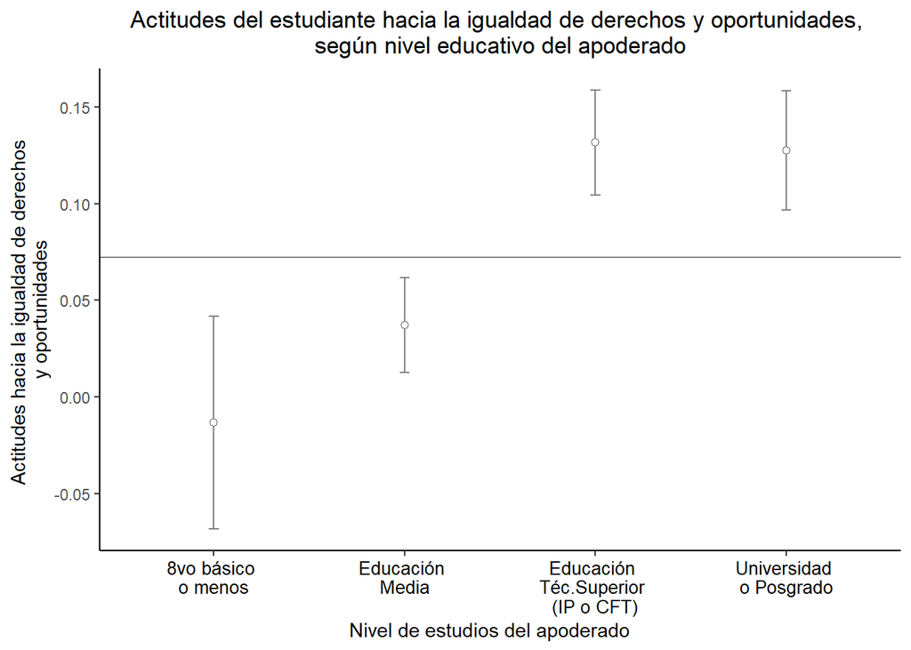

```r
plotdata <- data_proc %>%
  group_by(Educacion) %>%
  summarize(n = n(),
         mean = mean(igualdad.est),
         sd = sd(igualdad.est),
         se = sd / sqrt(n),
         ci = qt(0.99, df = n - 1) * sd / sqrt(n))
plotdata$Educacion <- factor(plotdata$Educacion, levels = c(1,2,3,4), labels = c(
"8vo básico
o menos",
"Educación
Media",
"Educación
Téc.Superior
(IP o CFT)",
"Universidad
o Posgrado"))
plotdata<-na.omit(plotdata)
plot_ig_educ <- ggplot(plotdata,
       aes(x = Educacion,
           y = mean,
           group = 1)) +
  geom_errorbar(aes(ymin = mean - se,
                    ymax = mean + se),
                width = .05, colour="grey50") +
  geom_point(shape = 21, colour = "#5A5858", fill = "white", size = 1.8) +
  geom_hline(yintercept = mean_ig,
             color = "grey50",
             linetype = "solid") +
 xlab("Nivel de estudios del apoderado") + ylab("Actitudes hacia la igualdad de derechos
y oportunidades") + theme_classic() +
    theme(axis.title.x = element_text(hjust = 0.48),
          axis.text.x = element_text(colour = "black", size = 10, hjust = 0.5),
          plot.title = element_text(hjust=0.5)) + ggtitle("Actitudes del estudiante hacia la igualdad de derechos y oportunidades,
según nivel educativo del apoderado")
plot_ig_educ
```

```r
ggsave(plot_ig_educ, file = "../output/ig_educ.png",device = "png",width = 20,height = 13,dpi = "retina",units = "cm")
```

### 7.1.2 Cantidad de libros

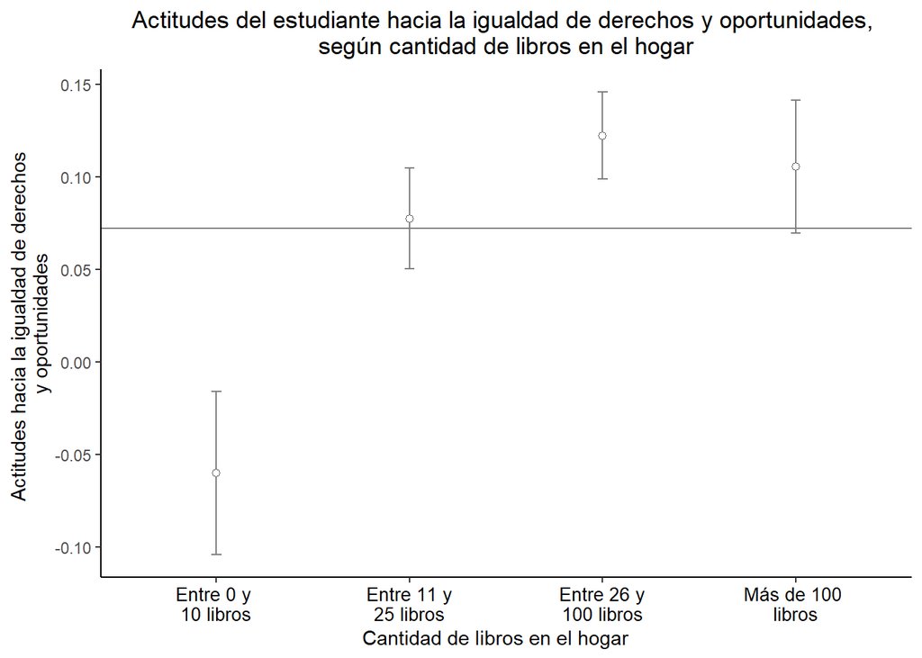

```r
plotdata <- data_proc %>%
  group_by(Libros_apod_rec) %>%
  summarize(n = n(),
         mean = mean(igualdad.est),
         sd = sd(igualdad.est),
         se = sd / sqrt(n),
         ci = qt(0.99, df = n - 1) * sd / sqrt(n))
plotdata$Libros_apod_rec <- factor(plotdata$Libros_apod_rec, levels = c(1,2,3,4), labels = c(
"Entre 0 y
10 libros",
"Entre 11 y
25 libros",
"Entre 26 y
100 libros",
"Más de 100
libros"))
plotdata<-na.omit(plotdata)
plot_ig_lib <- ggplot(plotdata,
       aes(x = Libros_apod_rec,
           y = mean,
           group = 1)) +
  geom_errorbar(aes(ymin = mean - se,
                    ymax = mean + se),
                width = .05, colour="grey50") +
  geom_point(shape = 21, colour = "#5A5858", fill = "white", size = 1.8) +
  geom_hline(yintercept = mean_ig,
             color = "grey50",
             linetype = "solid") +
 xlab("Cantidad de libros en el hogar") + ylab("Actitudes hacia la igualdad de derechos
y oportunidades") + theme_classic() +
    theme(axis.title.x = element_text(hjust = 0.48),
          axis.text.x = element_text(colour = "black", size = 10, hjust = 0.5),
          plot.title = element_text(hjust=0.5)) + ggtitle("Actitudes del estudiante hacia la igualdad de derechos y oportunidades,
según cantidad de libros en el hogar")
plot_ig_lib
```

```r
ggsave(plot_ig_lib, file = "../output/ig_lib.png",device = "png",width = 20,height = 13,dpi = "retina",units = "cm")
```

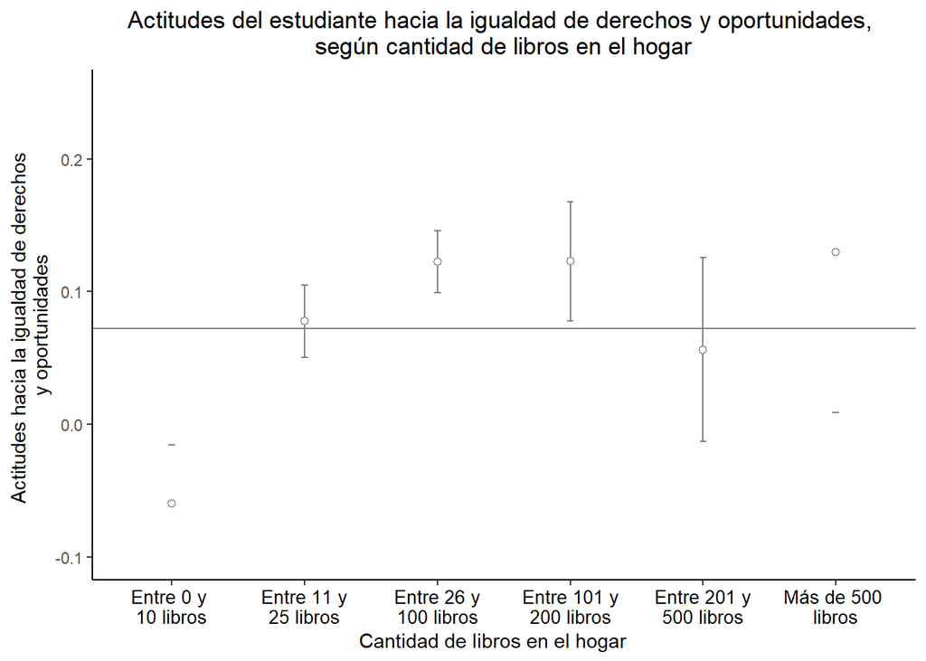

```r
plotdata <- data_proc %>%
  group_by(Libros_apod) %>%
  summarize(n = n(),
         mean = mean(igualdad.est),
         sd = sd(igualdad.est),
         se = sd / sqrt(n),
         ci = qt(0.99, df = n - 1) * sd / sqrt(n))
plotdata$Libros_apod <- factor(plotdata$Libros_apod, levels = c(1,2,3,4,5,6), labels = c(
"Entre 0 y
10 libros",
"Entre 11 y
25 libros",
"Entre 26 y
100 libros",
"Entre 101 y
200 libros",
"Entre 201 y
500 libros",
"Más de 500
libros"))
plotdata<-na.omit(plotdata)
plot_ig_lib2 <- ggplot(plotdata,
       aes(x = Libros_apod,
           y = mean,
           group = 1)) +
  geom_errorbar(aes(ymin = mean - se,
                    ymax = mean + se),
                width = .05, colour="grey50") +
  geom_point(shape = 21, colour = "#5A5858", fill = "white", size = 1.8) +
  geom_hline(yintercept = mean_ig,
             color = "grey50",
             linetype = "solid") +
 xlab("Cantidad de libros en el hogar") + ylab("Actitudes hacia la igualdad de derechos
y oportunidades") + theme_classic() +
    theme(axis.title.x = element_text(hjust = 0.48),
          axis.text.x = element_text(colour = "black", size = 10, hjust = 0.5),
          plot.title = element_text(hjust=0.5)) + ggtitle("Actitudes del estudiante hacia la igualdad de derechos y oportunidades,
según cantidad de libros en el hogar") + ylim(-0.1,0.25)
plot_ig_lib2
```

```r
ggsave(plot_ig_lib2, file = "../output/ig_lib2.png",device = "png",width = 20,height = 13,dpi = "retina",units = "cm")
```

### 7.1.3 Ingresos por quintiles

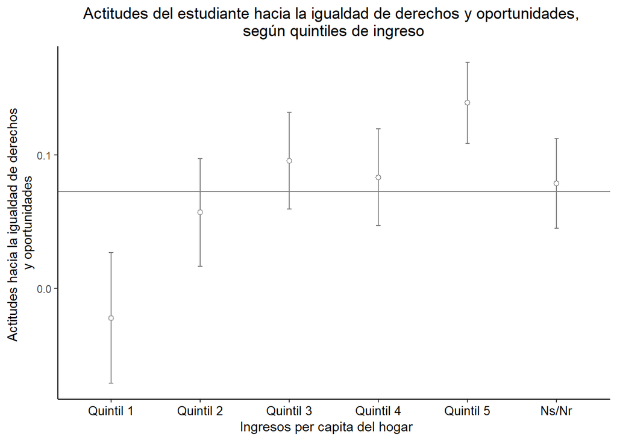

```r
plotdata <- data_proc %>%
  group_by(quintiles_ingresos_pc_factor) %>%
  summarize(n = n(),
         mean = mean(igualdad.est),
         sd = sd(igualdad.est),
         se = sd / sqrt(n),
         ci = qt(0.99, df = n - 1) * sd / sqrt(n))
plotdata<-na.omit(plotdata)
plot_ig_ing <- ggplot(plotdata,
       aes(x = quintiles_ingresos_pc_factor,
           y = mean,
           group = 1)) +
  geom_errorbar(aes(ymin = mean - se,
                    ymax = mean + se),
                width = .05, colour="grey50") +
  geom_point(shape = 21, colour = "#5A5858", fill = "white", size = 1.8) +
  geom_hline(yintercept = mean_ig,
             color = "grey50",
             linetype = "solid") +
 xlab("Ingresos per capita del hogar") + ylab("Actitudes hacia la igualdad de derechos
y oportunidades") + ggtitle("Actitudes del estudiante hacia la igualdad de derechos y oportunidades,
según quintiles de ingreso") + theme_classic() +
    theme(axis.title.x = element_text(hjust = 0.48),
          axis.text.x = element_text(colour = "black", size = 10, hjust = 0.5),
          plot.title = element_text(hjust=0.5)) #+ ylim(-0.1,0.25)
plot_ig_ing
```

```r
ggsave(plot_ig_ing, file = "../output/ig_ing.png",device = "png",width = 20,height = 13,dpi = "retina",units = "cm")
```

### 7.1.4 Sexo

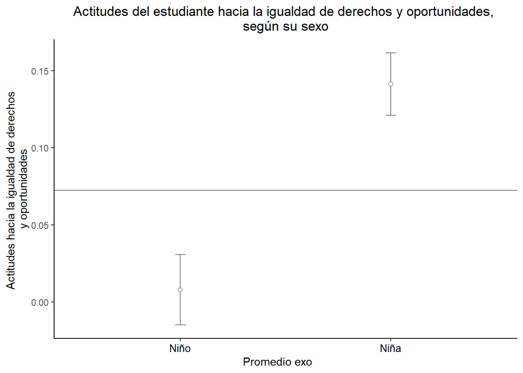

```r
plotdata <- data_proc %>%
  group_by(Sexo) %>%
  summarize(n = n(),
         mean = mean(igualdad.est),
         sd = sd(igualdad.est),
         se = sd / sqrt(n),
         ci = qt(0.99, df = n - 1) * sd / sqrt(n))
plotdata$Sexo <- factor(plotdata$Sexo, levels = c(1,2), labels = c(
"Niño",
"Niña"))
plotdata<-na.omit(plotdata)
plot_ig_sexo <- ggplot(plotdata,
       aes(x = Sexo,
           y = mean,
           group = 1)) +
  geom_errorbar(aes(ymin = mean - se,
                    ymax = mean + se),
                width = .05, colour="grey50") +
  geom_point(shape = 21, colour = "#5A5858", fill = "white", size = 1.8) +
  geom_hline(yintercept = mean_ig,
             color = "grey50",
             linetype = "solid") +
 xlab("Promedio exo") + ylab("Actitudes hacia la igualdad de derechos
y oportunidades") + ggtitle("Actitudes del estudiante hacia la igualdad de derechos y oportunidades,
según su sexo") + theme_classic() +
    theme(axis.title.x = element_text(hjust = 0.48),
          axis.text.x = element_text(colour = "black", size = 10, hjust = 0.5),
          plot.title = element_text(hjust=0.5)) #+ ylim(-0.1,0.25)
plot_ig_sexo
```

```r
ggsave(plot_ig_sexo, file = "../output/ig_sexo.png",device = "png",width = 20,height = 13,dpi = "retina",units = "cm")
```

### 7.1.5 Proporción de niñas

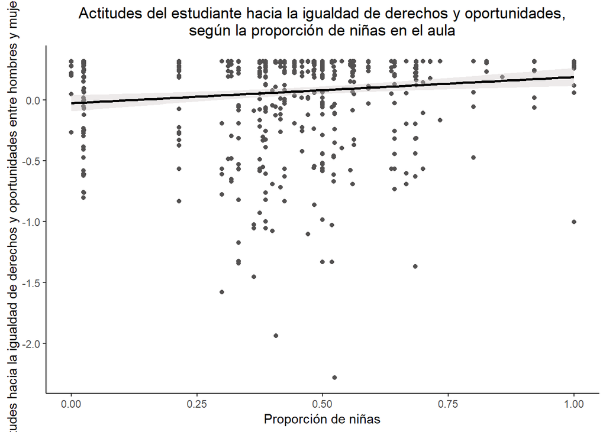

```r
plot_prop_ninas <- ggplot(data_proc, aes(x=num_fem, y=igualdad.est)) +
  geom_point(color="#535151") +
  geom_smooth(method=lm, color="#000000", fill="#D1CACA", se=TRUE) + xlab("Proporción de niñas") + ylab("Actitudes hacia la igualdad de derechos y oportunidades entre hombres y mujeres") + ggtitle("Actitudes del estudiante hacia la igualdad de derechos y oportunidades,
según la proporción de niñas en el aula") + theme_classic() +
    theme(plot.title = element_text(hjust=0.5))

plot_prop_ninas
```

```r
ggsave(plot_prop_ninas, file = "../output/ig_prop-niñas.png",device = "png",width = 20,height = 13,dpi = "retina",units = "cm")
```

### 7.1.6 Apertura a la discusión

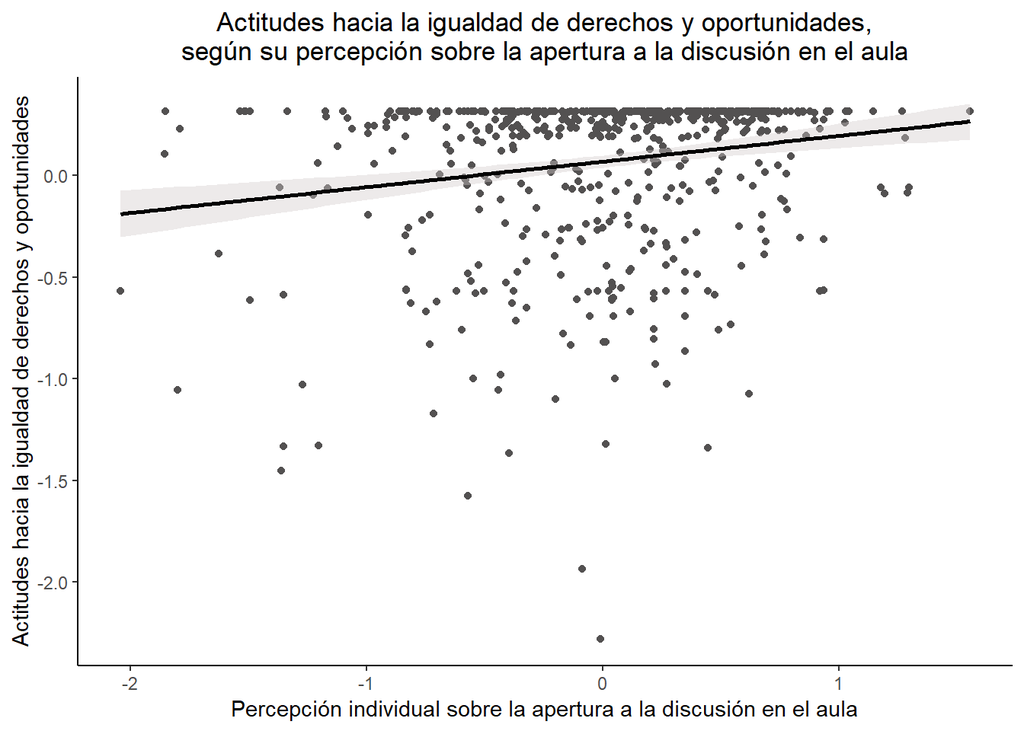

```r
plot_ap_discusion <- ggplot(data_proc, aes(x=ap_discusion, y=igualdad.est)) +
  geom_point(color="#535151") +
  geom_smooth(method=lm, color="#000000", fill="#D1CACA", se=TRUE) + xlab("Percepción individual sobre la apertura a la discusión en el aula") + ylab("Actitudes hacia la igualdad de derechos y oportunidades") + ggtitle("Actitudes hacia la igualdad de derechos y oportunidades,
según su percepción sobre la apertura a la discusión en el aula") + theme_classic() +
    theme(plot.title = element_text(hjust=0.5))

plot_ap_discusion
```

```r
ggsave(plot_ap_discusion, file = "../output/ig_ap_discusion_individual.png",device = "png",width = 20,height = 13,dpi = "retina",units = "cm")
```

### 7.1.7 Percepción promedio sobre la apertura a la discusión en el aula

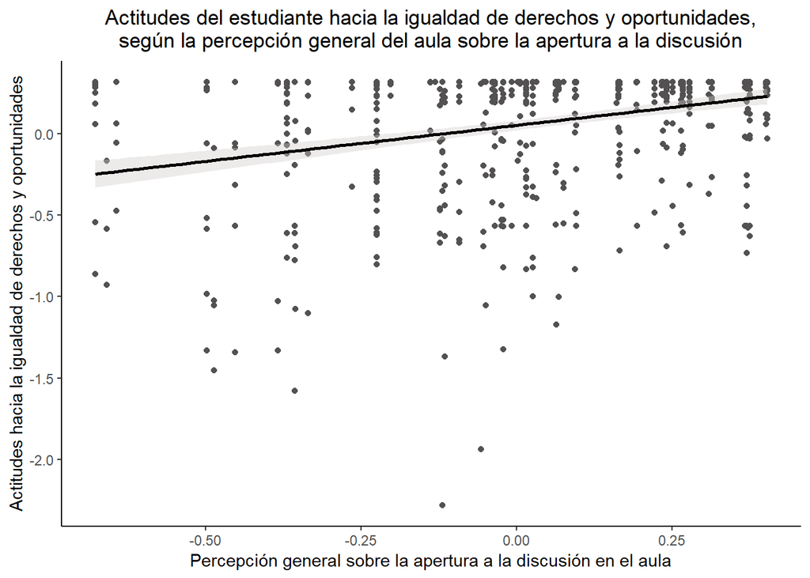

```r
plot_ap_discusion_prom <- ggplot(data_proc, aes(x=mean_discusion, y=igualdad.est)) +
  geom_point(color="#535151") +
  geom_smooth(method=lm, color="#000000", fill="#D1CACA", se=TRUE) + xlab("Percepción general sobre la apertura a la discusión en el aula") + ylab("Actitudes hacia la igualdad de derechos y oportunidades") + ggtitle("Actitudes del estudiante hacia la igualdad de derechos y oportunidades,
según la percepción general del aula sobre la apertura a la discusión") + theme_classic() +
    theme(plot.title = element_text(hjust=0.5))

plot_ap_discusion_prom
```

```r
ggsave(plot_ap_discusion_prom, file = "../output/ig_ap_discusion_promedio.png",device = "png",width = 20,height = 13,dpi = "retina",units = "cm")
```

### 7.1.8 Actitudes del apoderado

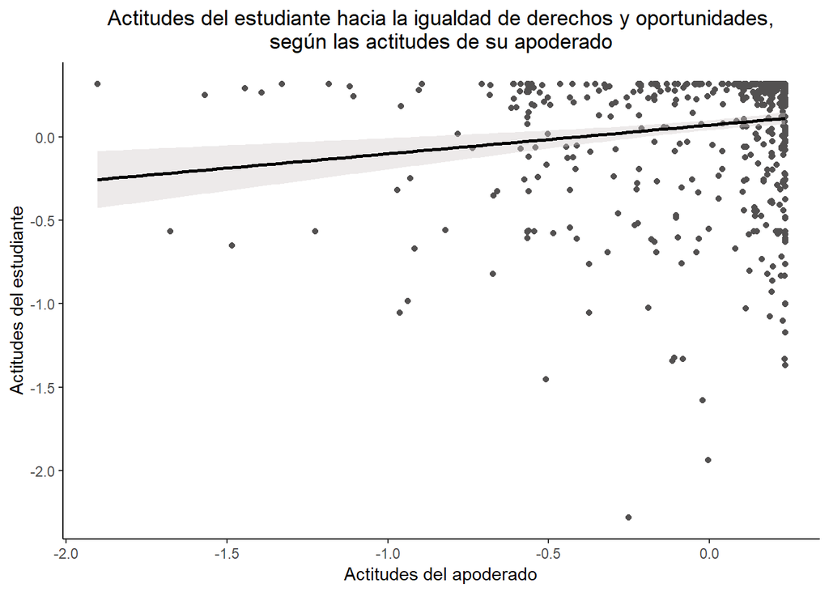

```r
plot_act_apod <- ggplot(data_proc, aes(x=igualdad.pad, y=igualdad.est)) +
  geom_point(color="#535151") +
  geom_smooth(method=lm, color="#000000", fill="#D1CACA", se=TRUE) + xlab("Actitudes del apoderado") + ylab("Actitudes del estudiante") + ggtitle("Actitudes del estudiante hacia la igualdad de derechos y oportunidades,
según las actitudes de su apoderado") + theme_classic() +
    theme(plot.title = element_text(hjust=0.5))

plot_act_apod
```

```r
ggsave(plot_act_apod, file = "../output/ig_prop-act_apod.png",device = "png",width = 20,height = 13,dpi = "retina",units = "cm")
```

## 7.2 Actitudes del estudiante hacia la distribución igualitaria de roles en la esfera pública

### 7.2.1 Educación

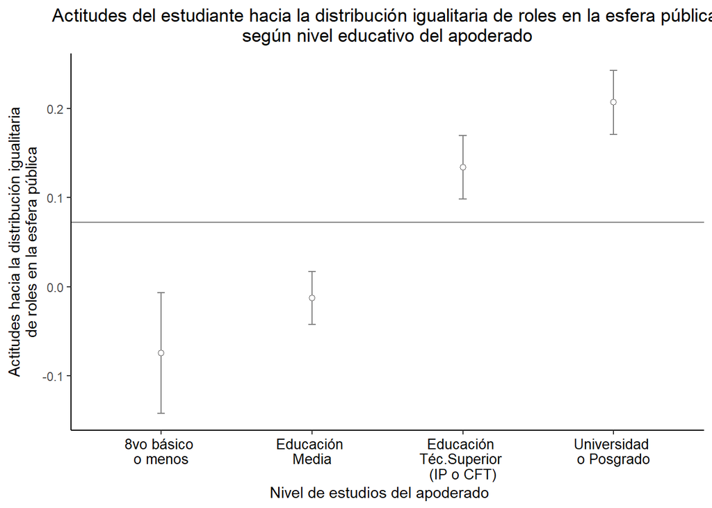

```r
plotdata <- data_proc %>%
  group_by(Educacion) %>%
  summarize(n = n(),
         mean = mean(esp_publico.est),
         sd = sd(esp_publico.est),
         se = sd / sqrt(n),
         ci = qt(0.99, df = n - 1) * sd / sqrt(n))
plotdata$Educacion <- factor(plotdata$Educacion, levels = c(1,2,3,4), labels = c(
"8vo básico
o menos",
"Educación
Media",
"Educación
Téc.Superior
(IP o CFT)",
"Universidad
o Posgrado"))
plotdata<-na.omit(plotdata)
plot_pub_educ <- ggplot(plotdata,
       aes(x = Educacion,
           y = mean,
           group = 1)) +
  geom_errorbar(aes(ymin = mean - se,
                    ymax = mean + se),
                width = .05, colour="grey50") +
  geom_point(shape = 21, colour = "#5A5858", fill = "white", size = 1.8) +
  geom_hline(yintercept = mean_ig,
             color = "grey50",
             linetype = "solid") +
 xlab("Nivel de estudios del apoderado") + ylab("Actitudes hacia la distribución igualitaria
de roles en la esfera pública") + theme_classic() +
    theme(axis.title.x = element_text(hjust = 0.48),
          axis.text.x = element_text(colour = "black", size = 10, hjust = 0.5),
          plot.title = element_text(hjust=0.5)) + ggtitle("Actitudes del estudiante hacia la distribución igualitaria de roles en la esfera pública,
según nivel educativo del apoderado")
plot_pub_educ
```

```r
ggsave(plot_pub_educ, file = "../output/pub_educ.png",device = "png",width = 20,height = 13,dpi = "retina",units = "cm")
```

### 7.2.2 Cantidad de libros

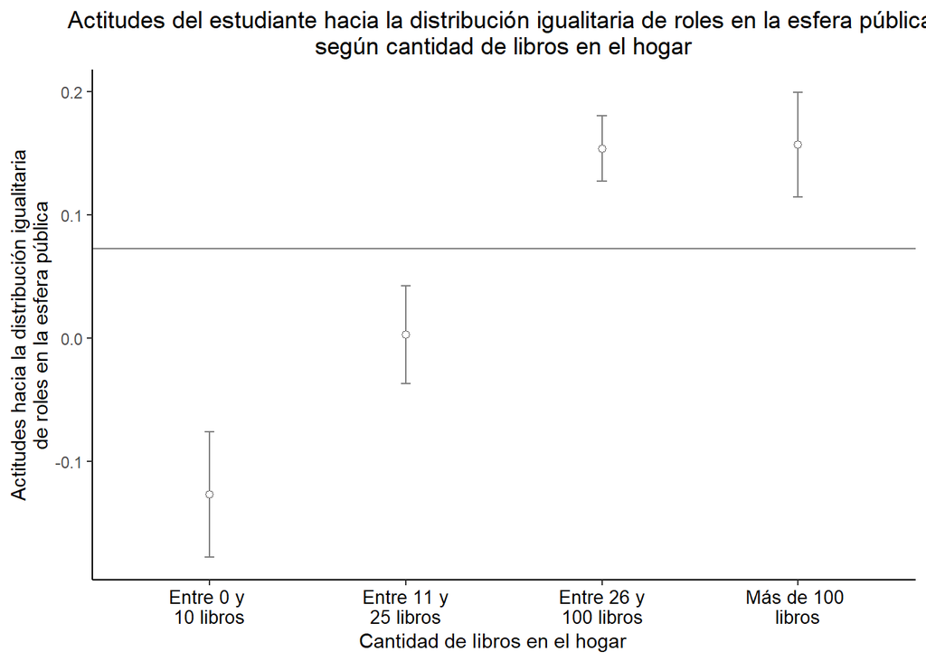

```r
plotdata <- data_proc %>%
  group_by(Libros_apod_rec) %>%
  summarize(n = n(),
         mean = mean(esp_publico.est),
         sd = sd(esp_publico.est),
         se = sd / sqrt(n),
         ci = qt(0.99, df = n - 1) * sd / sqrt(n))
plotdata$Libros_apod_rec <- factor(plotdata$Libros_apod_rec, levels = c(1,2,3,4), labels = c(
"Entre 0 y
10 libros",
"Entre 11 y
25 libros",
"Entre 26 y
100 libros",
"Más de 100
libros"))
plotdata<-na.omit(plotdata)
plot_pub_lib <- ggplot(plotdata,
       aes(x = Libros_apod_rec,
           y = mean,
           group = 1)) +
  geom_errorbar(aes(ymin = mean - se,
                    ymax = mean + se),
                width = .05, colour="grey50") +
  geom_point(shape = 21, colour = "#5A5858", fill = "white", size = 1.8) +
  geom_hline(yintercept = mean_ig,
             color = "grey50",
             linetype = "solid") +
 xlab("Cantidad de libros en el hogar") + ylab("Actitudes hacia la distribución igualitaria
de roles en la esfera pública") + theme_classic() +
    theme(axis.title.x = element_text(hjust = 0.48),
          axis.text.x = element_text(colour = "black", size = 10, hjust = 0.5),
          plot.title = element_text(hjust=0.5)) + ggtitle("Actitudes del estudiante hacia la distribución igualitaria de roles en la esfera pública,
según cantidad de libros en el hogar")
plot_pub_lib
```

```r
ggsave(plot_pub_lib, file = "../output/pub_lib.png",device = "png",width = 20,height = 13,dpi = "retina",units = "cm")
```

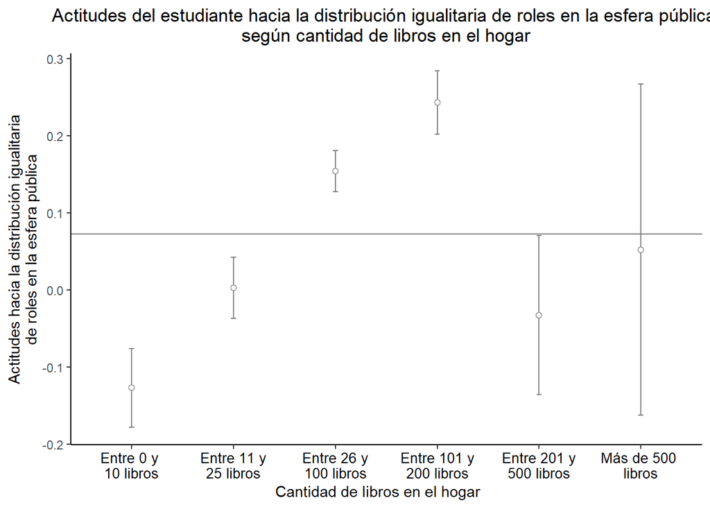

```r
plotdata <- data_proc %>%
  group_by(Libros_apod) %>%
  summarize(n = n(),
         mean = mean(esp_publico.est),
         sd = sd(esp_publico.est),
         se = sd / sqrt(n),
         ci = qt(0.99, df = n - 1) * sd / sqrt(n))
plotdata$Libros_apod <- factor(plotdata$Libros_apod, levels = c(1,2,3,4,5,6), labels = c(
"Entre 0 y
10 libros",
"Entre 11 y
25 libros",
"Entre 26 y
100 libros",
"Entre 101 y
200 libros",
"Entre 201 y
500 libros",
"Más de 500
libros"))
plotdata<-na.omit(plotdata)
plot_pub_lib2 <- ggplot(plotdata,
       aes(x = Libros_apod,
           y = mean,
           group = 1)) +
  geom_errorbar(aes(ymin = mean - se,
                    ymax = mean + se),
                width = .05, colour="grey50") +
  geom_point(shape = 21, colour = "#5A5858", fill = "white", size = 1.8) +
  geom_hline(yintercept = mean_ig,
             color = "grey50",
             linetype = "solid") +
 xlab("Cantidad de libros en el hogar") + ylab("Actitudes hacia la distribución igualitaria
de roles en la esfera pública") + theme_classic() +
    theme(axis.title.x = element_text(hjust = 0.48),
          axis.text.x = element_text(colour = "black", size = 10, hjust = 0.5),
          plot.title = element_text(hjust=0.5)) + ggtitle("Actitudes del estudiante hacia la distribución igualitaria de roles en la esfera pública,
según cantidad de libros en el hogar") #+ ylim(-0.1,0.25)
plot_pub_lib2
```

```r
ggsave(plot_pub_lib2, file = "../output/pub_lib2.png",device = "png",width = 20,height = 13,dpi = "retina",units = "cm")
```

### 7.2.3 Ingresos por quintiles

[figure not shown]

```r
plotdata <- data_proc %>%
  group_by(quintiles_ingresos_pc_factor) %>%
  summarize(n = n(),
         mean = mean(esp_publico.est),
         sd = sd(esp_publico.est),
         se = sd / sqrt(n),
         ci = qt(0.99, df = n - 1) * sd / sqrt(n))
plotdata<-na.omit(plotdata)
plot_pub_ing <- ggplot(plotdata,
       aes(x = quintiles_ingresos_pc_factor,
           y = mean,
           group = 1)) +
  geom_errorbar(aes(ymin = mean - se,
                    ymax = mean + se),
                width = .05, colour="grey50") +
  geom_point(shape = 21, colour = "#5A5858", fill = "white", size = 1.8) +
  geom_hline(yintercept = mean_ig,
             color = "grey50",
             linetype = "solid") +
 xlab("Ingresos per capita del hogar") + ylab("Actitudes hacia la distribución igualitaria
de roles en la esfera pública") + ggtitle("Actitudes del estudiante hacia la distribución igualitaria de roles en la esfera pública,
según quintiles de ingreso") + theme_classic() +
    theme(axis.title.x = element_text(hjust = 0.48),
          axis.text.x = element_text(colour = "black", size = 10, hjust = 0.5),
          plot.title = element_text(hjust=0.5)) + ggtitle("
Actitudes del estudiante hacia la distribución igualitaria
de roles en la esfera pública,
según nivel educativo del apoderado") #+ ylim(-0.1,0.25)
plot_pub_ing
```

```r
ggsave(plot_pub_ing, file = "../output/pub_ing.png",device = "png",width = 20,height = 13,dpi = "retina",units = "cm")
```

### 7.2.4 Sexo

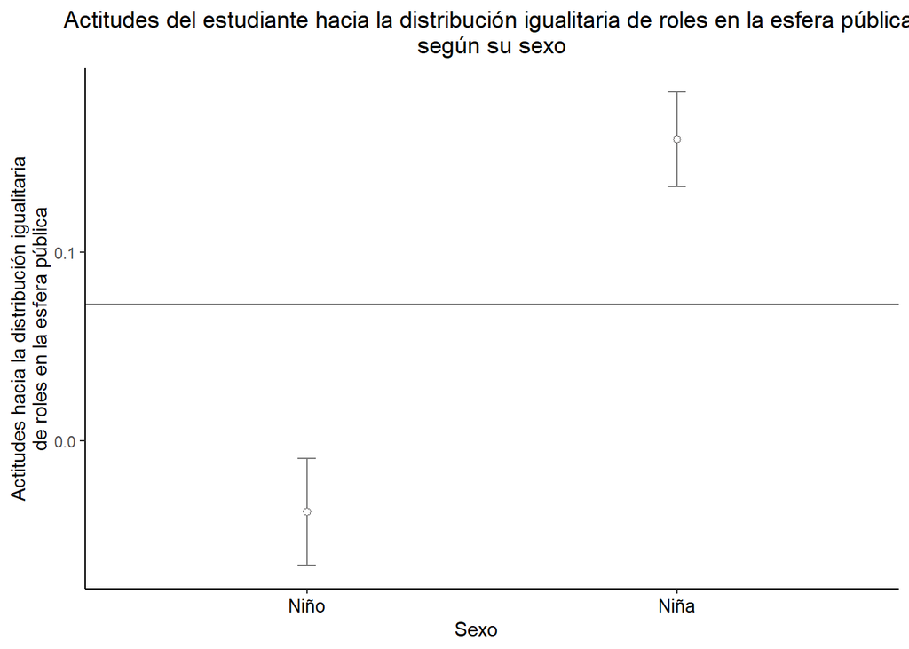

```r
plotdata <- data_proc %>%
  group_by(Sexo) %>%
  summarize(n = n(),
         mean = mean(esp_publico.est),
         sd = sd(esp_publico.est),
         se = sd / sqrt(n),
         ci = qt(0.99, df = n - 1) * sd / sqrt(n))
plotdata$Sexo <- factor(plotdata$Sexo, levels = c(1,2), labels = c(
"Niño",
"Niña"))
plotdata<-na.omit(plotdata)
plot_pub_sexo <- ggplot(plotdata,
       aes(x = Sexo,
           y = mean,
           group = 1)) +
  geom_errorbar(aes(ymin = mean - se,
                    ymax = mean + se),
                width = .05, colour="grey50") +
  geom_point(shape = 21, colour = "#5A5858", fill = "white", size = 1.8) +
  geom_hline(yintercept = mean_ig,
             color = "grey50",
             linetype = "solid") +
 xlab("Sexo") + ylab("Actitudes hacia la distribución igualitaria
de roles en la esfera pública") + theme_classic() +
    theme(axis.title.x = element_text(hjust = 0.48),
          axis.text.x = element_text(colour = "black", size = 10, hjust = 0.5),
          plot.title = element_text(hjust=0.5)) + ggtitle("Actitudes del estudiante hacia la distribución igualitaria de roles en la esfera pública,
según su sexo") #+ ylim(-0.1,0.25)
plot_pub_sexo
```

```r
ggsave(plot_pub_sexo, file = "../output/pub_sexo.png",device = "png",width = 20,height = 13,dpi = "retina",units = "cm")
```

### 7.2.5 Proporción de niñas

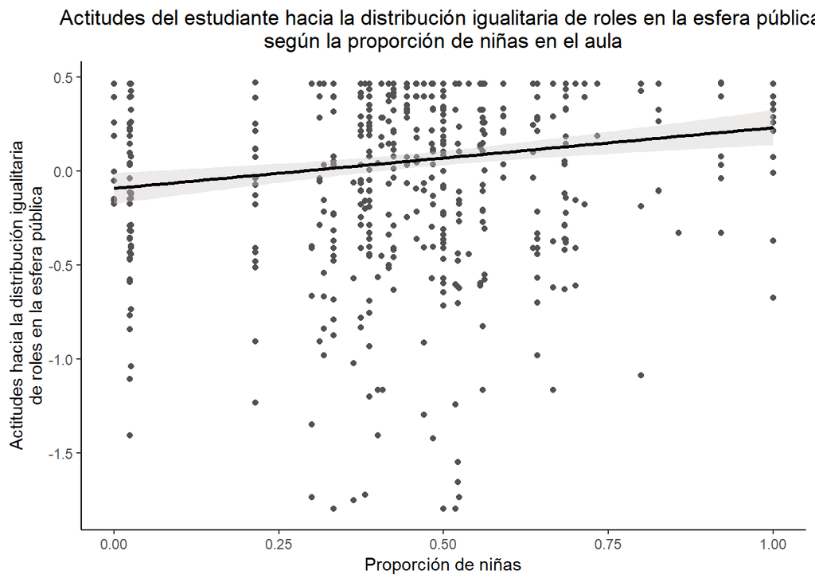

```r
plot_prop_ninas <- ggplot(data_proc, aes(x=num_fem, y=esp_publico.est)) +
  geom_point(color="#535151") +
  geom_smooth(method=lm, color="#000000", fill="#D1CACA", se=TRUE) + xlab("Proporción de niñas") + ylab("Actitudes hacia la distribución igualitaria
de roles en la esfera pública") + ggtitle("Actitudes del estudiante hacia la distribución igualitaria de roles en la esfera pública,
según la proporción de niñas en el aula") + theme_classic() +
    theme(plot.title = element_text(hjust=0.5))

plot_prop_ninas
```

```r
ggsave(plot_prop_ninas, file = "../output/priv_prop-niñas.png",device = "png",width = 20,height = 13,dpi = "retina",units = "cm")
```

### 7.2.6 Apertura a la discusión

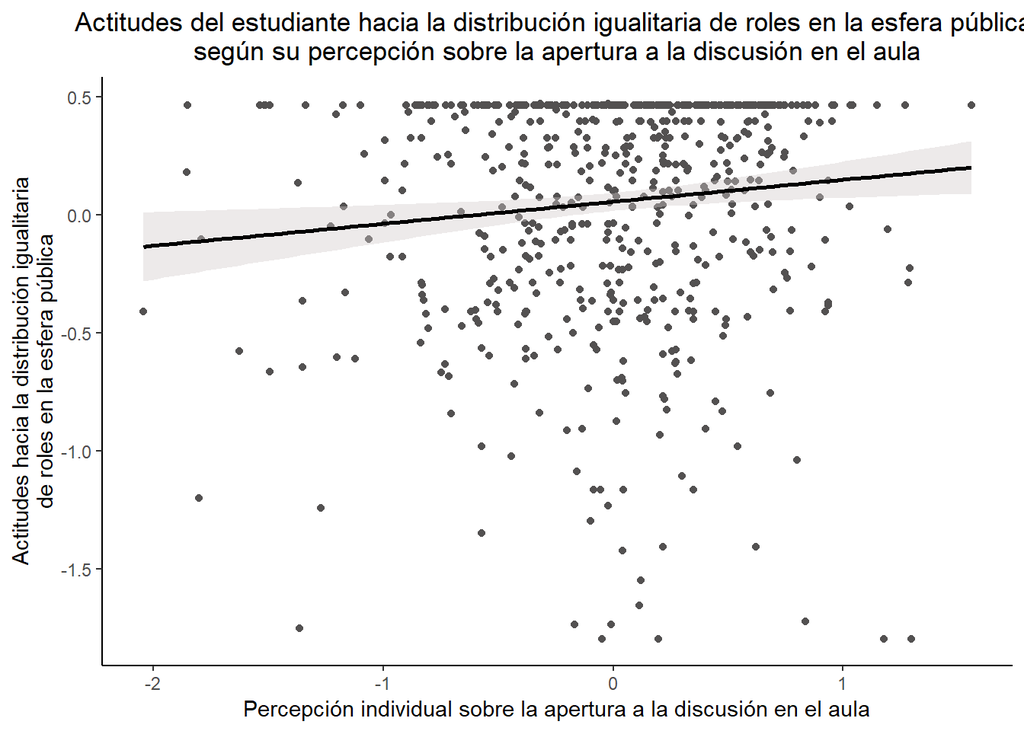

```r
plot_ap_discusion <- ggplot(data_proc, aes(x=ap_discusion, y=esp_publico.est)) +
  geom_point(color="#535151") +
  geom_smooth(method=lm, color="#000000", fill="#D1CACA", se=TRUE) + xlab("Percepción individual sobre la apertura a la discusión en el aula") + ylab("Actitudes hacia la distribución igualitaria
de roles en la esfera pública") + ggtitle("Actitudes del estudiante hacia la distribución igualitaria de roles en la esfera pública,
según su percepción sobre la apertura a la discusión en el aula") + theme_classic() +
    theme(plot.title = element_text(hjust=0.5))

plot_ap_discusion
```

```r
ggsave(plot_ap_discusion, file = "../output/pub_prop-ap_discusion_individual.png",device = "png",width = 20,height = 13,dpi = "retina",units = "cm")
```

### 7.2.7 Percepción promedio sobre la apertura a la discusión en el aula

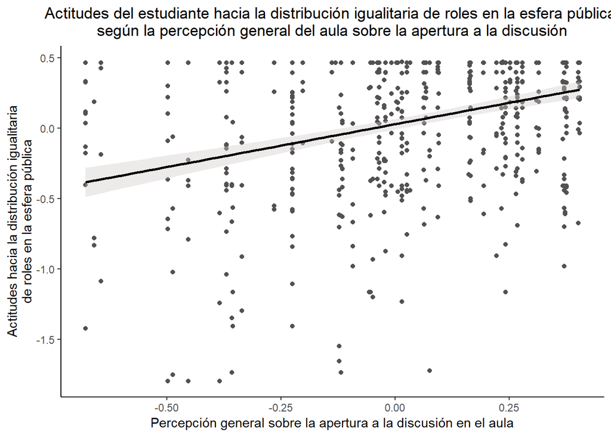

```r
plot_ap_discusion_prom <- ggplot(data_proc, aes(x=mean_discusion, y=esp_publico.est)) +
  geom_point(color="#535151") +
  geom_smooth(method=lm, color="#000000", fill="#D1CACA", se=TRUE) + xlab("Percepción general sobre la apertura a la discusión en el aula") + ylab("Actitudes hacia la distribución igualitaria
de roles en la esfera pública") + ggtitle("Actitudes del estudiante hacia la distribución igualitaria de roles en la esfera pública,
según la percepción general del aula sobre la apertura a la discusión") + theme_classic() +
    theme(plot.title = element_text(hjust=0.5))

plot_ap_discusion_prom
```

```r
ggsave(plot_ap_discusion_prom, file = "../output/pub_prop-ap_discusion_promedio.png",device = "png",width = 20,height = 13,dpi = "retina",units = "cm")
```

### 7.2.8 Actitudes del apoderado

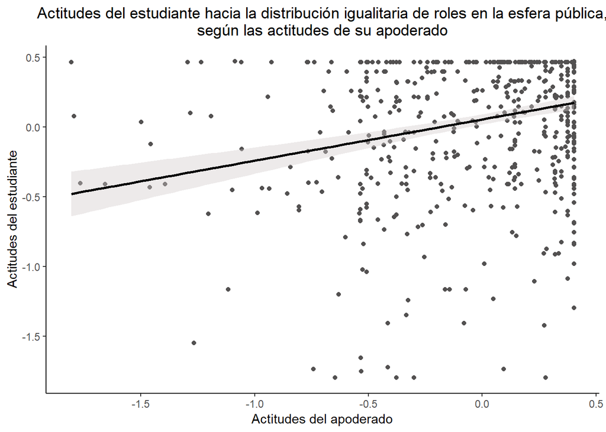

```r
plot_act_apod <- ggplot(data_proc, aes(x=esp_publico.pad, y=esp_publico.est)) +
  geom_point(color="#535151") +
  geom_smooth(method=lm, color="#000000", fill="#D1CACA", se=TRUE) + xlab("Actitudes del apoderado") + ylab("Actitudes del estudiante") + ggtitle("Actitudes del estudiante hacia la distribución igualitaria de roles en la esfera pública,
según las actitudes de su apoderado") + theme_classic() +
    theme(plot.title = element_text(hjust=0.5))

plot_act_apod
```

```r
ggsave(plot_act_apod, file = "../output/pub_prop-act_apod.png",device = "png",width = 20,height = 13,dpi = "retina",units = "cm")
```

## 7.3 Actitudes del estudiante hacia la distribución igualitaria de roles en la esfera privada

### 7.3.1 Educación

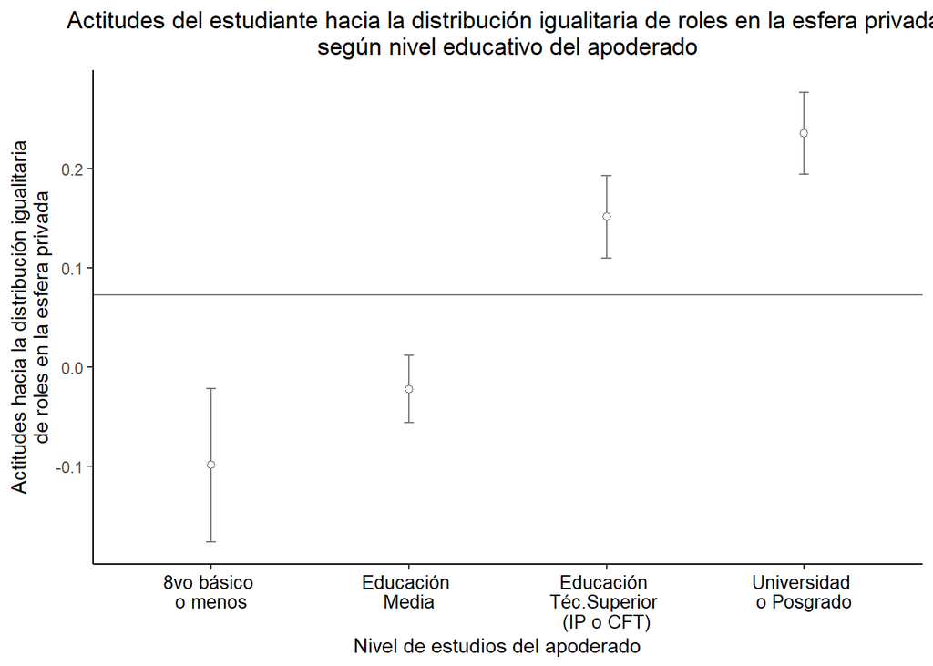

```r
plotdata <- data_proc %>%
  group_by(Educacion) %>%
  summarize(n = n(),
         mean = mean(esp_privado.est),
         sd = sd(esp_privado.est),
         se = sd / sqrt(n),
         ci = qt(0.99, df = n - 1) * sd / sqrt(n))
plotdata$Educacion <- factor(plotdata$Educacion, levels = c(1,2,3,4), labels = c(
"8vo básico
o menos",
"Educación
Media",
"Educación
Téc.Superior
(IP o CFT)",
"Universidad
o Posgrado"))
plotdata<-na.omit(plotdata)
plot_priv_educ <- ggplot(plotdata,
       aes(x = Educacion,
           y = mean,
           group = 1)) +
  geom_errorbar(aes(ymin = mean - se,
                    ymax = mean + se),
                width = .05, colour="grey50") +
  geom_point(shape = 21, colour = "#5A5858", fill = "white", size = 1.8) +
  geom_hline(yintercept = mean_ig,
             color = "grey50",
             linetype = "solid") +
 xlab("Nivel de estudios del apoderado") + ylab("Actitudes hacia la distribución igualitaria
de roles en la esfera privada") + theme_classic() +
    theme(axis.title.x = element_text(hjust = 0.48),
          axis.text.x = element_text(colour = "black", size = 10, hjust = 0.5),
          plot.title = element_text(hjust=0.5)) + ggtitle("Actitudes del estudiante hacia la distribución igualitaria de roles en la esfera privada,
según nivel educativo del apoderado")
plot_priv_educ
```

```r
ggsave(plot_priv_educ, file = "../output/priv_educ.png",device = "png",width = 20,height = 13,dpi = "retina",units = "cm")
```

### 7.3.2 Cantidad de libros

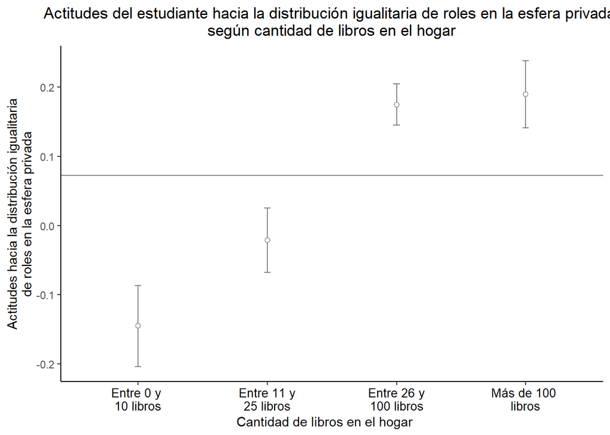

```r
plotdata <- data_proc %>%
  group_by(Libros_apod_rec) %>%
  summarize(n = n(),
         mean = mean(esp_privado.est),
         sd = sd(esp_privado.est),
         se = sd / sqrt(n),
         ci = qt(0.99, df = n - 1) * sd / sqrt(n))
plotdata$Libros_apod_rec <- factor(plotdata$Libros_apod_rec, levels = c(1,2,3,4), labels = c(
"Entre 0 y
10 libros",
"Entre 11 y
25 libros",
"Entre 26 y
100 libros",
"Más de 100
libros"))
plotdata<-na.omit(plotdata)
plot_priv_lib <- ggplot(plotdata,
       aes(x = Libros_apod_rec,
           y = mean,
           group = 1)) +
  geom_errorbar(aes(ymin = mean - se,
                    ymax = mean + se),
                width = .05, colour="grey50") +
  geom_point(shape = 21, colour = "#5A5858", fill = "white", size = 1.8) +
  geom_hline(yintercept = mean_ig,
             color = "grey50",
             linetype = "solid") +
 xlab("Cantidad de libros en el hogar") + ylab("Actitudes hacia la distribución igualitaria
de roles en la esfera privada") + theme_classic() +
    theme(axis.title.x = element_text(hjust = 0.48),
          axis.text.x = element_text(colour = "black", size = 10, hjust = 0.5),
          plot.title = element_text(hjust=0.5)) + ggtitle("Actitudes del estudiante hacia la distribución igualitaria de roles en la esfera privada,
según cantidad de libros en el hogar")
plot_priv_lib
```

```r
ggsave(plot_priv_lib, file = "../output/priv_lib.png",device = "png",width = 20,height = 13,dpi = "retina",units = "cm")
```

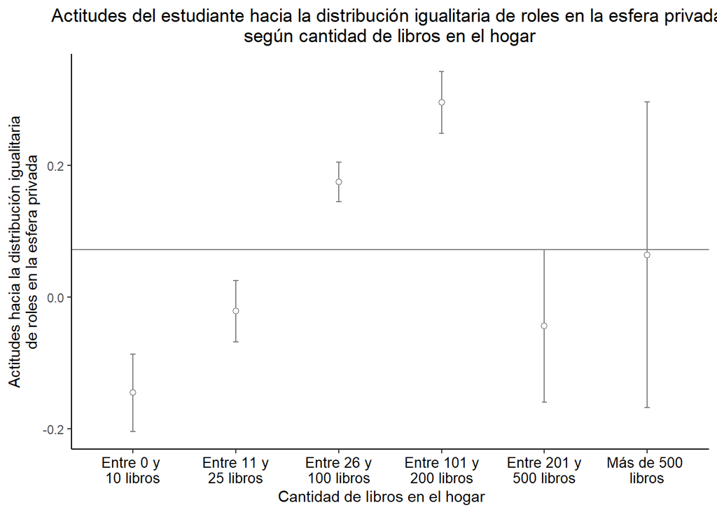

```r
plotdata <- data_proc %>%
  group_by(Libros_apod) %>%
  summarize(n = n(),
         mean = mean(esp_privado.est),
         sd = sd(esp_privado.est),
         se = sd / sqrt(n),
         ci = qt(0.99, df = n - 1) * sd / sqrt(n))
plotdata$Libros_apod <- factor(plotdata$Libros_apod, levels = c(1,2,3,4,5,6), labels = c(
"Entre 0 y
10 libros",
"Entre 11 y
25 libros",
"Entre 26 y
100 libros",
"Entre 101 y
200 libros",
"Entre 201 y
500 libros",
"Más de 500
libros"))
plotdata<-na.omit(plotdata)
plot_priv_lib2 <- ggplot(plotdata,
       aes(x = Libros_apod,
           y = mean,
           group = 1)) +
  geom_errorbar(aes(ymin = mean - se,
                    ymax = mean + se),
                width = .05, colour="grey50") +
  geom_point(shape = 21, colour = "#5A5858", fill = "white", size = 1.8) +
  geom_hline(yintercept = mean_ig,
             color = "grey50",
             linetype = "solid") +
 xlab("Cantidad de libros en el hogar") + ylab("Actitudes hacia la distribución igualitaria
de roles en la esfera privada") + theme_classic() +
    theme(axis.title.x = element_text(hjust = 0.48),
          axis.text.x = element_text(colour = "black", size = 10, hjust = 0.5),
          plot.title = element_text(hjust=0.5)) + ggtitle("Actitudes del estudiante hacia la distribución igualitaria de roles en la esfera privada,
según cantidad de libros en el hogar") #+ ylim(-0.1,0.25)
plot_priv_lib2
```

```r
ggsave(plot_priv_lib2, file = "../output/priv_lib2.png",device = "png",width = 20,height = 13,dpi = "retina",units = "cm")
```

### 7.3.3 Ingresos por quintiles

[figure not shown]

```r
plotdata <- data_proc %>%
  group_by(quintiles_ingresos_pc_factor) %>%
  summarize(n = n(),
         mean = mean(esp_privado.est),
         sd = sd(esp_privado.est),
         se = sd / sqrt(n),
         ci = qt(0.99, df = n - 1) * sd / sqrt(n))
plotdata<-na.omit(plotdata)
plot_priv_ing <- ggplot(plotdata,
       aes(x = quintiles_ingresos_pc_factor,
           y = mean,
           group = 1)) +
  geom_errorbar(aes(ymin = mean - se,
                    ymax = mean + se),
                width = .05, colour="grey50") +
  geom_point(shape = 21, colour = "#5A5858", fill = "white", size = 1.8) +
  geom_hline(yintercept = mean_ig,
             color = "grey50",
             linetype = "solid") +
 xlab("Ingresos per capita del hogar") + ylab("Actitudes hacia la distribución igualitaria
de roles en la esfera privada") + ggtitle("Actitudes del estudiante hacia la distribución igualitaria de roles en la esfera privada,
según quintiles de ingreso") + theme_classic() +
    theme(axis.title.x = element_text(hjust = 0.48),
          axis.text.x = element_text(colour = "black", size = 10, hjust = 0.5),
          plot.title = element_text(hjust=0.5)) + ggtitle("
Actitudes del estudiante hacia la distribución igualitaria
de roles en la esfera privada,
según nivel educativo del apoderado") #+ ylim(-0.1,0.25)
plot_priv_ing
```

```r
ggsave(plot_priv_ing, file = "../output/priv_ing.png",device = "png",width = 20,height = 13,dpi = "retina",units = "cm")
```

### 7.3.4 Sexo

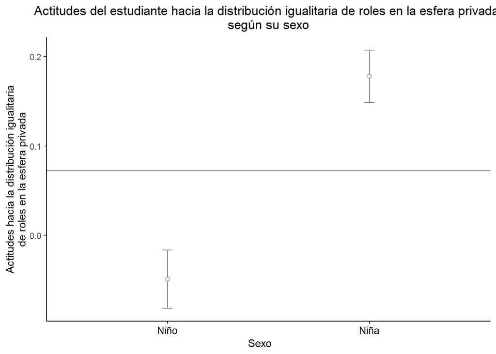

```r
plotdata <- data_proc %>%
  group_by(Sexo) %>%
  summarize(n = n(),
         mean = mean(esp_privado.est),
         sd = sd(esp_privado.est),
         se = sd / sqrt(n),
         ci = qt(0.99, df = n - 1) * sd / sqrt(n))
plotdata$Sexo <- factor(plotdata$Sexo, levels = c(1,2), labels = c(
"Niño",
"Niña"))
plotdata<-na.omit(plotdata)
plot_priv_sexo <- ggplot(plotdata,
       aes(x = Sexo,
           y = mean,
           group = 1)) +
  geom_errorbar(aes(ymin = mean - se,
                    ymax = mean + se),
                width = .05, colour="grey50") +
  geom_point(shape = 21, colour = "#5A5858", fill = "white", size = 1.8) +
  geom_hline(yintercept = mean_ig,
             color = "grey50",
             linetype = "solid") +
 xlab("Sexo") + ylab("Actitudes hacia la distribución igualitaria
de roles en la esfera privada") + theme_classic() +
    theme(axis.title.x = element_text(hjust = 0.48),
          axis.text.x = element_text(colour = "black", size = 10, hjust = 0.5),
          plot.title = element_text(hjust=0.5)) + ggtitle("Actitudes del estudiante hacia la distribución igualitaria de roles en la esfera privada,
según su sexo") #+ ylim(-0.1,0.25)
plot_priv_sexo
```

```r
ggsave(plot_priv_sexo, file = "../output/priv_sexo.png",device = "png",width = 20,height = 13,dpi = "retina",units = "cm")
```

### 7.3.5 Proporción de niñas

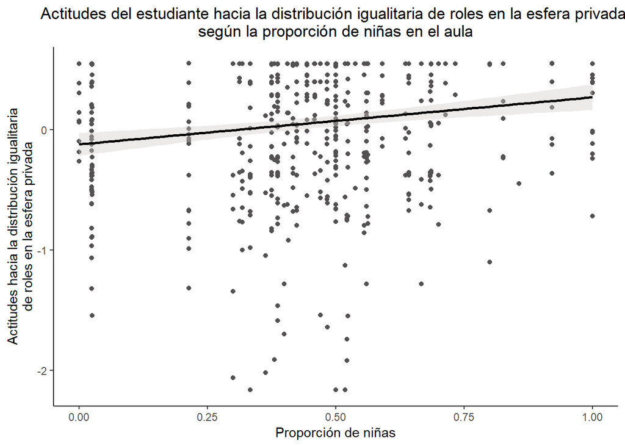

```r
plot_prop_ninas <- ggplot(data_proc, aes(x=num_fem, y=esp_privado.est)) +
  geom_point(color="#535151") +
  geom_smooth(method=lm, color="#000000", fill="#D1CACA", se=TRUE) + xlab("Proporción de niñas") + ylab("Actitudes hacia la distribución igualitaria
de roles en la esfera privada") + ggtitle("Actitudes del estudiante hacia la distribución igualitaria de roles en la esfera privada,
según la proporción de niñas en el aula") + theme_classic() +
    theme(plot.title = element_text(hjust=0.5))

plot_prop_ninas
```

```r
ggsave(plot_prop_ninas, file = "../output/priv_prop-niñas.png",device = "png",width = 20,height = 13,dpi = "retina",units = "cm")
```

### 7.3.6 Apertura a la discusión

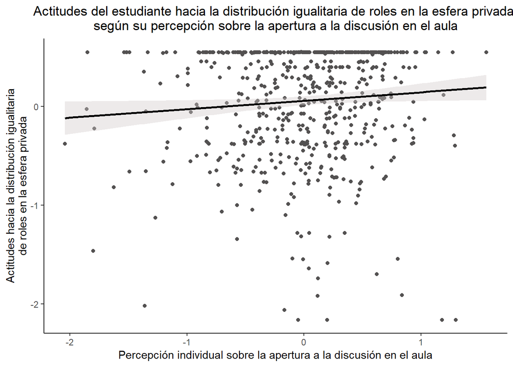

```r
plot_ap_discusion <- ggplot(data_proc, aes(x=ap_discusion, y=esp_privado.est)) +
  geom_point(color="#535151") +
  geom_smooth(method=lm, color="#000000", fill="#D1CACA", se=TRUE) + xlab("Percepción individual sobre la apertura a la discusión en el aula") + ylab("Actitudes hacia la distribución igualitaria
de roles en la esfera privada") + ggtitle("Actitudes del estudiante hacia la distribución igualitaria de roles en la esfera privada,
según su percepción sobre la apertura a la discusión en el aula") + theme_classic() +
    theme(plot.title = element_text(hjust=0.5))

plot_ap_discusion
```

```r
ggsave(plot_ap_discusion, file = "../output/priv_prop-ap_discusion_individual.png",device = "png",width = 20,height = 13,dpi = "retina",units = "cm")
```

### 7.3.7 Percepción promedio sobre la apertura a la discusión en el aula

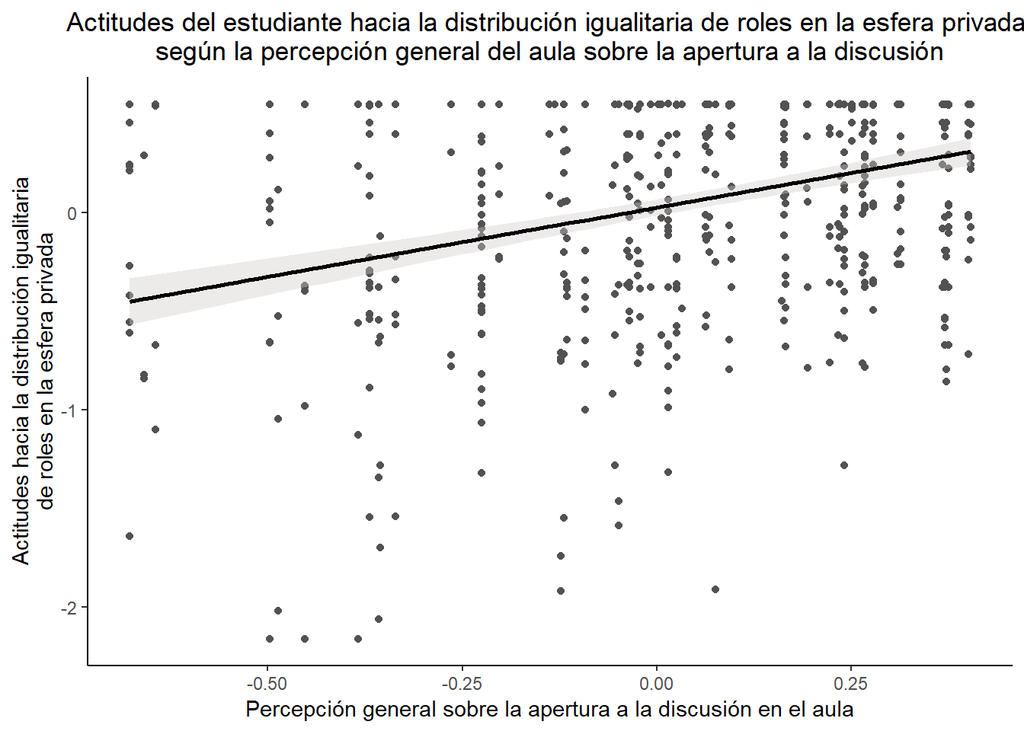

```r
plot_ap_discusion_prom <- ggplot(data_proc, aes(x=mean_discusion, y=esp_privado.est)) +
  geom_point(color="#535151") +
  geom_smooth(method=lm, color="#000000", fill="#D1CACA", se=TRUE) + xlab("Percepción general sobre la apertura a la discusión en el aula") + ylab("Actitudes hacia la distribución igualitaria
de roles en la esfera privada") + ggtitle("Actitudes del estudiante hacia la distribución igualitaria de roles en la esfera privada,
según la percepción general del aula sobre la apertura a la discusión") + theme_classic() +
    theme(plot.title = element_text(hjust=0.5))

plot_ap_discusion_prom
```

```r
ggsave(plot_ap_discusion_prom, file = "../output/priv_prop-ap_discusion_promedio.png",device = "png",width = 20,height = 13,dpi = "retina",units = "cm")
```

### 7.3.8 Actitudes del apoderado

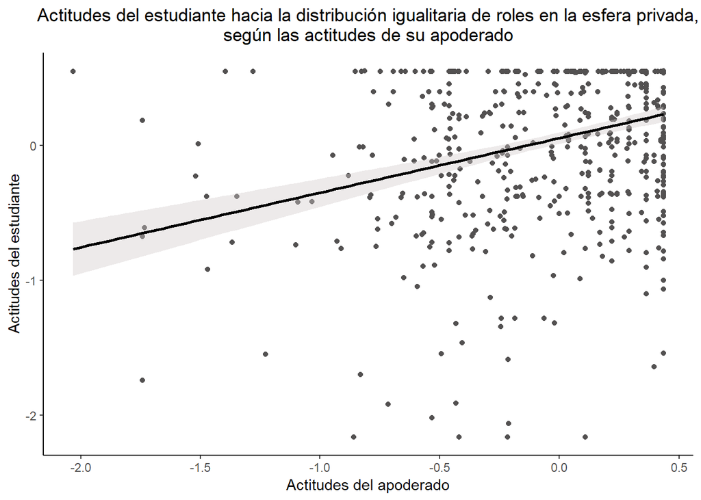

```r
plot_act_apod <- ggplot(data_proc, aes(x=esp_privado.pad, y=esp_privado.est)) +
  geom_point(color="#535151") +
  geom_smooth(method=lm, color="#000000", fill="#D1CACA", se=TRUE) + xlab("Actitudes del apoderado") + ylab("Actitudes del estudiante") + ggtitle("Actitudes del estudiante hacia la distribución igualitaria de roles en la esfera privada,
según las actitudes de su apoderado") + theme_classic() +
    theme(plot.title = element_text(hjust=0.5))

plot_act_apod
```

```r
ggsave(plot_act_apod, file = "../output/priv_prop-act_apod.png",device = "png",width = 20,height = 13,dpi = "retina",units = "cm")
```

# 8 Modelos de regresión: Base de datos reducida

## 8.1 Modelo nulo

```r
data_proc$RBD <- as.factor(data_proc$RBD)

reg0_igualdad <- lme4::lmer(igualdad.est ~ 1 + (1 | RBD), data=data_proc)
reg0_pub <- lme4::lmer(esp_publico.est ~ 1 + (1 | RBD), data=data_proc)
reg0_priv <- lme4::lmer(esp_privado.est ~ 1 + (1 | RBD), data=data_proc)

stargazer::stargazer(reg0_igualdad,reg0_pub, reg0_priv,
  column.labels=c("Igualdad","Espacio público", "Espacio privado"),
  type ='text')
```

```
##
## ================================================================
##                                 Dependent variable:
##                     --------------------------------------------
##                     igualdad.est esp_publico.est esp_privado.est
##                       Igualdad   Espacio público Espacio privado
##                         (1)            (2)             (3)
## ----------------------------------------------------------------
## Constant               0.022         0.0003          -0.001
##                       (0.030)        (0.038)         (0.044)
##
## ----------------------------------------------------------------
## Observations            627            627             627
## Log Likelihood        -272.989      -403.845        -491.552
## Akaike Inf. Crit.     551.977        813.691         989.104
## Bayesian Inf. Crit.   565.300        827.014        1,002.427
## ================================================================
## Note:                                *p<0.1; **p<0.05; ***p<0.01
```

```r
screenreg(list(reg0_igualdad,reg0_pub, reg0_priv))
```

```
##
## ==================================================
##                       Model 1   Model 2   Model 3
## --------------------------------------------------
## (Intercept)              0.02      0.00     -0.00
##                         (0.03)    (0.04)    (0.04)
## --------------------------------------------------
## AIC                    551.98    813.69    989.10
## BIC                    565.30    827.01   1002.43
## Log Likelihood        -272.99   -403.85   -491.55
## Num. obs.              627       627       627
## Num. groups: RBD        60        60        60
## Var: RBD (Intercept)     0.04      0.06      0.08
## Var: Residual            0.12      0.19      0.25
## ==================================================
## *** p < 0.001; ** p < 0.01; * p < 0.05
```

```r
htmlreg(list(reg0_igualdad,reg0_pub, reg0_priv), custom.model.names = c("Actitudes del estudiante hacia <br> la igualdad de derechos <br> y oportunidades", "Actitudes del estudiante hacia <br> la distribución igualitaria de<br> roles en la esfera pública", "Actitudes del estudiante hacia <br> la distribución igualitaria de<br> roles en la esfera privada"), custom.note = "$***p <$ 0.001, $**p <$ 0.01, $*p <$ 0.05",  custom.coef.names = c("Intercepto"))
```

Statistical models

|  | Actitudes del estudiante hacia la igualdad de derechos y oportunidades | Actitudes del estudiante hacia la distribución igualitaria de roles en la esfera pública | Actitudes del estudiante hacia la distribución igualitaria de roles en la esfera privada |
| --- | --- | --- | --- |
| Intercepto | 0.02 | 0.00 | -0.00 |
|  | (0.03) | (0.04) | (0.04) |
| AIC | 551.98 | 813.69 | 989.10 |
| BIC | 565.30 | 827.01 | 1002.43 |
| Log Likelihood | -272.99 | -403.85 | -491.55 |
| Num. obs. | 627 | 627 | 627 |
| Num. groups: RBD | 60 | 60 | 60 |
| Var: RBD (Intercept) | 0.04 | 0.06 | 0.08 |
| Var: Residual | 0.12 | 0.19 | 0.25 |

$***p <$ 0.001, $**p <$ 0.01, $*p <$ 0.05

### 8.1.1 Correlación intra-clase

```r
reghelper::ICC(reg0_igualdad)
```

```
## [1] 0.2343787
```

```r
reghelper::ICC(reg0_pub)
```

```
## [1] 0.2548226
```

```r
reghelper::ICC(reg0_priv)
```

```
## [1] 0.248974
```

## 8.2 Modelos de regresión

```r
reg_igualdad <- lmer(igualdad.est ~ 1 + Sexo + factor(Educacion) + factor(Libros_apod_rec) + factor(quintiles_ingresos_pc_factor) + igualdad.pad + ap_discusion + mean_discusion + num_fem + factor(dependencia) + factor(REGION) + c_civic + (1 | RBD), data=data_proc)
reg_esp.pub <- lmer(esp_publico.est ~ 1 + Sexo + factor(Educacion) + factor(Libros_apod_rec) + factor(quintiles_ingresos_pc_factor) + esp_publico.pad + ap_discusion + mean_discusion + num_fem + factor(dependencia) + factor(REGION) + c_civic + (1 | RBD), data=data_proc)
reg_esp.priv <- lmer(esp_privado.est ~ 1 + Sexo + factor(Educacion) + factor(Libros_apod_rec) + factor(quintiles_ingresos_pc_factor) + esp_privado.pad + ap_discusion + mean_discusion + num_fem + factor(dependencia) + factor(REGION) + c_civic + (1 | RBD), data=data_proc)
screenreg(list(reg_igualdad,reg_esp.pub,reg_esp.priv))
```

```
##
## ====================================================================================
##                                                Model 1      Model 2      Model 3
## ------------------------------------------------------------------------------------
## (Intercept)                                      -0.41 ***    -0.74 ***    -0.80 ***
##                                                  (0.10)       (0.11)       (0.13)
## Sexo                                              0.08 *       0.15 ***     0.17 ***
##                                                  (0.03)       (0.04)       (0.04)
## factor(Educacion)2                               -0.01        -0.02        -0.03
##                                                  (0.05)       (0.06)       (0.07)
## factor(Educacion)3                               -0.00        -0.03        -0.04
##                                                  (0.05)       (0.07)       (0.07)
## factor(Educacion)4                                0.00         0.01         0.01
##                                                  (0.06)       (0.08)       (0.09)
## factor(Libros_apod_rec)2                          0.10 *       0.05         0.03
##                                                  (0.04)       (0.05)       (0.06)
## factor(Libros_apod_rec)3                          0.05         0.05         0.05
##                                                  (0.04)       (0.05)       (0.06)
## factor(Libros_apod_rec)4                          0.04         0.04         0.05
##                                                  (0.05)       (0.06)       (0.07)
## factor(quintiles_ingresos_pc_factor)Quintil 2     0.07         0.14 *       0.17 *
##                                                  (0.05)       (0.06)       (0.07)
## factor(quintiles_ingresos_pc_factor)Quintil 3     0.10 *       0.14 *       0.18 **
##                                                  (0.05)       (0.06)       (0.07)
## factor(quintiles_ingresos_pc_factor)Quintil 4     0.03         0.11         0.15 *
##                                                  (0.05)       (0.06)       (0.07)
## factor(quintiles_ingresos_pc_factor)Quintil 5     0.09         0.11         0.14
##                                                  (0.06)       (0.07)       (0.08)
## factor(quintiles_ingresos_pc_factor)Ns/Nr         0.09         0.13 *       0.13
##                                                  (0.05)       (0.06)       (0.07)
## igualdad.pad                                      0.09 *
##                                                  (0.04)
## ap_discusion                                      0.12 ***     0.07 *       0.06
##                                                  (0.03)       (0.03)       (0.03)
## mean_discusion                                    0.36 ***     0.36 ***     0.39 ***
##                                                  (0.08)       (0.09)       (0.10)
## num_fem                                           0.04        -0.04        -0.03
##                                                  (0.11)       (0.12)       (0.13)
## factor(dependencia)2                              0.09         0.08         0.04
##                                                  (0.05)       (0.05)       (0.06)
## factor(dependencia)3                             -0.02         0.02        -0.01
##                                                  (0.07)       (0.08)       (0.09)
## factor(REGION)7                                  -0.01         0.02         0.03
##                                                  (0.07)       (0.07)       (0.08)
## factor(REGION)13                                  0.02         0.08         0.09
##                                                  (0.06)       (0.06)       (0.07)
## c_civic                                           0.03 ***     0.07 ***     0.07 ***
##                                                  (0.01)       (0.01)       (0.01)
## esp_publico.pad                                                0.16 ***
##                                                               (0.04)
## esp_privado.pad                                                             0.25 ***
##                                                                            (0.05)
## ------------------------------------------------------------------------------------
## AIC                                             589.55       797.84       957.98
## BIC                                             696.14       904.43      1064.57
## Log Likelihood                                 -270.78      -374.92      -454.99
## Num. obs.                                       627          627          627
## Num. groups: RBD                                 60           60           60
## Var: RBD (Intercept)                              0.01         0.01         0.01
## Var: Residual                                     0.12         0.16         0.22
## ====================================================================================
## *** p < 0.001; ** p < 0.01; * p < 0.05
```

```r
#para evaluar la significación de la variable dependencia administrativa al no ser controlada por el resto de las variables del modelo
reg_igualdad54 <- lmer(igualdad.est ~ 1 + factor(dependencia) + (1 | RBD), data=data_proc)
reg_esp.pub54 <- lmer(esp_publico.est ~ 1 + factor(dependencia) + (1 | RBD), data=data_proc)
reg_esp.priv54 <- lmer(esp_privado.est ~ 1 + factor(dependencia) + (1 | RBD), data=data_proc)
screenreg(list(reg_igualdad54,reg_esp.pub54,reg_esp.priv54))
```

```
##
## ========================================================
##                       Model 1     Model 2     Model 3
## --------------------------------------------------------
## (Intercept)             -0.08       -0.15 **    -0.15 *
##                         (0.05)      (0.06)      (0.07)
## factor(dependencia)2     0.17 **     0.21 **     0.20 *
##                         (0.06)      (0.08)      (0.09)
## factor(dependencia)3     0.16        0.35 **     0.38 **
##                         (0.09)      (0.11)      (0.13)
## --------------------------------------------------------
## AIC                    555.24      811.63      988.67
## BIC                    577.44      833.84     1010.87
## Log Likelihood        -272.62     -400.82     -489.33
## Num. obs.              627         627         627
## Num. groups: RBD        60          60          60
## Var: RBD (Intercept)     0.03        0.05        0.07
## Var: Residual            0.12        0.18        0.24
## ========================================================
## *** p < 0.001; ** p < 0.01; * p < 0.05
```

```r
#para evaluar la significación de la variable región al no ser controlada por el resto de las variables del modelo
reg_igualdad54 <- lmer(igualdad.est ~ 1 + factor(REGION) + (1 | RBD), data=data_proc)
reg_esp.pub54 <- lmer(esp_publico.est ~ 1 + factor(REGION) + (1 | RBD), data=data_proc)
reg_esp.priv54 <- lmer(esp_privado.est ~ 1 + factor(REGION) + (1 | RBD), data=data_proc)
screenreg(list(reg_igualdad54,reg_esp.pub54,reg_esp.priv54))
```

```
##
## ==================================================
##                       Model 1   Model 2   Model 3
## --------------------------------------------------
## (Intercept)             -0.03     -0.11     -0.13
##                         (0.07)    (0.08)    (0.09)
## factor(REGION)7          0.02      0.05      0.06
##                         (0.09)    (0.11)    (0.13)
## factor(REGION)13         0.09      0.17      0.20
##                         (0.08)    (0.10)    (0.11)
## --------------------------------------------------
## AIC                    560.98    819.56    994.33
## BIC                    583.19    841.76   1016.53
## Log Likelihood        -275.49   -404.78   -492.16
## Num. obs.              627       627       627
## Num. groups: RBD        60        60        60
## Var: RBD (Intercept)     0.04      0.06      0.08
## Var: Residual            0.12      0.19      0.25
## ==================================================
## *** p < 0.001; ** p < 0.01; * p < 0.05
```